# Formatting and quality control of eDNA metabarcoding data (intertidal dataset)

Author

Dina-Leigh Simons

## Introduction

This pipeline aims to bridge outputs from the bioinformatics processing (in this case, DADA2) to ecological community analyses.

## Load packages

```r
list.of.packages <- c("dplyr",
                      "tidyverse",
                      "phyloseq",
                      "seqinr",
                      "dada2",
                      "sjmisc",
                      "worrms",
                      "taxize",
                      "tibble",
                      "taxadb",
                      "reshape2",
                      "decontam",
                      "microViz",
                      "cowplot",
                      "devtools",
                      "qiime2R",
                      "microbiome",
                      "vegan",
                      "ggforce",
                      "ANCOMBC")

new.packages <- list.of.packages[!(list.of.packages %in% installed.packages()[,"Package"])]
if(length(new.packages)) install.packages(new.packages)

invisible(lapply(list.of.packages, library, character.only = TRUE))
```

## Importing data

We’ll first load all the required data, including outputs from the taxonomic assignment (.txt files), ASV data (.tsv and .fasta) and metadata (.csv).

### Taxonomic assignments

We BLASTed ASVs against curated databases (MIDORI2 for CO1, Silva for 18S) separately for five regions: Scotland, North and South Wales, Northeast England, and Southwest England.

The BLAST results were then processed using MEtaGenome ANalyzer (MEGAN), which parses the alignments and assigns taxonomy using the Lowest Common Ancestor (LCA) algorithm. This approach ensures accurate taxonomic classification by considering multiple hits while conservatively resolving ambiguous assignments.

```r
#Scotland----
SCH_18S_taxa<- read.table("Input_Data/MEGAN_data/SCH_18S_ASVs_blast_out_SILVA_98-ex.txt", header = F) #Scotland 18S
colnames(SCH_18S_taxa)<- c("ASV", "taxonomy")

SCH_CO1_taxa<- read.table("Input_Data/MEGAN_data/SCH_CO1_ASVs_blast_UNIQ_MIDORI_98-ex.txt", header = F) #Scotland CO1
colnames(SCH_CO1_taxa)<- c("ASV", "taxonomy")

#North wales----
NW_18S_taxa<- read.table("Input_Data/MEGAN_data/NW_18S_ASVs_blast_out_SILVA_98-ex.txt", header = F) #North Wales 18S
colnames(NW_18S_taxa)<- c("ASV", "taxonomy")

NW_CO1_taxa<- read.table("Input_Data/MEGAN_data/NW_CO1_ASVs_blast_UNIQ_MIDORI_98-ex_1per.txt", header = F) #North Wales CO1
colnames(NW_CO1_taxa)<- c("ASV", "taxonomy")

#South Wales----
SW_18S_taxa<- read.table("Input_Data/MEGAN_data/SW_18S_ASVs_blast_out_SILVA_98-ex.txt", header = F) #South Wales 18S
colnames(SW_18S_taxa)<- c("ASV", "taxonomy")

SW_CO1_taxa<- read.table("Input_Data/MEGAN_data/SW_CO1_ASVs_blast_UNIQ_MIDORI_98-ex.txt", header = F) #South Wales CO1
colnames(SW_CO1_taxa)<- c("ASV", "taxonomy")

#Northeast England----
NE_18S_taxa<- read.table("Input_Data/MEGAN_data/NE_18S_ASVs_blast_out_SILVA_98-ex.txt", header = F) #Northeast 18S
colnames(NE_18S_taxa)<- c("ASV", "taxonomy")

NE_CO1_taxa<- read.table("Input_Data/MEGAN_data/NE_CO1_ASVs_blast_UNIQ_MIDORI_98-ex.txt", header = F) #Northwast CO1
colnames(NE_CO1_taxa)<- c("ASV", "taxonomy")

#Southwest England (Cornwall)----
CN_18S_taxa<- read.table("Input_Data/MEGAN_data/CN_18S_ASVs_blast_out_SILVA-1per_98.txt", header = F) #Cornwall 18S
colnames(CN_18S_taxa)<- c("ASV", "taxonomy")

CN_CO1_taxa<- read.table("Input_Data/MEGAN_data/CN_CO1_ASVs_blast_UNIQ_MIDORI-1per_98.txt", header = F) #Cornwall CO1
colnames(CN_CO1_taxa)<- c("ASV", "taxonomy")

#Controls----
Controls_18S_taxa<- read.table("Input_Data/MEGAN_data/Controls_reps_18S_ASVs_blast_out_SILVA_98-ex.txt", header = F) #Controls 18S
colnames(Controls_18S_taxa)<- c("ASV", "taxonomy")

Controls_CO1_taxa<- read.table("Input_Data/MEGAN_data/Repeats_CO1_ASVs_blast_UNIQ_MIDORI_98-ex.txt", header = F) #Controls CO1
colnames(Controls_CO1_taxa)<- c("ASV", "taxonomy")
```

Let’s take a look at one of the MEGAN outputs. This file shows the ASVs detected in Scotland derived from the CO1 gene.

```r
head(SCH_CO1_taxa)
```

```
        ASV                taxonomy
1   ASV_820 Paramoeba pemaquidensis
2 ASV_18576      Vexillifera kereti
3 ASV_22679      Vexillifera kereti
4   ASV_280       Parvamoeba rugata
5 ASV_10580       Parvamoeba rugata
6 ASV_20723       Parvamoeba rugata
```

### ASV data

Now we import the ASV count and sequence information for each region, obtained using DADA2. We have to do a bit of wrangling to get the fasta file into the correct format.

```r
#Scotland----
SCH_asv_count_18S <- read.table("Input_Data/HPC_processed_data/SCH_18S/06_ASV_counts_SCH_18S.tsv") #Scotland 18S counts
SCH_asv_fasta_18S <- read.fasta("Input_Data/HPC_processed_data/SCH_18S/06_ASV_seqs_SCH_18S.fasta")#Scotland 18S fasta
SCH_asv_fasta_18S_df <- data.frame(ASV=names(SCH_asv_fasta_18S),
                                   Seqs=unlist(getSequence(SCH_asv_fasta_18S, as.string=T))) #turn into data frame
SCH_asv_fasta_18S_df$Seqs<- toupper(SCH_asv_fasta_18S_df$Seqs) #upper case Seqs

SCH_asv_count_CO1 <- read.table("Input_Data/HPC_processed_data/SCH_COI/06_ASV_counts_SCH_CO1_names.tsv") #Scotland CO1S counts
SCH_asv_fasta_CO1 <- read.fasta("Input_Data/HPC_processed_data/SCH_COI/06_ASV_seqs_SCH_CO1_names.fasta")#Scotland CO1 fasta
SCH_asv_fasta_CO1_df <- data.frame(ASV=names(SCH_asv_fasta_CO1),
                                   Seqs=unlist(getSequence(SCH_asv_fasta_CO1, as.string=T))) #turn into data frame
SCH_asv_fasta_CO1_df$Seqs<- toupper(SCH_asv_fasta_CO1_df$Seqs) #upper case Seqs

#North Wales----
NW_asv_count_18S <- read.table("Input_Data/HPC_processed_data/NW_18S/06_ASV_counts.tsv") #North Wales 18S counts
NW_asv_fasta_18S <- read.fasta("Input_Data/HPC_processed_data/NW_18S/06_ASV_seqs.fasta")#North Wales 18S fasta
NW_asv_fasta_18S_df <- data.frame(ASV=names(NW_asv_fasta_18S),
                                  Seqs=unlist(getSequence(NW_asv_fasta_18S, as.string=T))) #turn into data frame
NW_asv_fasta_18S_df$Seqs<- toupper(NW_asv_fasta_18S_df$Seqs) #upper case Seqs

NW_asv_count_CO1 <- read.table("Input_Data/HPC_processed_data/NW_CO1/06_ASV_counts.tsv") #North Wales CO1 counts
NW_asv_fasta_CO1 <- read.fasta("Input_Data/HPC_processed_data/NW_CO1/06_ASV_seqs.fasta")#North Wales CO1 fasta
NW_asv_fasta_CO1_df <- data.frame(ASV=names(NW_asv_fasta_CO1),
                                  Seqs=unlist(getSequence(NW_asv_fasta_CO1, as.string=T))) #turn into data frame
NW_asv_fasta_CO1_df$Seqs<- toupper(NW_asv_fasta_CO1_df$Seqs) #upper case Seqs

#South Wales----
SW_asv_count_18S <- read.table("Input_Data/HPC_processed_data/SW_18S/06_ASV_counts_SW_18S.tsv") #South Wales 18S counts
SW_asv_fasta_18S <- read.fasta("Input_Data/HPC_processed_data/SW_18S/06_ASV_seqs_SW_18S.fasta") #South Wales 18S fasta
SW_asv_fasta_18S_df <- data.frame(ASV=names(SW_asv_fasta_18S),
                                  Seqs=unlist(getSequence(SW_asv_fasta_18S, as.string=T))) #turn into data frame
SW_asv_fasta_18S_df$Seqs<- toupper(SW_asv_fasta_18S_df$Seqs) #upper case Seqs

SW_asv_count_CO1 <- read.table("Input_Data/HPC_processed_data/SW_CO1/06_ASV_counts_SW_CO1_names.tsv") #South Wales CO1 counts
SW_asv_fasta_CO1 <- read.fasta("Input_Data/HPC_processed_data/SW_CO1/06_ASV_seqs_SW_CO1_names.fasta") #South Wales CO1 fasta
SW_asv_fasta_CO1_df <- data.frame(ASV=names(SW_asv_fasta_CO1),
                                  Seqs=unlist(getSequence(SW_asv_fasta_CO1, as.string=T))) #turn into data frame
SW_asv_fasta_CO1_df$Seqs<- toupper(SW_asv_fasta_CO1_df$Seqs) #upper case Seqs

#Northeast----
NE_asv_count_18S <- read.table("Input_Data/HPC_processed_data/NE_18S/06_ASV_counts_NE.tsv") #Northeast 18S counts
NE_asv_fasta_18S <- read.fasta("Input_Data/HPC_processed_data/NE_18S/06_ASV_seqs_NE.fasta")#Northeast 18S fasta
NE_asv_fasta_18S_df <- data.frame(ASV=names(NE_asv_fasta_18S),
                                  Seqs=unlist(getSequence(NE_asv_fasta_18S, as.string=T))) #turn into data frame
NE_asv_fasta_18S_df$Seqs<- toupper(NE_asv_fasta_18S_df$Seqs) #upper case Seqs

NE_asv_count_CO1 <- read.table("Input_Data/HPC_processed_data/NE_CO1/06_ASV_counts.tsv") #Northeast CO1 counts
NE_asv_fasta_CO1 <- read.fasta("Input_Data/HPC_processed_data/NE_CO1/06_ASV_seqs.fasta")#Northeast CO1 fasta
NE_asv_fasta_CO1_df <- data.frame(ASV=names(NE_asv_fasta_CO1),
                                  Seqs=unlist(getSequence(NE_asv_fasta_CO1, as.string=T))) #turn into data frame
NE_asv_fasta_CO1_df$Seqs<- toupper(NE_asv_fasta_CO1_df$Seqs) #upper case Seqs

#Cornwall----
CN_asv_count_18S <- read.table("Input_Data/HPC_processed_data/CN_18S/06_ASV_counts.tsv") #Cornwall 18S counts
CN_asv_fasta_18S <- read.fasta("Input_Data/HPC_processed_data/CN_18S/06_ASV_seqs.fasta")#Cornwall 18S fasta
CN_asv_fasta_18S_df <- data.frame(ASV=names(CN_asv_fasta_18S),
                                  Seqs=unlist(getSequence(CN_asv_fasta_18S, as.string=T))) #turn into data frame
CN_asv_fasta_18S_df$Seqs<- toupper(CN_asv_fasta_18S_df$Seqs) #upper case Seqs

CN_asv_count_CO1 <- read.table("Input_Data/HPC_processed_data/CN_CO1/06_ASV_counts.tsv") #Cornwall CO1 counts
CN_asv_fasta_CO1 <- read.fasta("Input_Data/HPC_processed_data/CN_CO1/06_ASV_seqs.fasta")#Cornwall CO1 fasta
CN_asv_fasta_CO1_df <- data.frame(ASV=names(CN_asv_fasta_CO1),
                                  Seqs=unlist(getSequence(CN_asv_fasta_CO1, as.string=T))) #turn into data frame
CN_asv_fasta_CO1_df$Seqs<- toupper(CN_asv_fasta_CO1_df$Seqs) #upper case Seqs

#Controls
controls_PhD2_asv_count_18S <- read.table("Input_Data/HPC_processed_data/Controls_18S/06_ASV_counts_Controls.tsv") #controls 18S counts
controls_PhD2_asv_fasta_18S <- read.fasta("Input_Data/HPC_processed_data/Controls_18S/06_ASV_seqs_Controls.fasta")#controls 18S fasta
controls_PhD2_asv_fasta_18S_df <- data.frame(ASV=names(controls_PhD2_asv_fasta_18S),
                                             Seqs=unlist(getSequence(controls_PhD2_asv_fasta_18S, as.string=T))) #turn into data frame
controls_PhD2_asv_fasta_18S_df$Seqs<- toupper(controls_PhD2_asv_fasta_18S_df$Seqs) #upper case Seqs

controls_PhD2_asv_count_CO1 <- read.table("Input_Data/HPC_processed_data/Repeats_CO1/06_ASV_counts.tsv") #controls CO1 counts
controls_PhD2_asv_fasta_CO1 <- read.fasta("Input_Data/HPC_processed_data/Repeats_CO1/06_ASV_seqs.fasta")#controls  CO1 fasta
controls_PhD2_asv_fasta_CO1_df <- data.frame(ASV=names(controls_PhD2_asv_fasta_CO1),
                                             Seqs=unlist(getSequence(controls_PhD2_asv_fasta_CO1, as.string=T))) #turn into data frame
controls_PhD2_asv_fasta_CO1_df$Seqs<- toupper(controls_PhD2_asv_fasta_CO1_df$Seqs) #upper case Seqs
```

Let’s take a look at an example of the two imported ASV files. Again, these shows the ASVs detected in Scotland derived from the CO1 gene.

```r
str(SCH_asv_count_CO1) #counts
```

```
'data.frame':   25524 obs. of  69 variables:
 $ Adapter3616.SCH01.04rep: int  4093 1277 1446 285 247 8426 200 1132 74 76 ...
 $ Adapter3618.SCH04.09rep: int  6540 0 4951 13980 0 25 124 1022 141 31 ...
 $ Adapter3619.SCH07.02rep: int  4514 5476 44 0 7098 37 0 1062 0 2265 ...
 $ Adapter385.SCH01.01    : int  14226 34 0 3645 55 14877 72 3995 0 0 ...
 $ Adapter386.SCH01.02    : int  17167 97 57 128 29 11294 34 3222 0 0 ...
 $ Adapter387.SCH01.03    : int  11759 13 0 65 19 12901 0 2801 0 0 ...
 $ Adapter388.SCH01.04    : int  7043 1235 2119 409 116 10103 265 1971 212 99 ...
 $ Adapter389.SCH01.05    : int  6969 149 220 0 12746 8130 14 1907 0 0 ...
 $ Adapter390.SCH01.06    : int  1595 54 41322 2382 480 3344 25 578 0 0 ...
 $ Adapter391.SCH01.07    : int  5347 31 444 553 9 14428 4346 1909 0 82 ...
 $ Adapter392.SCH01.08    : int  3505 202 113 1132 9 17493 10475 1000 0 74 ...
 $ Adapter393.SCH01.09    : int  4292 57 152 1186 0 8626 3700 957 0 83 ...
 $ Adapter394.SCH01.C     : int  0 8 0 0 0 0 0 0 0 0 ...
 $ Adapter395.SCH02.01    : int  11959 62 120 715 0 392 1396 1826 0 98 ...
```

[output cut: 55 more lines]

```r
head(SCH_asv_fasta_CO1_df) #sequences
```

```
    ASV
1 ASV_1
2 ASV_2
3 ASV_3
4 ASV_4
5 ASV_5
6 ASV_6
                                                                                                                                                                                                                                                                                                            …
1                                        ACTAAGTCATATTACTAGTCACTCAGGAGGTGCTGTAGATTTAGCTATTTTTAGTTTACA…
2                                        CCTTAGTGGTATTCAGGCTCACTCGGGGCCTTCTGTTGATTTAGCTATATTCAGTCTTCA…
3                                     ATTAAGCACTTCTTTCCTCAGTTTATCACCTTCAAGTACAGCTTTCATAGTCTTTGGATT…
4                                     ATTAAGCACTTCTTTCCTCAGTTTATCACCTTCAAGTACAGCTTTCATAGTCTTTGGATT…
5                                        ATTAAGTGGTATTCAAGCACACTCAGGGCCTTCAGTTGATTTAGCTATTTTTAGTTTACA…
6 ATTAAGTATTTTGGAACAAGCTATACCTGGATCGGGACTTGGAATGACTTTGTGGTTATT…
```

### Metadata

Finally, let’s import any metadata associated to our samples.

```r
sites <- read.csv("Input_Data/Metadata/eDNA_Site_Rockpool_Data_Oct2023.csv", na.strings=c("","NA"))
IDs_stageone <- read.csv("Input_Data/Metadata/sample_ID_matching_stageone.csv")
IDs_stagetwo <- read.csv("Input_Data/Metadata/sample_ID_matching_stagetwo.csv")
```

And let’s take a quick look at the metadata files too. You can see there are 63 variables which are associated to our samples.

```r
str(sites)
```

```
'data.frame':   374 obs. of  63 variables:
 $ eventID              : chr  "PHD1-2023.03.23-Neg-bead" "PHD1-2023.03.29-Neg-PCRrep" "PHD1-2023.03.29-Pos-PCRrep" "PHD1-2022.06.12-SCH01-01" ...
 $ fieldID              : chr  "PHD1-NCbead" "PHD1-NCrep" "PHD1-PCrep" "PHD1-SCH01-01" ...
 $ projectID            : chr  "PHD1" "PHD1" "PHD1" "PHD1" ...
 $ localityID           : chr  NA NA NA "SCH01" ...
 $ sampleID             : chr  NA NA NA "1" ...
 $ sampleType           : chr  "lab-negative-control" "lab-negative-control" "lab-positive-control" "sample" ...
 $ controlCheck         : chr  "control" "control" "positive" "sample" ...
 $ negCheckLogical      : logi  TRUE TRUE FALSE FALSE FALSE FALSE ...
 $ pairedRepLogical     : logi  FALSE FALSE FALSE FALSE FALSE FALSE ...
 $ batch_extraction     : int  NA NA NA 1 1 1 1 1 1 1 ...
 $ batch_PCR_CO1        : int  1 1 1 2 2 2 2 1 2 2 ...
 $ plate_col_CO1        : int  7 8 9 1 1 1 1 8 1 1 ...
 $ plate_row_CO1        : chr  "H" "G" "D" "A" ...
 $ batch_PCR_18S        : int  NA 3 3 4 4 4 4 3 4 4 ...
```

[output cut: 49 more lines]

We also have some data to help tidy up sample IDs later in the pipeline.

```r
head(IDs_stageone) #labels
```

```
            sample_ID sample_18S           sample_CO1
1 PHD1-SCHNC-PCR_1703       <NA>  Adapter450.SCHNCPCR
2     PHD1-SCHPC_1703       <NA>     Adapter451.SCHPC
3      PHD1-SCHNC2803       <NA> Adapter453.SCHNC2803
4      PHD1-SCHPC2803       <NA> Adapter452.SCHPC2803
5         PHD1-NCbead       <NA>   Adapter3608.NCbead
6  PHD1-SWNC_PCR_2203       <NA>  Adapter3607.SWNCPCR
```

## Data wrangling to create a single data set

We have lots of different files here which need to be manipulated into one single data frame for each primer. A few steps are required to achieve this.

### Merge taxonomic assignments and ASV information

```r
#Scotland----
SCH_asv_18S_merged <- merge(SCH_asv_fasta_18S_df, SCH_asv_count_18S, by.x = "Seqs", by.y = "row.names") #add ASVs to count data
SCH_taxa_18S <- full_join(SCH_18S_taxa, SCH_asv_18S_merged, by = "ASV") #full_join keeps ASVs which didn't get assigned, left_join would remove unassigned

SCH_asv_CO1_merged <- merge(SCH_asv_fasta_CO1_df, SCH_asv_count_CO1, by.x = "Seqs", by.y = "row.names") #add ASVs to count data
SCH_taxa_CO1 <- full_join(SCH_CO1_taxa, SCH_asv_CO1_merged, by = "ASV") #full_join keeps ASVs which didn't get assigned, left_join would remove unassigned

#North Wales----
NW_asv_18S_merged <- merge(NW_asv_fasta_18S_df, NW_asv_count_18S, by.x = "Seqs", by.y = "row.names") #add ASVs to count data
NW_taxa_18S <- full_join(NW_18S_taxa, NW_asv_18S_merged, by = "ASV") #full_join keeps ASVs which didn't get assigned, left_join would remove unassigned

NW_asv_CO1_merged <- merge(NW_asv_fasta_CO1_df, NW_asv_count_CO1, by.x = "Seqs", by.y = "row.names") #add ASVs to count data
NW_taxa_CO1 <- full_join(NW_CO1_taxa, NW_asv_CO1_merged, by = "ASV") #full_join keeps ASVs which didn't get assigned, left_join would remove unassigned

#South Wales----
SW_asv_18S_merged <- merge(SW_asv_fasta_18S_df, SW_asv_count_18S, by.x = "Seqs", by.y = "row.names") #add ASVs to count data
SW_taxa_18S <- full_join(SW_18S_taxa, SW_asv_18S_merged, by = "ASV") #full_join keeps ASVs which didn't get assigned, left_join would remove unassigned

SW_asv_CO1_merged <- merge(SW_asv_fasta_CO1_df, SW_asv_count_CO1, by.x = "Seqs", by.y = "row.names") #add ASVs to count data
SW_taxa_CO1 <- full_join(SW_CO1_taxa, SW_asv_CO1_merged, by = "ASV") #full_join keeps ASVs which didn't get assigned, left_join would remove unassigned

#Northeast----
NE_asv_18S_merged <- merge(NE_asv_fasta_18S_df, NE_asv_count_18S, by.x = "Seqs", by.y = "row.names") #add ASVs to count data
NE_taxa_18S <- full_join(NE_18S_taxa, NE_asv_18S_merged, by = "ASV") #full_join keeps ASVs which didn't get assigned, left_join would remove unassigned

NE_asv_CO1_merged <- merge(NE_asv_fasta_CO1_df, NE_asv_count_CO1, by.x = "Seqs", by.y = "row.names") #add ASVs to count data
NE_taxa_CO1 <- full_join(NE_CO1_taxa, NE_asv_CO1_merged, by = "ASV") #full_join keeps ASVs which didn't get assigned, left_join would remove unassigned

#Cornwall----
CN_asv_18S_merged <- merge(CN_asv_fasta_18S_df, CN_asv_count_18S, by.x = "Seqs", by.y = "row.names") #add ASVs to count data
CN_taxa_18S <- full_join(CN_18S_taxa, CN_asv_18S_merged, by = "ASV") #full_join keeps ASVs which didn't get assigned, left_join would remove unassigned

CN_asv_CO1_merged <- merge(CN_asv_fasta_CO1_df, CN_asv_count_CO1, by.x = "Seqs", by.y = "row.names") #add ASVs to count data
CN_taxa_CO1 <- full_join(CN_CO1_taxa, CN_asv_CO1_merged, by = "ASV") #full_join keeps ASVs which didn't get assigned, left_join would remove unassigned

#Controls----
Controls_asv_18S_merged <- merge(controls_PhD2_asv_fasta_18S_df, controls_PhD2_asv_count_18S, by.x = "Seqs", by.y = "row.names") #add ASVs to count data
Controls_taxa_18S <- full_join(Controls_18S_taxa, Controls_asv_18S_merged, by = "ASV") #full_join keeps ASVs which didn't get assigned, left_join would remove unassigned

Controls_asv_CO1_merged <- merge(controls_PhD2_asv_fasta_CO1_df, controls_PhD2_asv_count_CO1, by.x = "Seqs", by.y = "row.names") #add ASVs to count data
Controls_taxa_CO1 <- full_join(Controls_CO1_taxa, Controls_asv_CO1_merged, by = "ASV") #full_join keeps ASVs which didn't get assigned, left_join would remove unassigned
```

### Calulate unassigned ASVs before merging

```r
# Define the unassigned phrases
unassigned_phrases <- c(
  "uncultured",
  "Uncultured",
  "unclassified",
  "Unclassified",
  "NCBI",
  "pseudo",
  "Pseudo",
  "Not assigned",
  "not assigned",
  "SAR",
  "sar",
  "cellular",
  "Cellular",
  "environmental",
  "Environmental",
  "eukaryote",
  "Eukaryote",
  "eukaryota",
  "Eukaryota",
  "NA"
)
```

```r
#SCH --------

# SCH - 18S ---
total_asvs_SCH_18S <- length(SCH_taxa_18S$ASV) # Count total ASVs
unassigned_asvs_SCH_18S <- SCH_taxa_18S[
  grepl(paste(unassigned_phrases, collapse = "|"), SCH_taxa_18S$taxonomy) |
    is.na(SCH_taxa_18S$taxonomy),
]

removed_asvs_SCH_18S <- length(unassigned_asvs_SCH_18S$ASV) # Count ASVs that will be removed

percentage_unassigned_SCH_18S <- (removed_asvs_SCH_18S / total_asvs_SCH_18S) * 100 # Calculate percentage removed
cat("Percentage of ASVs unassigned for SCH-18S:", round(percentage_unassigned_SCH_18S, 2), "%\n")
```

```
Percentage of ASVs unassigned for SCH-18S: 69.57 %
```

```r
# SCH - CO1 ---
total_asvs_SCH_CO1 <- length(SCH_taxa_CO1$ASV) # Count total ASVs
unassigned_asvs_SCH_CO1 <- SCH_taxa_CO1[
  grepl(paste(unassigned_phrases, collapse = "|"), SCH_taxa_CO1$taxonomy) |
    is.na(SCH_taxa_CO1$taxonomy),
]

removed_asvs_SCH_CO1 <- length(unassigned_asvs_SCH_CO1$ASV) # Count ASVs that will be removed

percentage_unassigned_SCH_CO1 <- (removed_asvs_SCH_CO1 / total_asvs_SCH_CO1) * 100 # Calculate percentage removed
cat("Percentage of ASVs unassigned for SCH-CO1:", round(percentage_unassigned_SCH_CO1, 2), "%\n")
```

```
Percentage of ASVs unassigned for SCH-CO1: 94.46 %
```

```r
#NW --------

# NW - 18S ---
total_asvs_NW_18S <- length(NW_taxa_18S$ASV) # Count total ASVs
unassigned_asvs_NW_18S <- NW_taxa_18S[
  grepl(paste(unassigned_phrases, collapse = "|"), NW_taxa_18S$taxonomy) |
    is.na(NW_taxa_18S$taxonomy),
]

removed_asvs_NW_18S <- length(unassigned_asvs_NW_18S$ASV) # Count ASVs that will be removed

percentage_unassigned_NW_18S <- (removed_asvs_NW_18S / total_asvs_NW_18S) * 100 # Calculate percentage removed
cat("Percentage of ASVs unassigned for NW-18S:", round(percentage_unassigned_NW_18S, 2), "%\n")
```

```
Percentage of ASVs unassigned for NW-18S: 55.14 %
```

```r
# NW - CO1 ---
total_asvs_NW_CO1 <- length(NW_taxa_CO1$ASV) # Count total ASVs
unassigned_asvs_NW_CO1 <- NW_taxa_CO1[
  grepl(paste(unassigned_phrases, collapse = "|"), NW_taxa_CO1$taxonomy) |
    is.na(NW_taxa_CO1$taxonomy),
]

removed_asvs_NW_CO1 <- length(unassigned_asvs_NW_CO1$ASV) # Count ASVs that will be removed

percentage_unassigned_NW_CO1 <- (removed_asvs_NW_CO1 / total_asvs_NW_CO1) * 100 # Calculate percentage removed
cat("Percentage of ASVs unassigned for NW-CO1:", round(percentage_unassigned_NW_CO1, 2), "%\n")
```

```
Percentage of ASVs unassigned for NW-CO1: 90.28 %
```

```r
# SW -----------

# SW - 18S ---
total_asvs_SW_18S <- length(SW_taxa_18S$ASV) # Count total ASVs
unassigned_asvs_SW_18S <- SW_taxa_18S[
  grepl(paste(unassigned_phrases, collapse = "|"), SW_taxa_18S$taxonomy) |
    is.na(SW_taxa_18S$taxonomy),
]

removed_asvs_SW_18S <- length(unassigned_asvs_SW_18S$ASV) # Count ASVs that will be removed

percentage_unassigned_SW_18S <- (removed_asvs_SW_18S / total_asvs_SW_18S) * 100 # Calculate percentage removed
cat("Percentage of ASVs unassigned for SW-18S:", round(percentage_unassigned_SW_18S, 2), "%\n")
```

```
Percentage of ASVs unassigned for SW-18S: 62.42 %
```

```r
# SW - CO1 ---
total_asvs_SW_CO1 <- length(SW_taxa_CO1$ASV) # Count total ASVs
unassigned_asvs_SW_CO1 <- SW_taxa_CO1[
  grepl(paste(unassigned_phrases, collapse = "|"), SW_taxa_CO1$taxonomy) |
    is.na(SW_taxa_CO1$taxonomy),
]

removed_asvs_SW_CO1 <- length(unassigned_asvs_SW_CO1$ASV) # Count ASVs that will be removed

percentage_unassigned_SW_CO1 <- (removed_asvs_SW_CO1 / total_asvs_SW_CO1) * 100 # Calculate percentage removed
cat("Percentage of ASVs unassigned for SW-CO1:", round(percentage_unassigned_SW_CO1, 2), "%\n")
```

```
Percentage of ASVs unassigned for SW-CO1: 95.23 %
```

```r
# NE -----------

# NE - 18S ---
total_asvs_NE_18S <- length(NE_taxa_18S$ASV) # Count total ASVs
unassigned_asvs_NE_18S <- NE_taxa_18S[
  grepl(paste(unassigned_phrases, collapse = "|"), NE_taxa_18S$taxonomy) |
    is.na(NE_taxa_18S$taxonomy),
]

removed_asvs_NE_18S <- length(unassigned_asvs_NE_18S$ASV) # Count ASVs that will be removed

percentage_unassigned_NE_18S <- (removed_asvs_NE_18S / total_asvs_NE_18S) * 100 # Calculate percentage removed
cat("Percentage of ASVs unassigned for NE-18S:", round(percentage_unassigned_NE_18S, 2), "%\n")
```

```
Percentage of ASVs unassigned for NE-18S: 59.46 %
```

```r
# NE - CO1 ---
total_asvs_NE_CO1 <- length(NE_taxa_CO1$ASV) # Count total ASVs
unassigned_asvs_NE_CO1 <- NE_taxa_CO1[
  grepl(paste(unassigned_phrases, collapse = "|"), NE_taxa_CO1$taxonomy) |
    is.na(NE_taxa_CO1$taxonomy),
]

removed_asvs_NE_CO1 <- length(unassigned_asvs_NE_CO1$ASV) # Count ASVs that will be removed

percentage_unassigned_NE_CO1 <- (removed_asvs_NE_CO1 / total_asvs_NE_CO1) * 100 # Calculate percentage removed
cat("Percentage of ASVs unassigned for NE-CO1:", round(percentage_unassigned_NE_CO1, 2), "%\n")
```

```
Percentage of ASVs unassigned for NE-CO1: 93.92 %
```

```r
# CN -----------

# CN - 18S ---
total_asvs_CN_18S <- length(CN_taxa_18S$ASV) # Count total ASVs
unassigned_asvs_CN_18S <- CN_taxa_18S[
  grepl(paste(unassigned_phrases, collapse = "|"), CN_taxa_18S$taxonomy) |
    is.na(CN_taxa_18S$taxonomy),
]

removed_asvs_CN_18S <- length(unassigned_asvs_CN_18S$ASV) # Count ASVs that will be removed

percentage_unassigned_CN_18S <- (removed_asvs_CN_18S / total_asvs_CN_18S) * 100 # Calculate percentage removed
cat("Percentage of ASVs unassigned for CN-18S:", round(percentage_unassigned_CN_18S, 2), "%\n")
```

```
Percentage of ASVs unassigned for CN-18S: 59.02 %
```

```r
# CN - CO1 ---
total_asvs_CN_CO1 <- length(CN_taxa_CO1$ASV) # Count total ASVs
unassigned_asvs_CN_CO1 <- CN_taxa_CO1[
  grepl(paste(unassigned_phrases, collapse = "|"), CN_taxa_CO1$taxonomy) |
    is.na(CN_taxa_CO1$taxonomy),
]

removed_asvs_CN_CO1 <- length(unassigned_asvs_CN_CO1$ASV) # Count ASVs that will be removed

percentage_unassigned_CN_CO1 <- (removed_asvs_CN_CO1 / total_asvs_CN_CO1) * 100 # Calculate percentage removed
cat("Percentage of ASVs unassigned for CN-CO1:", round(percentage_unassigned_CN_CO1, 2), "%\n")
```

```
Percentage of ASVs unassigned for CN-CO1: 93.71 %
```

```r
# overall co1
total_unassigned_CO1 <-((percentage_unassigned_CN_CO1 +
                        percentage_unassigned_NE_CO1 +
                        percentage_unassigned_SW_CO1 +
                        percentage_unassigned_NW_CO1 +
                        percentage_unassigned_SCH_CO1) / 500)  * 100
cat("Percentage of ASVs unassigned for CO1:", round(total_unassigned_CO1, 2), "%\n")
```

```
Percentage of ASVs unassigned for CO1: 93.52 %
```

```r
# overall 18S
total_unassigned_18S <-((percentage_unassigned_CN_18S +
                        percentage_unassigned_NE_18S +
                        percentage_unassigned_SW_18S +
                        percentage_unassigned_NW_18S +
                        percentage_unassigned_SCH_18S) / 500)  * 100
cat("Percentage of ASVs unassigned for 18S:", round(total_unassigned_18S, 2), "%\n")
```

```
Percentage of ASVs unassigned for 18S: 61.12 %
```

```r
# overall
total_unassigned_overall <-((total_unassigned_18S +
                               total_unassigned_CO1) / 200)  * 100
cat("Percentage of ASVs unassigned for overall:", round(total_unassigned_overall, 2), "%\n")
```

```
Percentage of ASVs unassigned for overall: 77.32 %
```

### Remove undetermined sequences in 18S data

Sequences that were unable to be assigned to a specific sample in the 18S are stored under the variable ‘S0’. We want to remove those sequences from our data.

```r
drop <- c("S0") # set which variable we want to remove (undetermined in MiniSeq run)

SCH_taxa_18S <- SCH_taxa_18S[,!(names(SCH_taxa_18S) %in% drop)]
NW_taxa_18S <- NW_taxa_18S[,!(names(NW_taxa_18S) %in% drop)]
SW_taxa_18S <- SW_taxa_18S[,!(names(SW_taxa_18S) %in% drop)]
NE_taxa_18S <- NE_taxa_18S[,!(names(NE_taxa_18S) %in% drop)]
CN_taxa_18S <- CN_taxa_18S[,!(names(CN_taxa_18S) %in% drop)]
Controls_taxa_18S <- Controls_taxa_18S[,!(names(Controls_taxa_18S) %in% drop)]
```

### Convert to long format

Here, we flip the data sets into a long format and add a region variable.

```r
#Scotland----
flip_SCH_18S <- gather(SCH_taxa_18S, sample, reads, S66:S132)
flip_SCH_18S$region <- "Scotland"

flip_SCH_CO1 <- gather(SCH_taxa_CO1, sample, reads, Adapter3616.SCH01.04rep:Adapter453.SCHNC2803) #this is not number order, this is first and last column
flip_SCH_CO1$region <- "Scotland"

#North Wales----
flip_NW_18S <- gather(NW_taxa_18S, sample, reads, S1:S51)
flip_NW_18S$region <- "North Wales"

flip_NW_CO1 <- gather(NW_taxa_CO1, sample, reads, X1.NW01.01:X9.NW02.06) #this is not number order, this is first and last column
flip_NW_CO1$region <- "North Wales"

#South Wales----
flip_SW_18S <- gather(SW_taxa_18S, sample, reads, S60:S54)
flip_SW_18S$region <- "South Wales"

flip_SW_CO1 <- gather(SW_taxa_CO1, sample, reads, Adapter3553.SW01.01:Adapter3620.PCrep) #this is not number order, this is first and last column
flip_SW_CO1$region <- "South Wales"

#Northeast----
flip_NE_18S <- gather(NE_taxa_18S, sample, reads, S73:S123)
flip_NE_18S$region <- "Northeast England"

flip_NE_CO1 <- gather(NE_taxa_CO1, sample, reads, X100.NE05.02:X99.NE05.01) #this is not number order, this is first and last column
flip_NE_CO1$region <- "Northeast England"

#Cornwall----
flip_CN_18S <- gather(CN_taxa_18S, sample, reads, S133:S183)
flip_CN_18S$region <- "Cornwall"

flip_CN_CO1 <- gather(CN_taxa_CO1, sample, reads, X115.CN01.01:X192.CN01.02rep) #this is not number order, this is first and last column
flip_CN_CO1$region <- "Cornwall"

#Controls----
flip_controls_18S <- gather(Controls_taxa_18S, sample, reads, S34:S61) #this is not number order, this is first and last column
flip_controls_18S$region <- "Varied"

flip_controls_CO1 <- gather(Controls_taxa_CO1, sample, reads, X173.SCH02.03:X195.minusVEpcr) #this is not number order, this is first and last column
flip_controls_CO1$region <- "Varied"
```

Let’s take a look at the long format for Scotland CO1. We now have a long format data set with ASVs, taxonomy, sequences, sample names, number of reads and region variables.

```r
head(flip_SCH_CO1)
```

```
        ASV                taxonomy
1   ASV_820 Paramoeba pemaquidensis
2 ASV_18576      Vexillifera kereti
3 ASV_22679      Vexillifera kereti
4   ASV_280       Parvamoeba rugata
5 ASV_10580       Parvamoeba rugata
6 ASV_20723       Parvamoeba rugata
                                                                                                                                                                                                                                                                                                            …
1 ATTATCTAGTGTAGTTGCACATTCAACTCCTTCCGTAGATTTAGCTATATTTAGTTTACA…
2 ATTATCTAGTATAATTGCGCATTCTGGTGGTTCAGTAGATTTAGCTATTTTTAGTTTACA…
3 ATTATCTAGTATAATTGCGCATTCTGGTGGTTCAGTAGATTTAGCTATTTTTAGTTTACA…
4 TTTATCGGGTATAGAAGCGCATTCTGGTGGATCTGTAGATTTAGCAATTTTTAGTTTACA…
5 TTTATCTGGTATAGAAGCACATTCTGGTGGATCTGTAGATTTAGCAATTTTTAGTTTACA…
6 TTTATCGGGTATAGAAGCGCATTCTGGTGGATCTGTAGATTTAGCAATTTTTAGTTTACA…
                   sample reads   region
1 Adapter3616.SCH01.04rep    13 Scotland
2 Adapter3616.SCH01.04rep     2 Scotland
3 Adapter3616.SCH01.04rep     0 Scotland
4 Adapter3616.SCH01.04rep     0 Scotland
5 Adapter3616.SCH01.04rep    14 Scotland
6 Adapter3616.SCH01.04rep     0 Scotland
```

### Join data frames

We will merge our data in multiple stages: first by sequencing run, then by gene, and finally, we will perform the final join. Once we have our single data frame, we’ll add in our metadata.

Our data was derived from multiple sequences runs. Therefore, we are going to join the data in the same sequencing run first. This means we can correctly match IDs we want to sample names.

```r
# Merge stage-one locations (SCH and SW) and add IDs
full_stageone_18S <-rbind(flip_SCH_18S, flip_SW_18S) %>%
  dplyr::rename(sample_18S = sample) %>% #rename sample column to match
  full_join(IDs_stageone, by = "sample_18S")

full_stageone_18S$region <- as.factor(full_stageone_18S$region)

full_stageone_CO1 <-rbind(flip_SCH_CO1, flip_SW_CO1) %>%
  dplyr::rename(sample_CO1 = sample) %>% #rename sample column to match
  full_join(IDs_stageone, by = "sample_CO1")

full_stageone_CO1$region <- as.factor(full_stageone_CO1$region)

# Merge stage-two locations (controls, CN, NE, NW)
full_stagetwo_18S <-rbind(flip_controls_18S, flip_CN_18S, flip_NE_18S, flip_NW_18S) %>%
  dplyr::rename(sample_18S = sample) %>%
  left_join(IDs_stagetwo, by = "sample_18S")

full_stagetwo_18S$region <- as.factor(full_stagetwo_18S$region)

full_stagetwo_CO1 <-rbind(flip_controls_CO1, flip_CN_CO1, flip_NE_CO1, flip_NW_CO1) %>%
  dplyr::rename(sample_CO1 = sample) %>%
  full_join(IDs_stagetwo, by = "sample_CO1")

full_stagetwo_CO1$region <- as.factor(full_stagetwo_CO1$region)
```

Now we join data sets by primer and add primer variable. This will leave us with two main data sets, one for 18S and one for CO1. We also want to make sure out wrangling worked as expected by checking there are no duplicate rows.

```r
full_18S <- rbind(full_stageone_18S, full_stagetwo_18S) #18s
full_18S$primer <- "18S"
any(duplicated(full_18S)) #check for duplicates - should be false
```

```
[1] FALSE
```

```r
full_CO1 <- rbind(full_stageone_CO1, full_stagetwo_CO1) #CO1
full_CO1$primer <- "CO1"
any(duplicated(full_CO1)) #check for duplicates - should be false
```

```
[1] FALSE
```

Finally, we join the two primer data sets into a single data set.

```r
eDNA_ASVs_long <- rbind(full_18S, full_CO1)
any(duplicated(eDNA_ASVs_long)) #check for duplicates - should be false (this may take a minute or so)
```

```
[1] FALSE
```

```r
head(eDNA_ASVs_long)
```

```
     ASV  taxonomy
1 ASV_15 Eukaryota
2 ASV_16 Eukaryota
3 ASV_25 Eukaryota
4 ASV_32 Eukaryota
5 ASV_39 Eukaryota
6 ASV_41 Eukaryota
                                                                                                    Seqs
1   ATAACGAACGAGACCTTAACCTGCTAAATAGTCAGGCCGGCTTTGGCTGGTCGTCGACTTCTTAGAGGGACTATTGGCGTTTAGCCAATGGAAGTTTGAG
2    TTAACGAACGAGACCTCAGCCTGCTAAATAGTTGGACCCTACTCTTAGGGCCACAACTTCTTAGAGGGACTATGTGCGTGTAGCACGTGGAAGTTTGAG
3    TTAACGAACGAGACCTCAGCCTGCTAAATAGTTGTACGCTACTCTTAGCGCAGCAACTTCTTAGAGGGACTATTGGCGTTTAGCCAATGGAAGTTTGAG
4 TTAACGAACGAGACCTTAACCTGCTAAATAGTTACACTTAACTTCGGTTATGTGGGCAACTTCTTAGAGGGACTTTGTGTGTTTAACGCAAGGAAGTTTGAG
5 TTAACGAACGAGACCTTAACCTGCTAAATAGTTACGCGAAACTTCGGTTTTGCGGGCAACTTCTTAGAGGGACTTTGCGTGTCTAACGCAAGGAAGTTTGAG
6   ATAACGAACGAGACCTTAACCTGCTAAATAGCCCCATCGACTATGGTTGGTGGCTGGCTTCTTAGAGGGACTATTGGCTTCCAGCCAATGGAAGTTTGAG
  sample_18S reads   region     sample_ID          sample_CO1 primer
1        S66    12 Scotland PHD1-SCH01-01 Adapter385.SCH01.01    18S
2        S66    69 Scotland PHD1-SCH01-01 Adapter385.SCH01.01    18S
3        S66  1743 Scotland PHD1-SCH01-01 Adapter385.SCH01.01    18S
4        S66   138 Scotland PHD1-SCH01-01 Adapter385.SCH01.01    18S
5        S66   843 Scotland PHD1-SCH01-01 Adapter385.SCH01.01    18S
6        S66     0 Scotland PHD1-SCH01-01 Adapter385.SCH01.01    18S
```

Let’s now add in our metadata and do some final tweaks to sample names.

```r
eDNA_long_data <- eDNA_ASVs_long %>%
  subset(select = -c(sample_18S, sample_CO1)) %>%
  dplyr::rename(fieldID = sample_ID)
eDNA_long_data <- full_join(eDNA_long_data, sites, by = "fieldID")

eDNA_long_data$fullID = paste(eDNA_long_data$fieldID, eDNA_long_data$primer, sep="_") #adds CO1 or 18S onto the end of the fieldID for further analyses
```

Great - we now have a single long data set with all ASV across samples and genes, as well as associated metadata.

```r
str(eDNA_long_data)
```

```
'data.frame':   7012768 obs. of  70 variables:
 $ ASV                  : chr  "ASV_15" "ASV_16" "ASV_25" "ASV_32" ...
 $ taxonomy             : chr  "Eukaryota" "Eukaryota" "Eukaryota" "Eukaryota" ...
 $ Seqs                 : chr  "ATAACGAACGAGACCTTAACCTGCTAAATAGTCAGGCCGGCTTTGGCTGGTCGTCGACTTCTTAGAGGGACTATTGGCGTTTAGCCAATGGAAGTTTGAG" "TTAACGAACGAGACCTCAGCCTGCTAAATAGTTGGACCCTACTCTTAGGGCCACAACTTCTTAGAGGGACTATGTGCGTGTAGCACGTGGAAGTTTGAG" "TTAACGAACGAGACCTCAGCCTGCTAAATAGTTGTACGCTACTCTTAGCGCAGCAACTTCTTA…
 $ reads                : int  12 69 1743 138 843 0 192 802 0 33 ...
 $ region               : Factor w/ 6 levels "Scotland","South Wales",..: 1 1 1 1 1 1 1 1 1 1 ...
 $ fieldID              : chr  "PHD1-SCH01-01" "PHD1-SCH01-01" "PHD1-SCH01-01" "PHD1-SCH01-01" ...
 $ primer               : chr  "18S" "18S" "18S" "18S" ...
 $ eventID              : chr  "PHD1-2022.06.12-SCH01-01" "PHD1-2022.06.12-SCH01-01" "PHD1-2022.06.12-SCH01-01" "PHD1-2022.06.12-SCH01-01" ...
 $ projectID            : chr  "PHD1" "PHD1" "PHD1" "PHD1" ...
 $ localityID           : chr  "SCH01" "SCH01" "SCH01" "SCH01" ...
 $ sampleID             : chr  "1" "1" "1" "1" ...
 $ sampleType           : chr  "sample" "sample" "sample" "sample" ...
 $ controlCheck         : chr  "sample" "sample" "sample" "sample" ...
 $ negCheckLogical      : logi  FALSE FALSE FALSE FALSE FALSE FALSE ...
```

[output cut: 56 more lines]

## Cleaning taxonomic names

Now we have our data, we need to tidy up our taxonomic names and get more information on the taxa we’ve detected.

### Remove ambiguous names

We first remove any occurrences where the taxonomic matches certain ambiguous phrases. These assignment tell us nothing about the organism we’ve detected, so it’s best to remove them.

```r
# calculate percentage of unassigned
total_asvs <- length(unique(eDNA_long_data$ASV)) # Count total ASVs before filtering
total_asvs
```

```
[1] 25525
```

```r
unassigned_asvs <- eDNA_long_data[grepl(paste(unassigned_phrases, collapse = "|"), eDNA_long_data$taxonomy), ]
removed_asvs <- length(unique(unassigned_asvs$ASV)) # Count ASVs that will be removed
removed_asvs
```

```
[1] 1663
```

```r
percentage_removed <- (removed_asvs / total_asvs) * 100 # Calculate percentage removed
cat("Percentage of ASVs removed:", round(percentage_removed, 2), "%\n") #print
```

```
Percentage of ASVs removed: 6.52 %
```

```r
# Perform the filtering
eDNA_long_data_cleaning <- eDNA_long_data[!grepl(paste(unassigned_phrases, collapse = "|"), eDNA_long_data$taxonomy), ] %>%
  drop_na(taxonomy)
```

### Using clean_names() in janitor package

We often get random spaces or phrases we don’t want in our taxonomic names. We can use the [janitor package](https://cran.r-project.org/web/packages/janitor/vignettes/janitor.html) to clean our taxonomic names.

```r
names <- unique(eDNA_long_data_cleaning$taxonomy) #get all unique names from the data
cleaned_names <- clean_names(names) #clean names using janitor package in tidyverse
names_together <- data.frame(names, cleaned_names) %>%
  dplyr::rename(taxonomy = names, taxonomy_clean = cleaned_names) %>% #join cleaned names next to original
  mutate(taxonomy_clean = gsub(' cf','', taxonomy_clean)) %>% #remove cfs which function didn't remove
  mutate(taxonomy_clean = gsub('cf ','', taxonomy_clean)) #remove cfs which function didn't remove

eDNA_long_data_cleaned <- full_join(names_together, eDNA_long_data_cleaning)
```

We should now have a variable added to our data set called taxonomy_clean. We will use this variable as the taxonomic name moving forward.

```r
str(eDNA_long_data_cleaned)
```

```
'data.frame':   841939 obs. of  71 variables:
 $ taxonomy             : chr  "Amoebozoa" "Amoebozoa" "Amoebozoa" "Amoebozoa" ...
 $ taxonomy_clean       : chr  "amoebozoa" "amoebozoa" "amoebozoa" "amoebozoa" ...
 $ ASV                  : chr  "ASV_3057" "ASV_3512" "ASV_3942" "ASV_4258" ...
 $ Seqs                 : chr  "TTAACGAACGAGACCTTAACCTATTAAATAGTTGCGCGAACTTGAATCATGCGTCATGTTATCTTCGGATAATGTTTCCTCCATGGTTCTATCGTTCTGTGAAAACTTCTT"| __truncated__ "ATAACGAACGAGACCTCAGCCTGCTAACTAGTATGCCTTAGCCTTGTTTTCTTGGCTAAGGAATTTATTGAATATACTTCTTAGAGGGACTATCCGTGTCTAGCGGGTGGAAGTTTGAG" "TTAACGAACGAGACCTT…
 $ reads                : int  0 0 0 0 0 0 0 0 0 0 ...
 $ region               : Factor w/ 6 levels "Scotland","South Wales",..: 1 1 1 1 1 1 1 1 1 1 ...
 $ fieldID              : chr  "PHD1-SCH01-01" "PHD1-SCH01-01" "PHD1-SCH01-01" "PHD1-SCH01-01" ...
 $ primer               : chr  "18S" "18S" "18S" "18S" ...
 $ eventID              : chr  "PHD1-2022.06.12-SCH01-01" "PHD1-2022.06.12-SCH01-01" "PHD1-2022.06.12-SCH01-01" "PHD1-2022.06.12-SCH01-01" ...
 $ projectID            : chr  "PHD1" "PHD1" "PHD1" "PHD1" ...
 $ localityID           : chr  "SCH01" "SCH01" "SCH01" "SCH01" ...
 $ sampleID             : chr  "1" "1" "1" "1" ...
 $ sampleType           : chr  "sample" "sample" "sample" "sample" ...
 $ controlCheck         : chr  "sample" "sample" "sample" "sample" ...
```

[output cut: 57 more lines]

We can see the data set is a lot smaller after removal of rows with ambiguous names.

## Extracting information from WoRMS

The [World Register of Marine Species](https://www.marinespecies.org/) (WoRMS) is an authoritative classification and catalogue of marine names. It can provide a range of information. We will be extracting information on taxonomy and functional trait information using the taxize and worrms functions.

You can find all the available attributes on WoRMS [here](https://marinespecies.org/traits/aphia.php?p=stats_attributes).

### Defining functions

First, we’ve got to set-up some functions.

The first function called `get_wormsid_noerror` extracts unique identifiers for all taxon used in WoRMS called AphiaIDs.

```r
get_wormsid_noerror <- function(sp_name){
  wm_id <- try(taxize::get_wormsid(sp_name,
                                   accepted = TRUE,
                                   searchtype= "scientific",
                                   marine_only = FALSE,
                                   ask = FALSE,
                                   row = 1,
                                   message = FALSE),
               silent = TRUE)

  #remove end word to attempt matching genus when previous no match

  if(class(wm_id) == "try-error"){
    sp_name <- str_remove(sp_name, "(\\s+\\w+)")
    wm_id <- try(taxize::get_wormsid(sp_name,
                                     accepted = TRUE,
                                     searchtype= "scientific",
                                     marine_only = FALSE,
                                     ask = FALSE,
                                     row = 1,
                                     message = FALSE),
                 silent = TRUE)
  }

  #convert non-matched species to NA AphiaID

  if(class(wm_id) == "try-error"){
    wm_id <- NA
  }
  tibble(sciname = sp_name, aphiaID = as.double(unlist(wm_id)))
}
```

The second function called `get_wormsmeta` accesses and formats any taxonomic meta data based on Aphia IDs.

```r
get_wormsmeta <- function(aphia_input){

  #split into smaller chunks for wm_record() to work
  taxadf_split <- split(aphia_input, (seq(nrow(aphia_input))-1) %/% 50) #split into smaller groups for worms to work
  temp_df <- data.frame()

  #run wm_record() through split list
  for (i in taxadf_split) {
    taxa_temp <- wm_record(id = i$aphiaID)
    temp_df = rbind(temp_df, taxa_temp)
  }
  tibble(temp_df)
}
```

The third function called `get_worms_fgrp` (originally developed [here](https://github.com/tomjwebb/WoRMS-functional-groups)) accesses and formats information on broad taxonomic groupings of taxa based on Aphia IDs.

```r
get_worms_fgrp <- function(AphiaID) {

  #' First, test if the species has attribute data
  attr_dat <- try(wm_attr_data(
    AphiaID, include_inherited = TRUE), silent = TRUE)

  #' set up out as null for later use
  out <- NULL

  if(!identical(class(attr_dat), "try-error")){

    #' if attribute data exists, test if functional group is there
    if("Functional group" %in% attr_dat$measurementType){
      fg_dat <- attr_dat %>% filter(measurementType == "Functional group")

      #' Insert if statement here about $children empty
      #' assign the $children - so that it can be used
      children <- fg_dat$children

      if(max(lengths(children)) > 0 ){
        #' Extract the life stage information from the $children field
        life_stage <- children %>% bind_rows() %>%
          dplyr::select(measurementValue) %>%
          dplyr::rename(stage = measurementValue)

        #' add in rows for instances missing children
        idx <- which(lengths(children) == 0)
        if(length(idx) > 0){
          life_stage_null <- tibble(stage = rep(as.character(NA), length(children)))
          idy <- (1:length(children))[-idx]
          life_stage_null[idy,] <- life_stage
          life_stage <- life_stage_null
        }
        life_stage <- life_stage %>% bind_cols(., fg_dat)

        #' deal with cases where multiple records are returned for the same life stage:
        #' add a suffix to subsequent identical stages (adult_2, etc.)
        life_stage <- life_stage %>% group_by(stage) %>% dplyr::mutate(nth_stage_val = 1:n()) %>%
          ungroup() %>%
          mutate(stage = case_when(
            nth_stage_val == 1 ~ stage,
            TRUE ~ paste(stage, nth_stage_val, sep = "_")
          )
          ) %>%
          select(-nth_stage_val)

        #' create the output to return
        out <- tibble(AphiaID = as.numeric(life_stage$AphiaID),
                      stage = life_stage$stage, fun_grp = life_stage$measurementValue)

      } else{
        #' If no life stage info, assume stage is adult
        out <- tibble(AphiaID = as.numeric(fg_dat$AphiaID),
                      stage = "adult", fun_grp = fg_dat$measurementValue)

        #' Deal with cases where multiple records are returned (i.e. 2 or more adult fun_grps)
        if(nrow(out) > 1){
          out <- out %>% group_by(stage) %>% dplyr::mutate(nth_stage_val = 1:n()) %>%
            ungroup() %>%
            mutate(stage = case_when(
              nth_stage_val == 1 ~ stage,
              TRUE ~ paste(stage, nth_stage_val, sep = "_")
            )
            ) %>%
            select(-nth_stage_val)
        }
      }
    }

    #' add Pisces, from paraphyletic group: this takes priority over the above
    #' (e.g. class something as Pisces if it is a fish even if it is also listed as benthos)
    if ("Paraphyletic group" %in% attr_dat$measurementType) {
      if(first(
        attr_dat$measurementValue[attr_dat$measurementType == "Paraphyletic group"] == "Pisces")){
        out <- tibble(AphiaID = AphiaID, stage = "adult",
                      fun_grp = first(attr_dat$measurementValue[
                        attr_dat$measurementType == "Paraphyletic group"]))
      }
    }
  }
  #' add other paraphyletic groups: Algae, Algae > Macroalgae, Mangroves this DOES NOT takes priority over the above; i.e. only use if a functional group (e.g. phytoplankton) is not available
  if(is.null(out)){
    if (!identical(class(attr_dat), "try-error") && "Paraphyletic group" %in% attr_dat$measurementType) {
      out <- tibble(AphiaID = AphiaID, stage = "adult",
                    fun_grp = first(attr_dat$measurementValue[
                      attr_dat$measurementType == "Paraphyletic group"]))
    }
  }

  #' check taxonomy for other groups
  if(is.null(out)){
    taxo_dat <- try(wm_classification(AphiaID), silent = TRUE)
    if(identical(class(taxo_dat), "try-error")){
      fg <- as.character(NA)
    } else {
      fg <- case_when(
        "Aves" %in% taxo_dat$scientificname ~ "birds",
        "Mammalia" %in% taxo_dat$scientificname ~ "mammals",
        "Reptilia" %in% taxo_dat$scientificname ~ "reptiles",
        TRUE ~ as.character(NA)
      )
    }
    out <- tibble(AphiaID = AphiaID, stage = "adult", fun_grp = fg)
  }

  #' what if there are duplicate rows?
  out <- out[!duplicated(out), ]
  out <- out[!(is.na(out$stage)),] #gets rid of NA stages

  #' Replace 'not applicable' with NA
  out <- out %>% mutate_all(~ifelse(. == 'not applicable', NA, .))

  #' Keep only the life stage with the highest number (if applicable)
  out <- out %>%
    separate(stage, into = c("stage", "number"), sep = "_", remove = FALSE) %>%
    group_by(AphiaID, stage) %>%
    arrange(desc(number)) %>%
    slice(1) %>%
    ungroup() %>%
    select(-number)

  #' Convert specific life stages to 'larva_other'
  out <- out %>% mutate(stage = case_when(
    stage %in% c('cerinula', 'larva > planula', 'medusa', 'zoea', 'nauplius', 'polyp', 'medusoid', 'ephyra', 'colony') ~ 'larva_other',
    TRUE ~ stage
  ))

  #' do some tidying of the output: tidy up functional_group text
  #' and spread to give one column per life stage
  out <- out %>%
    distinct(AphiaID, stage, .keep_all = TRUE) %>%  # Add this line to remove duplicates
    mutate(functional_group = case_when(
      str_detect(fun_grp, ">") ~ tolower(word(fun_grp, -1)),
      fun_grp == "Pisces" ~ "fish",
      fun_grp == "Algae > Macroalgae" ~ "macroalgae",
      TRUE ~ tolower(fun_grp)
    )) %>%
    dplyr::select(-fun_grp) %>%
    spread(stage, functional_group)

  #' Change column name NA to other
  colnames(out)[colnames(out) == "NA"] <- "other"

  #' output the fg data
  out
}
```

Before we run anything, we need to extract the taxa names we want to run through the functions.

```r
eDNA_taxa_unique_list <- unique(eDNA_long_data_cleaned$taxonomy_clean) #Get unique taxa for WoRMs input as list
eDNA_taxa_unique_df <- data.frame(taxonomy = tolower(unique(eDNA_long_data_cleaned$taxonomy_clean)),
                                  stringsAsFactors = FALSE) ##Get unique taxa for WoRMs input as df

head(eDNA_taxa_unique_df)
```

```
                taxonomy
1              amoebozoa
2               discosea
3            flabellinia
4           neoparamoeba
5               vannella
6 protostelium nocturnum
```

### Get Aphia IDs

Let’s use the function `get_wormsid()` to obtain Aphia IDs for our taxa.

The duration of this task is approximately 15-minutes for this data set, but can vary depending on the size of the data. Any non-matched species will produce a NA.

To prevent the document taking hours to render, we’ve put # in front of the code for now. We’ve saved the output and reloaded the data back in.

```r
#aphiaID_worms_output <- eDNA_taxa_unique_list %>%
  #purrr::map(get_wormsid_noerror, .progress = TRUE) %>%
  #enframe() %>%
  #unnest(cols = everything()) %>%
  #select(-name)
```

We’ll save this output to reduce time when rerunning.

```r
#write.csv(aphiaID_worms_output, "Processed_Data/aphiaID_worms_output.csv")
```

Let’s reload the data back in and do some formatting.

```r
aphiaID_worms_output <- read.csv("Processed_Data/aphiaID_worms_output.csv", row.names = 1)

aphiaID_worms_output$taxonomy_clean = eDNA_taxa_unique_df$taxonomy #add previous taxonomy name for joining later (order remains the same)
aphiaID_worms_output$aphiaID = as.integer(aphiaID_worms_output$aphiaID) #convert to integer for joining

head(aphiaID_worms_output)
```

```
                 sciname aphiaID         taxonomy_clean
1              amoebozoa  391848              amoebozoa
2               discosea  582189               discosea
3            flabellinia  582205            flabellinia
4           neoparamoeba  120567           neoparamoeba
5               vannella  120566               vannella
6 protostelium nocturnum      NA protostelium nocturnum
```

Let’s check how many matches we made.

```
[1] "You matched 1781 / 2199 taxa with AphiaIDs. Therefore, 418 entries could not be matched and do not have AphiaIDs."
```

Now let’s add the Aphia IDs to our main data set.

```r
eDNA_long_data_final <- full_join(eDNA_long_data_cleaned, aphiaID_worms_output, by = join_by(taxonomy_clean))

str(eDNA_long_data_final)
```

```
'data.frame':   841939 obs. of  73 variables:
 $ taxonomy             : chr  "Amoebozoa" "Amoebozoa" "Amoebozoa" "Amoebozoa" ...
 $ taxonomy_clean       : chr  "amoebozoa" "amoebozoa" "amoebozoa" "amoebozoa" ...
 $ ASV                  : chr  "ASV_3057" "ASV_3512" "ASV_3942" "ASV_4258" ...
 $ Seqs                 : chr  "TTAACGAACGAGACCTTAACCTATTAAATAGTTGCGCGAACTTGAATCATGCGTCATGTTATCTTCGGATAATGTTTCCTCCATGGTTCTATCGTTCTGTGAAAACTTCTT"| __truncated__ "ATAACGAACGAGACCTCAGCCTGCTAACTAGTATGCCTTAGCCTTGTTTTCTTGGCTAAGGAATTTATTGAATATACTTCTTAGAGGGACTATCCGTGTCTAGCGGGTGGAAGTTTGAG" "TTAACGAACGAGACCTT…
 $ reads                : int  0 0 0 0 0 0 0 0 0 0 ...
 $ region               : Factor w/ 6 levels "Scotland","South Wales",..: 1 1 1 1 1 1 1 1 1 1 ...
 $ fieldID              : chr  "PHD1-SCH01-01" "PHD1-SCH01-01" "PHD1-SCH01-01" "PHD1-SCH01-01" ...
 $ primer               : chr  "18S" "18S" "18S" "18S" ...
 $ eventID              : chr  "PHD1-2022.06.12-SCH01-01" "PHD1-2022.06.12-SCH01-01" "PHD1-2022.06.12-SCH01-01" "PHD1-2022.06.12-SCH01-01" ...
 $ projectID            : chr  "PHD1" "PHD1" "PHD1" "PHD1" ...
 $ localityID           : chr  "SCH01" "SCH01" "SCH01" "SCH01" ...
 $ sampleID             : chr  "1" "1" "1" "1" ...
 $ sampleType           : chr  "sample" "sample" "sample" "sample" ...
 $ controlCheck         : chr  "sample" "sample" "sample" "sample" ...
```

[output cut: 59 more lines]

### Get taxonomic metadata

Next, let’s use the function `get_wormsmeta()` to obtain taxonomic information for our Aphia IDs. This command takes a few minutes to run.

```r
worms_meta_output <- get_wormsmeta(aphiaID_worms_output)
```

Let’s look at the output. We can see we now have lots of information for each taxon.

```r
str(worms_meta_output)
```

```
tibble [2,199 × 27] (S3: tbl_df/tbl/data.frame)
 $ AphiaID          : int [1:2199] 391848 582189 582205 120567 120566 NA NA 1317 NA NA ...
 $ url              : chr [1:2199] "https://www.marinespecies.org/aphia.php?p=taxdetails&id=391848" "https://www.marinespecies.org/aphia.php?p=taxdetails&id=582189" "https://www.marinespecies.org/aphia.php?p=taxdetails&id=582205" "https://www.marinespecies.org/aphia.php?p=taxdetails&id=120567" ...
 $ scientificname   : chr [1:2199] "Amoebozoa" "Discosea" "Flabellinia" "Neoparamoeba" ...
 $ authority        : chr [1:2199] "Lühe, 1913, emend. Cavalier-Smith, 1998" "Cavalier-Smith et al., 2004" "Smirnov et al., 2005" "F.C.Page, 1987" ...
 $ status           : chr [1:2199] "accepted" "accepted" "accepted" "accepted" ...
 $ unacceptreason   : chr [1:2199] NA NA NA NA ...
 $ taxonRankID      : int [1:2199] 30 60 70 180 180 NA NA 100 NA NA ...
 $ rank             : chr [1:2199] "Phylum" "Class" "Subclass" "Genus" ...
 $ valid_AphiaID    : int [1:2199] 391848 582189 582205 120567 120566 NA NA 1317 NA NA ...
 $ valid_name       : chr [1:2199] "Amoebozoa" "Discosea" "Flabellinia" "Neoparamoeba" ...
 $ valid_authority  : chr [1:2199] "Lühe, 1913, emend. Cavalier-Smith, 1998" "Cavalier-Smith et al., 2004" "Smirnov et al., 2005" "F.C.Page, 1987" ...
 $ parentNameUsageID: int [1:2199] 582160 582168 582189 22725 22724 NA NA 582188 NA NA ...
 $ kingdom          : chr [1:2199] "Protozoa" "Protozoa" "Protozoa" "Protozoa" ...
 $ phylum           : chr [1:2199] "Amoebozoa" "Amoebozoa" "Amoebozoa" "Amoebozoa" ...
 $ class            : chr [1:2199] NA "Discosea" "Discosea" "Discosea" ...
 $ order            : chr [1:2199] NA NA NA "Dactylopodida" ...
 $ family           : chr [1:2199] NA NA NA "Vexilliferidae" ...
 $ genus            : chr [1:2199] NA NA NA "Neoparamoeba" ...
 $ citation         : chr [1:2199] "WoRMS (2025). Amoebozoa. Accessed at: https://www.marinespecies.org/aphia.php?p=taxdetails&id=391848 on 2025-08-05" "Guiry, M.D. & Guiry, G.M. (2025). AlgaeBase. World-wide electronic publication, National University of Ireland,"| __truncated__ "Guiry, M.D. & Guir…
 $ lsid             : chr [1:2199] "urn:lsid:marinespecies.org:taxname:391848" "urn:lsid:marinespecies.org:taxname:582189" "urn:lsid:marinespecies.org:taxname:582205" "urn:lsid:marinespecies.org:taxname:120567" ...
 $ isMarine         : int [1:2199] 1 1 1 1 1 NA NA 1 NA NA ...
 $ isBrackish       : int [1:2199] 1 1 NA NA NA NA NA 1 NA NA ...
 $ isFreshwater     : int [1:2199] 1 1 1 NA 1 NA NA 1 NA NA ...
 $ isTerrestrial    : int [1:2199] 1 1 NA NA NA NA NA 1 NA NA ...
 $ isExtinct        : int [1:2199] NA NA NA NA NA NA NA NA NA NA ...
 $ match_type       : chr [1:2199] "exact" "exact" "exact" "exact" ...
 $ modified         : chr [1:2199] "2011-10-14T10:07:31.253Z" "2011-10-14T10:07:31.253Z" "2011-10-14T10:07:31.253Z" "2024-02-21T07:10:53.720Z" ...
```

A bit of tidying of this output is required to be able to join it with our own.

```r
worms_meta_output_tidy <- worms_meta_output %>%
  dplyr::rename(aphiaID = AphiaID) %>%
  filter(!is.na(aphiaID)) %>% #remove NAs
  distinct() #remove duplicates
```

Now let’s add the taxonomic metadata to our main data set and check the joining of data sets worked.

```r
eDNA_long_data_final <- right_join(eDNA_long_data_final, worms_meta_output_tidy, by = "aphiaID") #worms meta

which(is.na(eDNA_long_data_final$aphiaID), arr.ind=TRUE) #check NAs in IDs
```

```
integer(0)
```

```r
any(duplicated(eDNA_long_data_final)) #check for duplicates
```

```
[1] FALSE
```

### Get broad functional groups

Finally, let’s use the function `get_worms_fgrp()` to obtain the broad taxonomic groups of our taxa.

Similar to above, this command takes a long time (approximately 30 minutes with this data set). We have put # in front of this code to reduce time to render.

```r
species <- tibble(AphiaID = c(unique(eDNA_long_data_final$aphiaID))) #list aphiaIDs

#worms_fgrp_output <- species %>%
  #group_by(AphiaID) %>%
  #do(get_worms_fgrp(AphiaID = .$AphiaID))
```

We’ll save this output to reduce time when rerunning.

```r
#write.csv(worms_fgrp_output, "Processed_Data/worms_fgrp_output.csv")
```

Let’s reload the data back in.

```r
worms_fgrp_output <- read.csv("Processed_Data/worms_fgrp_output.csv", row.names = 1)
```

Let’s see how many matches we got.

```
[1] "You found function groups for 1435 / 1780 adult taxa. Therefore, 345 have no functional group."
```

Now let’s add the functional group information to our main data set and check the joining of data sets worked.

```r
worms_fgrp_output_tidy<- worms_fgrp_output %>% dplyr::rename(aphiaID = AphiaID)
eDNA_long_data_final <- left_join(eDNA_long_data_final, worms_fgrp_output_tidy)
```

Quick look at the final long data set (remember this has not been decontaminated yet!).

```r
str(eDNA_long_data_final)
```

```
'data.frame':   715430 obs. of  104 variables:
 $ taxonomy             : chr  "Amoebozoa" "Amoebozoa" "Amoebozoa" "Amoebozoa" ...
 $ taxonomy_clean       : chr  "amoebozoa" "amoebozoa" "amoebozoa" "amoebozoa" ...
 $ ASV                  : chr  "ASV_3057" "ASV_3512" "ASV_3942" "ASV_4258" ...
 $ Seqs                 : chr  "TTAACGAACGAGACCTTAACCTATTAAATAGTTGCGCGAACTTGAATCATGCGTCATGTTATCTTCGGATAATGTTTCCTCCATGGTTCTATCGTTCTGTGAAAACTTCTT"| __truncated__ "ATAACGAACGAGACCTCAGCCTGCTAACTAGTATGCCTTAGCCTTGTTTTCTTGGCTAAGGAATTTATTGAATATACTTCTTAGAGGGACTATCCGTGTCTAGCGGGTGGAAGTTTGAG" "TTAACGAACGAGACCTT…
 $ reads                : int  0 0 0 0 0 0 0 0 0 0 ...
 $ region               : Factor w/ 6 levels "Scotland","South Wales",..: 1 1 1 1 1 1 1 1 1 1 ...
 $ fieldID              : chr  "PHD1-SCH01-01" "PHD1-SCH01-01" "PHD1-SCH01-01" "PHD1-SCH01-01" ...
 $ primer               : chr  "18S" "18S" "18S" "18S" ...
 $ eventID              : chr  "PHD1-2022.06.12-SCH01-01" "PHD1-2022.06.12-SCH01-01" "PHD1-2022.06.12-SCH01-01" "PHD1-2022.06.12-SCH01-01" ...
 $ projectID            : chr  "PHD1" "PHD1" "PHD1" "PHD1" ...
 $ localityID           : chr  "SCH01" "SCH01" "SCH01" "SCH01" ...
 $ sampleID             : chr  "1" "1" "1" "1" ...
 $ sampleType           : chr  "sample" "sample" "sample" "sample" ...
 $ controlCheck         : chr  "sample" "sample" "sample" "sample" ...
```

[output cut: 86 more lines]

### Tidy functional groups

We get a wide range of different groups from WoRMS. For analysis later on, we need to tidy these names.

```r
# Tidy functional groups
eDNA_long_data_final$adult_tidy <- dplyr::recode(
  eDNA_long_data_final$adult,
  "zooplankton" = "Plankton",
  "microbenthos" = "Microbenthos",
  "benthos" = "Macrobenthos",
  "phytoplankton" = "Plankton",
  "algae" = "Plankton",
  "macrobenthos" = "Macrobenthos",
  "macroalgae" = "Macroalgae",
  "fish" = "Fish",
  "meiobenthos" = "Macrobenthos",
  "mixoplankton" = "Plankton",
  "nekton" = "Nekton",
  "macroplankton" = 'Plankton',
  "nanoplankton" = 'Plankton',
  "epibenthos" = 'Epibenthos',
  "endobenthos" = 'Endobenthos',
  "microplankton" = 'Plankton',
  "megabenthos" = 'Macrobenthos',
  "mesoplankton" = 'Plankton',
  "macro" = "Edaphofauna", #in the 'soil'
  "plankton" = "Plankton",
  "phytobenthos" = "Seagrass",
  "turbellaria" = 'Macrobenthos'
)

# Simplify functional groups
eDNA_long_data_final$adult_simple <- dplyr::recode(
  eDNA_long_data_final$adult,
  "zooplankton" = "Other",
  "benthos" = "Macrobenthos",
  "microbenthos" = "Other",
  "phytoplankton" = "Other",
  "algae" = "Other",
  "macrobenthos" = "Macrobenthos",
  "macroalgae" = "Macroalgae",
  "meiobenthos" = "Macrobenthos",
  "mixoplankton" = "Other",
  "nekton" = "Other",
  "macroplankton" = 'Other',
  "nanoplankton" = 'Other',
  "epibenthos" = 'Macrobenthos',
  "endobenthos" = 'Macrobenthos',
  "microplankton" = 'Other',
  "megabenthos" = 'Macrobenthos',
  "mesoplankton" = 'Other',
  "macro" = "Macrobenthos", #in the 'soil'
  "plankton" = "Other",
  "phytobenthos" = "Other",
  "turbellaria" = 'Macrobenthos'
)
```

Before we convert our data into a `phyloseq` object and filter our target taxa, let’s explore out functional groups over the different shore heights.

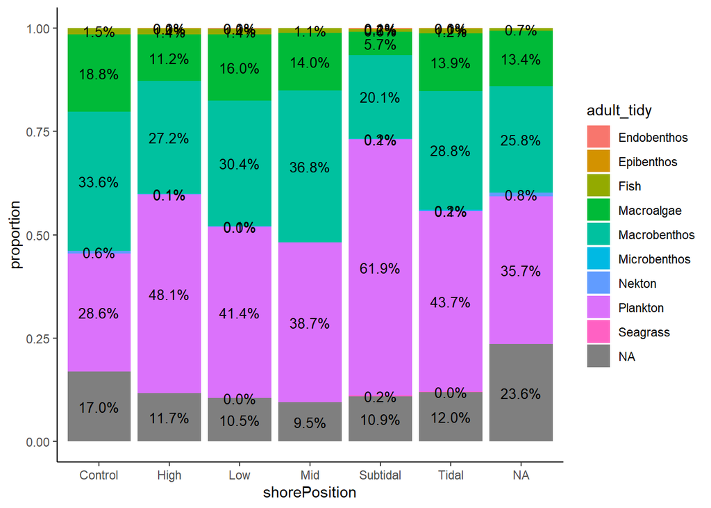

```r
# add pa variable and remove absences
eDNA_long_data_final_pa <- eDNA_long_data_final %>%
  mutate(pa = ifelse(reads > 0, 1, 0))

eDNA_long_data_final_pa <- eDNA_long_data_final_pa %>% filter(pa > 0)

# Summarize the data to count the number of taxa by shorePosition
df_summary <- eDNA_long_data_final_pa %>%
  dplyr::group_by(shorePosition, adult_tidy) %>%
  dplyr::summarise(n_taxa = n(), .groups = 'drop')

# Calculate the total number of taxa in each shorePosition
df_summary <- df_summary %>%
  dplyr::group_by(shorePosition) %>%
  dplyr::mutate(total_taxa = sum(n_taxa)) %>%
  ungroup()

# Calculate the proportion of taxa in each zone within each shorePosition
df_summary <- df_summary %>%
  mutate(proportion = n_taxa / total_taxa)

# Plot
ggplot(df_summary, aes(x = shorePosition, y = proportion, fill = adult_tidy)) +
  geom_bar(stat = "identity") +
  geom_text(aes(label = sprintf("%.1f%%", proportion * 100)),  # Format with 1 decimal place and add "%"
            position = position_stack(vjust = 0.5),  # Center text within bars
            size = 3.5,
            color = "black") +
  theme_classic()
```

## Create phyloseq object

We’ve now got a tidied long data set with lots of meta data. To aid further check and analyses, we can convert our long data into a `phyloseq` object to be used in the `phyloseq` package.

First, we need to document and remove any failed samples.

```r
failed_samples <- c("PHD1-SCH02-03_CO1",
                    "PHD1-SCH02-05_CO1",
                    "PHD1-SCH03-05rep_CO1",
                    "PHD1-SCH04-03_CO1",
                    "PHD1-SCH06-05_18S",
                    "PHD1-SW04-01_CO1",
                    "PHD1-SW06-02_18S",
                    "PHD2-CN02-03_18S",
                    "PHD2-CN05-02_18S",
                    "PHD2-NE01-09_CO1",
                    "PHD2-NE02-03_CO1",
                    "PHD2-NE04-03_18S",
                    "PHD2-NW03-01_CO1")

eDNA_long_data_removefailed <- filter(eDNA_long_data_final, !fullID %in% failed_samples)
```

### Create tax_table()

We need to extract all the taxonomic information from our long data and do some tidying.

```r
taxa <- unique(subset(eDNA_long_data_removefailed, select = c("kingdom",
                                             "phylum",
                                             "class",
                                             "order",
                                             "family",
                                             "genus",
                                             "valid_name",
                                             "scientificname",
                                             "adult", #original fn group,
                                             "adult_simple", # simple fn group
                                             "adult_tidy",# tidy fn group
                                             "valid_AphiaID",
                                             "rank")))

taxa$scientificname <- as.factor(taxa$scientificname)
taxa <- taxa[order(taxa$scientificname),] #order alphabetically to match other ps elements
rownames(taxa) <-taxa$scientificname
taxa <- as.matrix(taxa)
```

Now, save the taxa matrix as a tax_table() object.

```r
phylo_tax <- tax_table(taxa)
```

### Create sample_data()

Similarly, need to extract all the relavent sample information from our long data and do some tidying.

```r
meta <- unique(subset(eDNA_long_data_removefailed, select = c("fieldID",
                                             "projectID",
                                             "eventID",
                                             "type",
                                             "verbatimLocality",
                                             "localityID",
                                             "shorePosition",
                                             "fullID",
                                             "year",
                                             "month",
                                             "day",
                                             "eventTime",
                                             "dna_concentration_CO1",
                                             "dna_concentration_18S",
                                             "negCheckLogical",
                                             "pairedRepLogical",
                                             "country",
                                             "controlCheck",
                                             "sampleType",
                                             "primer",
                                             "date_amplified_CO1",
                                             "date_amplified_18S",
                                             "batch_extraction",
                                             "batch_PCR_CO1",
                                             "plate_col_CO1",
                                             "plate_row_CO1",
                                             "batch_PCR_18S",
                                             "plate_col_18S",
                                             "plate_row_18S",
                                             "date_extraction",
                                             "exposure",
                                             "weather",
                                             "tide",
                                             "lowWater",
                                             "decimalLongitude",
                                             "decimalLatitude",
                                             "eventTime",
                                             "rockpoolarea.cm.2.",
                                             "averageDepth..cm.",
                                             "rockpoolVol.m.3.",
                                             "averagePH",
                                             "averageTemp"
)))

meta <- meta[order(meta$fullID),] #order rows alphabetically
rownames(meta) <-meta$fullID
```

Now, save the sample matrix as a sample_data() object.

```r
phylo_samples <- sample_data(meta)
```

### Create otu_table()

Since our data are currently in long format, we need to recreate the ASV matrix through some data wrangling.

```r
species_reads_long <- eDNA_long_data_removefailed %>%
  select(ASV, reads, fullID) %>%
  mutate(across(c(ASV, fullID), as.factor)) %>%
  distinct()

str(species_reads_long)
```

```
'data.frame':   712877 obs. of  3 variables:
 $ ASV   : Factor w/ 6321 levels "ASV_1","ASV_10",..: 3051 3391 3692 3892 4707 4838 4863 5068 5286 5749 ...
 $ reads : int  0 0 0 0 0 0 0 0 0 0 ...
 $ fullID: Factor w/ 655 levels "PHD1-NCbead_CO1",..: 6 6 6 6 6 6 6 6 6 6 ...
```

```r
which(is.na(species_reads_long)) #check for NAs
```

```
integer(0)
```

Turning our long data into a wide format takes a long time due to the size of the data.

```r
species_reads_wide <- species_reads_long %>%
  pivot_wider(names_from = fullID,
              values_from = reads,
              values_fill = list(reads = 0)) %>%
  as.data.frame()
```

A bit of formatting is needed for joining elements together later on. We can see that we have 6321 ASVs and 655 samples.

```r
#order names alphabetically
species_reads_wide<- species_reads_wide[order(species_reads_wide$ASV),] #order rows alphabetically
species_reads_wide <- species_reads_wide[,order(colnames(species_reads_wide))] #order cols alphabetically

#update row names to ASVs
rownames(species_reads_wide) <- NULL
species_reads_wide <- species_reads_wide %>% column_to_rownames(var="ASV")

dim(species_reads_wide)
```

```
[1] 6321  655
```

We can also repeat the last few steps but group by `scientificname` to get a taxa-level `otu_table` . In my further analyses, taxa-level detection are appropriate and so we will move forward using this `otu_table`.

```r
species_reads_long_taxa <- eDNA_long_data_removefailed %>%
  select(ASV, scientificname, reads, fullID) %>%
  mutate(across(c(ASV, scientificname, fullID), as.factor)) %>%
  distinct()

species_reads_long_taxa_grouped <- species_reads_long_taxa %>%
  group_by(scientificname, fullID) %>%
  summarize(reads = sum(reads, na.rm = TRUE), .groups = "drop")

species_reads_wide_taxa <- species_reads_long_taxa_grouped %>%
  pivot_wider(names_from = fullID,
              values_from = reads,
              values_fill = list(reads = 0)) %>%
  as.data.frame()

#order names alphabetically
species_reads_wide_taxa<- species_reads_wide_taxa[order(species_reads_wide_taxa$scientificname),] #order rows alphabetically
species_reads_wide_taxa <- species_reads_wide_taxa[,order(colnames(species_reads_wide_taxa))] #order cols alphabetically

#update row names to ASVs
rownames(species_reads_wide_taxa) <- NULL
species_reads_wide_taxa <- species_reads_wide_taxa %>% column_to_rownames(var="scientificname")

dim(species_reads_wide_taxa)
```

```
[1] 1780  655
```

Now let’s create our `otu_table` elements - one at a ASV level (in case we need it later on) and one at a taxa-level (which we’ll use for compiling the `phyloseq` object).

```r
phylo_asv <- otu_table(species_reads_wide, taxa_are_rows=TRUE)
phylo_asv_taxa <- otu_table(species_reads_wide_taxa, taxa_are_rows=TRUE)
```

It’s useful to do some checks befor we compile our taxa-level `phyloseq` object to make sure everything aligns correctly. This is why we’ve performed the alphabetical ordering in the above steps.

```r
# Check if colnames in asv object match meta rownames
list1<- colnames(phylo_asv_taxa)
list2 <- rownames(phylo_samples)
which(list1 != list2) #should be NULL
```

```
integer(0)
```

```r
# Check if species names match in asv object and taxa object
list1<- rownames(phylo_asv_taxa)
list2 <- rownames(phylo_tax)
which(list1 != list2) #should be NULL
```

```
integer(0)
```

```r
phylo_eDNA <- phyloseq(phylo_asv_taxa, phylo_tax, phylo_samples)

# Remove taxa wihout occurances from the data
phylo_eDNA <- subset_taxa(phylo_eDNA, taxa_sums(phylo_eDNA) > 0)
```

### Explore `phyloseq` object

Let’s take a look at what the `phyloseq` object looks like.

```r
head(sample_names(phylo_eDNA)) #check sample names
```

```
[1] "PHD1-NCbead_CO1"   "PHD1-NCrep_18S"    "PHD1-NCrep_CO1"
[4] "PHD1-PCrep_18S"    "PHD1-PCrep_CO1"    "PHD1-SCH01-01_18S"
```

```r
head(rank_names(phylo_eDNA)) #check taxonomic information
```

```
[1] "kingdom" "phylum"  "class"   "order"   "family"  "genus"
```

```r
head(sample_variables(phylo_eDNA)) #check meta data
```

```
[1] "fieldID"          "projectID"        "eventID"          "type"
[5] "verbatimLocality" "localityID"
```

```r
phylo_eDNA
```

```
phyloseq-class experiment-level object
otu_table()   OTU Table:         [ 1725 taxa and 655 samples ]
sample_data() Sample Data:       [ 655 samples by 42 sample variables ]
tax_table()   Taxonomy Table:    [ 1725 taxa by 13 taxonomic ranks ]
```

```r
microbiome::summarize_phyloseq(phylo_eDNA) #full summary
```

```
[[1]]
[1] "1] Min. number of reads = 0"

[[2]]
[1] "2] Max. number of reads = 352001"

[[3]]
[1] "3] Total number of reads = 25709925"

[[4]]
[1] "4] Average number of reads = 39251.7938931298"

[[5]]
[1] "5] Median number of reads = 24570"

[[6]]
[1] "7] Sparsity = 0.9644128775307"

[[7]]
[1] "6] Any OTU sum to 1 or less? NO"

[[8]]
[1] "8] Number of singletons = 0"

[[9]]
[1] "9] Percent of OTUs that are singletons \n        (i.e. exactly one read detected across all samples)0"

[[10]]
[1] "10] Number of sample variables are: 42"

[[11]]
 [1] "fieldID"               "projectID"             "eventID"
 [4] "type"                  "verbatimLocality"      "localityID"
 [7] "shorePosition"         "fullID"                "year"
[10] "month"                 "day"                   "eventTime"
[13] "dna_concentration_CO1" "dna_concentration_18S" "negCheckLogical"
[16] "pairedRepLogical"      "country"               "controlCheck"
[19] "sampleType"            "primer"                "date_amplified_CO1"
[22] "date_amplified_18S"    "batch_extraction"      "batch_PCR_CO1"
[25] "plate_col_CO1"         "plate_row_CO1"         "batch_PCR_18S"
[28] "plate_col_18S"         "plate_row_18S"         "date_extraction"
[31] "exposure"              "weather"               "tide"
[34] "lowWater"              "decimalLongitude"      "decimalLatitude"
[37] "eventTime.1"           "rockpoolarea.cm.2."    "averageDepth..cm."
[40] "rockpoolVol.m.3."      "averagePH"             "averageTemp"
```

```r
table(meta(phylo_eDNA)$controlCheck, useNA = "always") #control type
```

```
 control positive   sample     <NA>
     101       30      524        0
```

```r
# save under different name for quality control checks later
phylo_eDNA_predecontam <- phylo_eDNA
```

## Decontamination

### Visualizing contaminants

Let’s produce some figures to visualize potential contaminates present in our negative controls.

We need to subset the negative control samples first.

```r
phylo_neg_controls = subset_samples(phylo_eDNA, sampleType == "field-control" | sampleType == "lab-negative-control")

# Clean out taxa/ASV columns that are no longer present.
phylo_neg_controls <- prune_taxa(taxa_sums(phylo_neg_controls) > 0, phylo_neg_controls)
```

Let’s check the distribution of taxa in the negative controls.

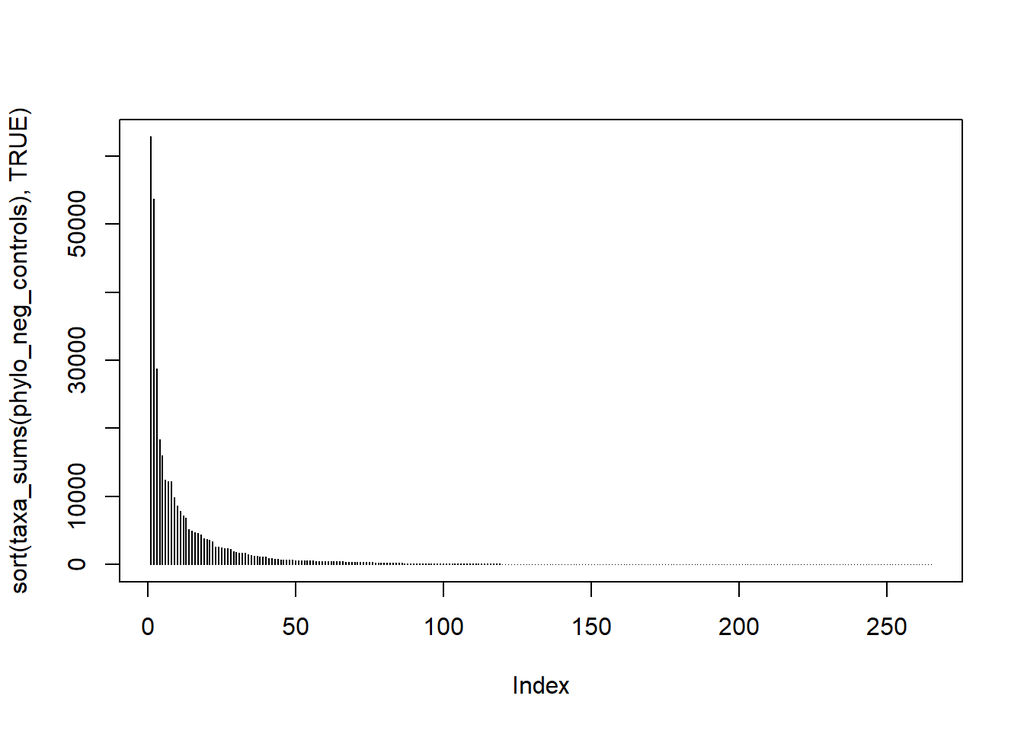

```r
plot(sort(taxa_sums(phylo_neg_controls), TRUE), type="h")
```

It might be useful to view contaminates by primer. Let’s look at 18S first.

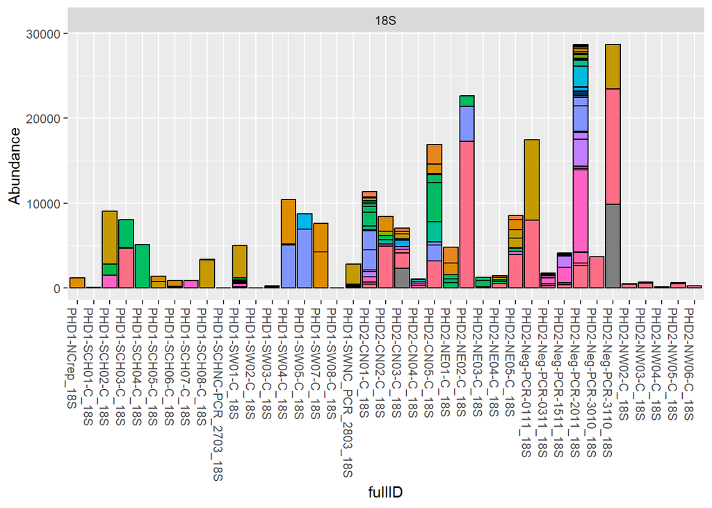

```r
phylo_neg_18S <- subset_samples(phylo_neg_controls, primer == "18S")

(contam_18S_plot<- plot_bar(phylo_neg_18S, "fullID", fill = "phylum") +
  facet_wrap(.~ primer)+
  theme(legend.position = 'none'))
```

And now for CO1.

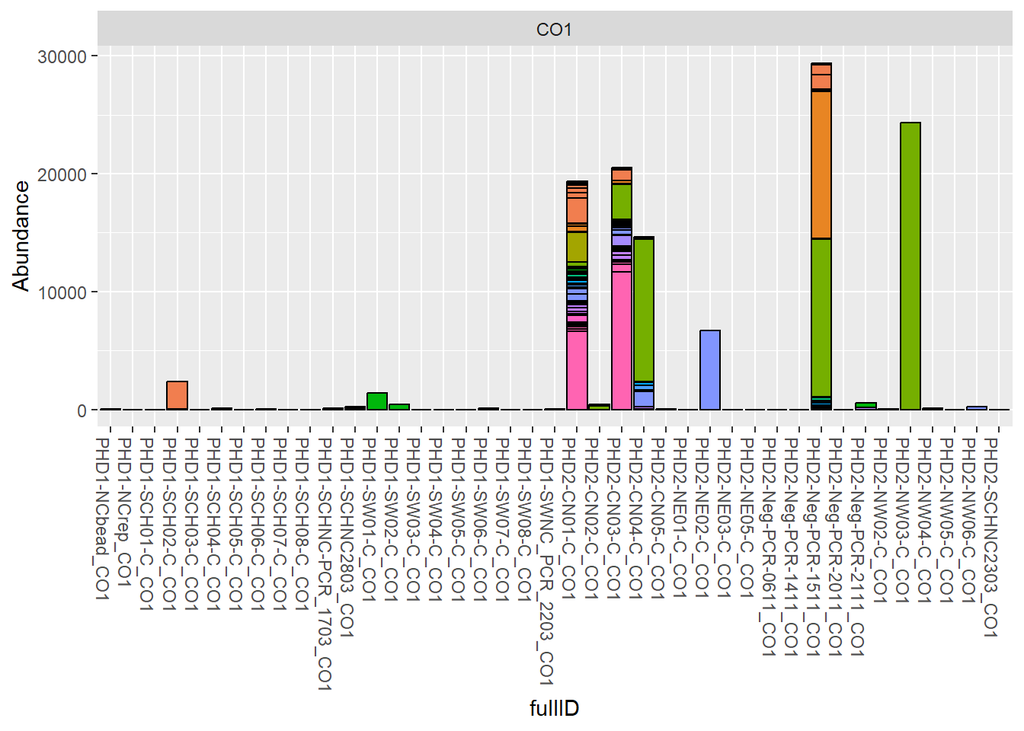

```r
phylo_neg_CO1 <- subset_samples(phylo_neg_controls, primer == "CO1")

(contam_CO1_plot<- plot_bar(phylo_neg_CO1, "fullID", fill = "phylum") +
  facet_wrap(.~ primer) +
  theme(legend.position = 'none'))
```

[figure not shown]

```r
controls_shared_taxa = filter_taxa(phylo_neg_controls,
                                   function(x) sum(x >= 1) == (5), TRUE)
plot_bar(controls_shared_taxa, "fullID", fill = "scientificname")
```

We can also visualize our original PCR plates (if we have variables in our metadata which state the position of samples on the plates).

First, calculate overall read depth across samples and this to our sample data.

```r
#Calculate read depths
sample_depths <- microbiome::readcount(phylo_eDNA)
sample_depths_df <- as.data.frame(sample_depths)
sample_depths_df <- tibble::rownames_to_column(sample_depths_df, "fullID")
head(sample_depths_df)
```

```
             fullID sample_depths
1   PHD1-NCbead_CO1            48
2    PHD1-NCrep_18S          1205
3    PHD1-NCrep_CO1             0
4    PHD1-PCrep_18S             0
5    PHD1-PCrep_CO1             0
6 PHD1-SCH01-01_18S         43943
```

```r
# add depths to sample data
sample_data <- sample_data(phylo_eDNA)
sample_data[,"depth"] <- sample_depths
```

Let’s look at CO1 first.

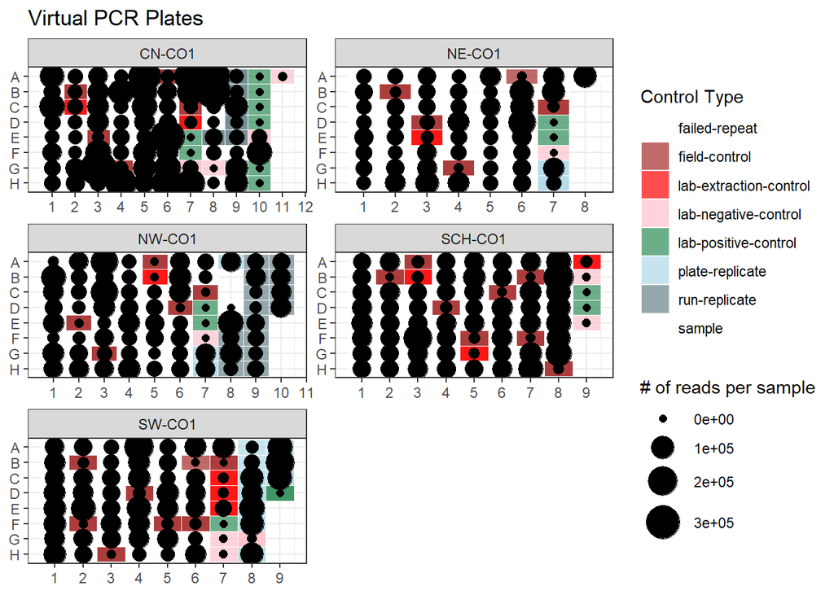

```r
# Filter out NA values
sample_data_CO1 <- sample_data[!is.na(sample_data$plate_row_CO1), ]

# Reorder levels of plate_row_CO1
sample_data_CO1$plate_row_CO1 <- factor(sample_data_CO1$plate_row_CO1,
                                        levels = rev(LETTERS[1:8]))

# Relabel PCR plates
sample_data_CO1$batch_PCR_CO1 <- recode(sample_data_CO1$batch_PCR_CO1,
                                    "1" = "SW-CO1",
                                    "2" = "SCH-CO1",
                                    "3" = "SW-18S",
                                    "4" = "SCH-18S",
                                    "5" = "NW-18S",
                                    "6" = "NE-18S",
                                    "7" = "CN-18S",
                                    "8" = "NW-CO1",
                                    "9" = "NE-CO1",
                                    "10" = "CN-CO1")

# Plot with facet_wrap and circles representing concentrations - CO1 first
pcr_plate_CO1 <- ggplot(sample_data_CO1, aes(x = plate_col_CO1, y = plate_row_CO1)) +
  geom_tile(aes(fill = sampleType), color = "white", alpha = 0.7) +
  geom_point(aes(size = depth), shape = 21, fill = "black", color = "black") + # Fill circles with black
  scale_fill_manual(values = c("field-control" = "brown",
                               "lab-extraction-control" = "red",
                               "lab-negative-control" = "pink",
                               "lab-positive-control" = "seagreen",
                               "sample" ="white",
                               "plate-replicate" = "lightblue",
                               "failed-repeat" = "white",
                               "run-replicate" = "lightblue4")) +
  scale_size_continuous(range = c(2, 10)) +  # Adjust circle sizes as needed
  labs(title = "Virtual PCR Plates",
       x = NULL,
       y = NULL,
       fill = "Control Type",
       size = "# of reads per sample") +
  theme_bw() +
  theme(legend.position = "right") + # Adjust legend position if needed
  facet_wrap(~ batch_PCR_CO1, ncol = 2, scales = "free") + # Facet by plate variable, 2 plates per row
  scale_x_continuous(breaks = 1:12)  # Discrete x-axis from 1 to 12

pcr_plate_CO1
```

And now for 18S.

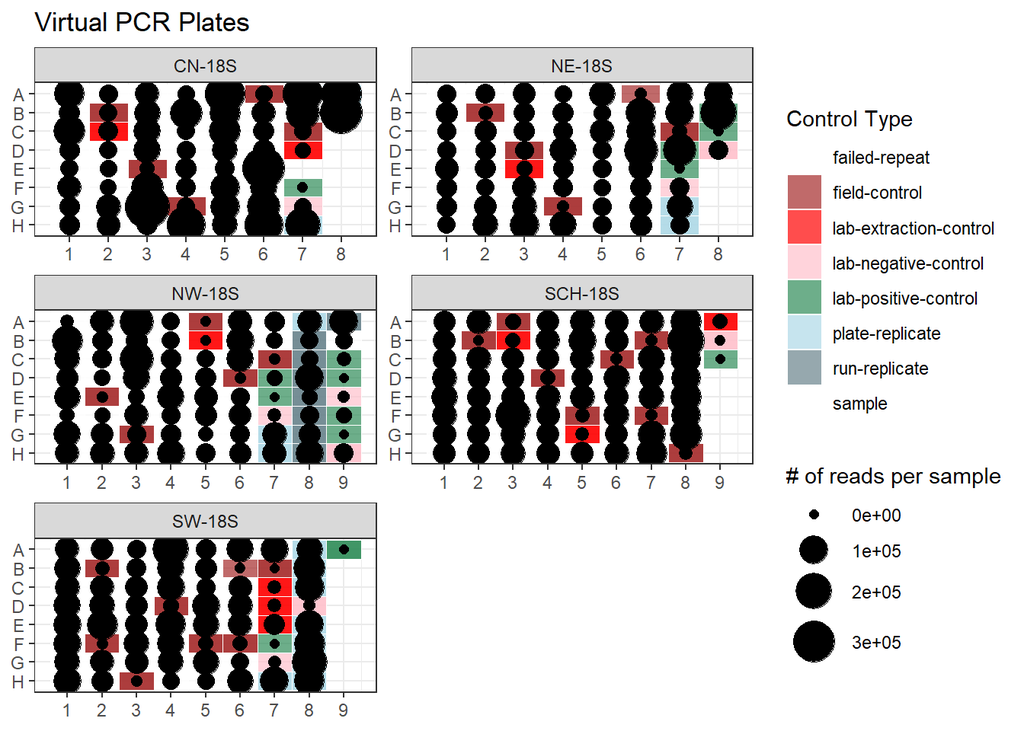

```r
# Filter out NA values
sample_data_18S <- sample_data[!is.na(sample_data$plate_row_18S), ]

# Reorder levels of plate_row_18S
sample_data_18S$plate_row_18S <- factor(sample_data_18S$plate_row_18S, levels = rev(LETTERS[1:8]))

# Relabel PCR plates
sample_data_18S$batch_PCR_18S <- recode(sample_data_18S$batch_PCR_18S,
                                    "1" = "SW-CO1",
                                    "2" = "SCH-CO1",
                                    "3" = "SW-18S",
                                    "4" = "SCH-18S",
                                    "5" = "NW-18S",
                                    "6" = "NE-18S",
                                    "7" = "CN-18S",
                                    "8" = "NW-CO1",
                                    "9" = "NE-CO1",
                                    "10" = "CN-CO1")

# Plot with facet_wrap and circles representing concentrations - 18S first
pcr_plate_18S <- ggplot(sample_data_18S, aes(x = plate_col_18S, y = plate_row_18S)) +
  geom_tile(aes(fill = sampleType), color = "white", alpha = 0.7) +
  geom_point(aes(size = depth), shape = 21, fill = "black", color = "black") + # Fill circles with black
  scale_fill_manual(values = c("field-control" = "brown",
                               "lab-extraction-control" = "red",
                               "lab-negative-control" = "pink",
                               "lab-positive-control" = "seagreen",
                               "sample" ="white",
                               "plate-replicate" = "lightblue",
                               "failed-repeat" = "white",
                               "run-replicate" = "lightblue4")) +
  scale_size_continuous(range = c(2, 10)) +  # Adjust circle sizes as needed
  labs(title = "Virtual PCR Plates",
       x = NULL,
       y = NULL,
       fill = "Control Type",
       size = "# of reads per sample") +
  theme_bw() +
  theme(legend.position = "right") + # Adjust legend position if needed
  facet_wrap(~ batch_PCR_18S, ncol = 2, scales = "free") + # Facet by plate variable, 2 plates per row
  scale_x_continuous(breaks = 1:12)  # Discrete x-axis from 1 to 12

pcr_plate_18S
```

### Removing contaminants

We can see from our plots we have some contamination. We deal with this next.

There are multiple ways to deal with contamination. Here, we take the approach that if the abundance of a taxa in control sample is larger than abundance in main sample, it will be treated as contaminant and be removed.

We’ll remove taxa in stages: from sites (using the field controls), extraction batch (using the extraction controls) then PCR batch (using the PCR controls). This prevents unnecessary blanket removal across the whole data set.

Let’s set-up the site level decontamination function called `remove_field_control_taxa_abund` first.

```r
remove_field_control_taxa_abund <- function(phylo_object) {

  # Extract sample data
  sample_data <- sample_data(phylo_object)

  # Get unique localityIDs
  unique_localityIDs <- unique(sample_data$localityID[!is.na(sample_data$localityID)])

  # Check if unique_localityIDs is empty
  if (length(unique_localityIDs) == 0) {
    stop("No localityIDs found in sample data.")
  }

  # Initialize variable to count OTUs removed
  otus_removed <- data.frame(localityID = character(), OTU = character(), reads_removed = integer(), stringsAsFactors = FALSE)

  # Initialize filtered OTU table
  otu_table_filtered <- otu_table(phylo_object)

  # Check if the OTU table is empty
  if (dim(otu_table_filtered)[1] == 0 || dim(otu_table_filtered)[2] == 0) {
    stop("OTU abundance data is empty.")
  }

  print("Original dimensions of otu_table_filtered:")
  print(dim(otu_table_filtered))

  # Initialize list to store removed OTUs for each sample
  otus_removed_reads <- data.frame()
  otus_removed_reads_total <- data.frame()

  # Loop through each localityID
  for (locality in unique_localityIDs) {

    # Get field control sample fullIDs for the current locality
    field_control_samples <- unique(sample_data$fullID[sample_data$localityID == locality & grepl("-C_CO1$|-C_18S$", sample_data$fullID)])

    # If there are more than 2 field control samples for the current locality, print a message and skip
    if (length(field_control_samples) > 2) {
      cat("More than 1 field control samples found for site:", locality, "\n")
      next
    }

    # If there are no field control samples for the current locality, print a message and skip
    if (length(field_control_samples) < 2) {
      cat("No field control samples found for site:", locality, "\n")
      next
    }

    # Get indices of field control and samples
    control_indices <- which(sample_data$fullID %in% field_control_samples)
    sample_indices <- which(sample_data$localityID == locality & !sample_data$fullID %in% field_control_samples)

    # If no control indices found
    if (length(control_indices) == 0) {
      cat("No control indices found for site:", locality, "\n")
      next
    }

    # If no sample indices found
    if (length(sample_indices) == 0) {
      cat("No sample indices found for site:", locality, "\n")
      next
    }

    # Calculate mean abundance of each OTU in the control and samples
    control_abundance <- rowMeans(otu_table_filtered[, control_indices])
    sample_abundance <- rowMeans(otu_table_filtered[, sample_indices])

    # Identify potential contaminants based on higher abundance in control than samples
    contaminants <- rownames(otu_table_filtered)[control_abundance > sample_abundance]

    if (length(contaminants) > 0) {
      cat(length(contaminants), "contaminant taxa found for site:", locality, "\n")
    } else {
      cat("No contaminants found for site:", locality, "\n")
      next
    }

    #Get original number of reads in samples for taxa with above minReads reads in controls
    #bind the previous output
    if (length(otus_removed_reads) > 0) {
      otus_removed_reads_total <- rbind(otus_removed_reads, otus_removed_reads_total)
    }

    #get reads
    otus_removed_reads <- otu_table_filtered[contaminants,  sample_indices] %>% reshape2::melt()
    colnames(otus_removed_reads) <- c("taxa", "fullID", "reads_removed")

    # Set read count of OTUs in real samples to zero if reads in field control samples exceed 100
    otu_table_filtered[contaminants, sample_indices] <- 0

  }

  # Print OTUs removed
  cat("Reads removed:", sum(otus_removed_reads_total$reads_removed),"; Samples filtered:", length(unique(otus_removed_reads_total$fullID)), "\n")

  # Print new dimensions
  print("New dimensions of otu_table_filtered:")
  print(dim(otu_table_filtered))

  # Remove controls from the dataset
  control_samples<- sample_data$fullID[grepl("-C_CO1$|-C_18S$", sample_data$fullID)] # Build list of names of control samples
  otu_table_filtered <- otu_table_filtered[, -which(colnames(otu_table_filtered) %in% control_samples)] # Remove control samples from otu_table
  sample_data_filtered <- sample_data[!sample_data$fullID %in% control_samples, ] # Remove control samples from sample_data

  # Return the modified phyloseq object
  modified_phylo <- phyloseq(otu_table_filtered, tax_table(phylo_object), sample_data_filtered)

  # Remove taxa with zero reads removed in otus_removed_reads_total
  otus_removed_reads_total <- otus_removed_reads_total %>% subset(otus_removed_reads_total$reads_removed != 0)

  # Return the modified phyloseq object and otus_removed dataframe
  return(list(modified_phylo, otus_removed_reads_total))
}
```

Next, the function for extraction level decontamination called `remove_extract_control_taxa_abund`.

```r
#| label: remove-extract-contam-function

remove_extract_control_taxa_abund <- function(phylo_object) {

  # Extract sample data
  sample_data <- sample_data(phylo_object)

  # Get unique batches
  unique_batches <- unique(sample_data$batch_extraction[!is.na(sample_data$batch_extraction)])

  # Check if unique_localityIDs is empty
  if (length(unique_batches) == 0) {
    stop("No DNA extraction batches found in sample data.")
  }

  # Initialize variable to count OTUs removed
  otus_removed <- data.frame(batch = character(), OTU = character(), reads_removed = integer(), stringsAsFactors = FALSE)

  # Initialize filtered OTU table
  otu_table_filtered <- otu_table(phylo_object)

  # Check if the OTU table is empty
  if (dim(otu_table_filtered)[1] == 0 || dim(otu_table_filtered)[2] == 0) {
    stop("OTU abundance data is empty.")
  }

  print("Original dimensions of otu_table_filtered:")
  print(dim(otu_table_filtered))

  # Initialize list to store removed OTUs for each sample
  otus_removed_reads <- data.frame()
  otus_removed_reads_total <- data.frame()

  # Loop through each localityID
  for (batch in unique_batches) {

    # Get extract control sample for the current batch
    dna_extract_control_samples <- unique(sub("_[^_]*$", "", sample_data$fullID[sample_data$sampleType == "lab-extraction-control"
                                                                                & sample_data$batch_extraction == batch]))

    # If there are more than 2 field control samples for the current locality, print a message and skip
    if (length(dna_extract_control_samples) > 2) {
      cat("More than 1 DNA extract control sample found in batch:", batch, "\n")
      next
    }

    # If there are no field control samples for the current locality, print a message and skip
    if (length(dna_extract_control_samples) < 1) {
      cat("No DNA extract control samples found in batch:", batch, "\n")
      next
    }

    # Get indices of dna extract control and samples
    control_indices <- which(sample_data$fieldID %in% dna_extract_control_samples)
    sample_indices <- which(sample_data$batch_extraction == batch & !sample_data$fullID %in% dna_extract_control_samples)

    # If no control indices found
    if (length(control_indices) == 0) {
      cat("No control indices found for batch:", batch, "\n")
      next
    }

    # If no sample indices found
    if (length(sample_indices) == 0) {
      cat("No sample indices found for batch:", batch, "\n")
      next
    }

    # Calculate mean abundance of each OTU in the control and samples
    control_abundance <- rowMeans(otu_table_filtered[, control_indices])
    sample_abundance <- rowMeans(otu_table_filtered[, sample_indices])

    # Identify potential contaminants based on higher abundance in control than samples
    contaminants <- rownames(otu_table_filtered)[control_abundance > sample_abundance]

    if (length(contaminants) > 0) {
      cat(length(contaminants), "contaminant taxa found for site:", batch, "\n")
    } else {
      cat("No contaminants found for site:", batch, "\n")
      next
    }

    #Get original number of reads in samples for taxa with above minReads reads in controls
    #bind the previous output
    if (length(otus_removed_reads) > 0) {
      otus_removed_reads_total <- rbind(otus_removed_reads, otus_removed_reads_total)
    }

    #get reads
    otus_removed_reads <- otu_table_filtered[contaminants,  sample_indices] %>% reshape2::melt()
    colnames(otus_removed_reads) <- c("taxa", "fullID", "reads_removed")

    # Set read count of OTUs in real samples to zero if reads in field control samples exceed 100
    otu_table_filtered[contaminants, sample_indices] <- 0

    # Remove the control samples from the phylo object
    otu_table_filtered <- otu_table_filtered[-control_indices]

  }

  # Print OTUs removed
  cat("Reads removed:", sum(otus_removed_reads_total$reads_removed),"; Samples filtered:", length(unique(otus_removed_reads_total$fullID)), "\n")

  # Remove controls from the dataset
  control_samples <- unique(sub("_[^_]*$", "", sample_data$fullID[sample_data$sampleType == "lab-extraction-control"])) # Build list of names of control samples
  control_samples <- c(paste0(control_samples, "_CO1"), paste0(control_samples, "_18S"))  # Create a list of control samples by appending "_CO1" and "_18S" to each ID
  otu_table_filtered <- otu_table_filtered[, -which(colnames(otu_table_filtered) %in% control_samples)] # Remove control samples from otu_table
  sample_data_filtered <- sample_data[!sample_data$fullID %in% control_samples, ] # Remove control samples from sample_data

  # Print new dimensions
  print("New dimensions of otu_table_filtered:")
  print(dim(otu_table_filtered))

  # Return the modified phyloseq object
  modified_phylo <- phyloseq(otu_table_filtered, tax_table(phylo_object), sample_data_filtered)

  # Remove taxa with zero reads removed in otus_removed_reads_total
  otus_removed_reads_total <- otus_removed_reads_total %>% subset(otus_removed_reads_total$reads_removed != 0)

  # Return the modified phyloseq object and otus_removed data frame
  return(list(modified_phylo, otus_removed_reads_total))
}
```

And finally, the function for PCR level decontamination. We have to do this by marker, considering the PCRs are different for each.

The 18S function is called `remove_PCR_control_taxa_18S_abund`.

```r
remove_PCR_control_taxa_18S_abund <- function(phylo_object) {

  # Extract sample data
  sample_data <- sample_data(phylo_object)

  # Get unique batches
  unique_batches <- unique(sample_data$batch_PCR_18S[!is.na(sample_data$batch_PCR_18S)])

  # Check if unique_localityIDs is empty
  if (length(unique_batches) == 0) {
    stop("No PCR (18S) batches found in sample data.")
  }

  # Initialize variable to count OTUs removed
  otus_removed <- data.frame(batch = character(), OTU = character(), reads_removed = integer(), stringsAsFactors = FALSE)

  # Initialize filtered OTU table
  otu_table_filtered <- otu_table(phylo_object)

  # Check if the OTU table is empty
  if (dim(otu_table_filtered)[1] == 0 || dim(otu_table_filtered)[2] == 0) {
    stop("OTU abundance data is empty.")
  }

  print("Original dimensions of otu_table_filtered:")
  print(dim(otu_table_filtered))

  # Initialize list to store removed OTUs for each sample
  otus_removed_reads <- data.frame()
  otus_removed_reads_total <- data.frame()

  # Loop through each batch_PCR_18S
  for (batch in unique_batches) {

    # Get extract control samples for the current batch
    pcr_18S_control_samples <- unique(sub("_[^_]*$", "", sample_data$fullID[sample_data$sampleType == "lab-negative-control"
                                                                            & sample_data$batch_PCR_18S == batch]))
    pcr_18S_control_samples <- na.omit(pcr_18S_control_samples)

    # If there are no PCR 18S control samples for the current batch, print a message and skip
    if (length(pcr_18S_control_samples) < 1) {
      cat("No PCR (18S) control samples found in batch:", batch, "\n")
      next
    }

    # Get indices of PCR (18S) control and samples
    control_indices <- which(sample_data$fieldID %in% pcr_18S_control_samples)
    sample_indices <- which(sample_data$batch_PCR_18S == batch & !sample_data$fullID %in% pcr_18S_control_samples)

    # If no control indices found
    if (length(control_indices) == 0) {
      cat("No control indices found for batch:", batch, "\n")
      next
    }

    # If no sample indices found
    if (length(sample_indices) == 0) {
      cat("No sample indices found for batch:", batch, "\n")
      next
    }

    # If there are more than PCR 18S control samples for the current locality, loop through the controls
    if (length(pcr_18S_control_samples) > 2) {
      cat("More than 1 PCR (18S) control sample found in batch", batch, ". Now printing individual controls:", "\n")

      for (control in control_indices) {

        # Calculate mean abundance of each OTU in the control and samples
        control_abundance <- rowMeans(otu_table_filtered[, control])
        sample_abundance <- rowMeans(otu_table_filtered[, sample_indices])

        #check there are OTUs with reads above minReads in the field control samples
        control_sum_above_minReads <- rowSums(otu_table_filtered[, control]) > 100

        if (any(control_sum_above_minReads)) {
          contaminants <- rownames(otu_table_filtered[control_abundance > sample_abundance])
          cat("Batch", batch, ":", sum(control_sum_above_minReads == T), "contaminant taxa found for control indices", control, "\n")
        } else {
          cat("Batch", batch, ": No contaminants found for control indices", control, "\n")
          next
        }

        #Get original number of reads in samples for taxa with above minReads reads in controls
        #bind the previous output
        if (length(otus_removed_reads) > 0) {
          otus_removed_reads_total <- rbind(otus_removed_reads, otus_removed_reads_total)
        }

        #get reads
        otus_removed_reads <- otu_table_filtered[contaminants,  sample_indices] %>% reshape2::melt()
        colnames(otus_removed_reads) <- c("taxa", "fullID", "reads_removed")

        # Set read count of OTUs in real samples to zero if reads in field control samples exceed 100
        otu_table_filtered[contaminants, sample_indices] <- 0

        # Remove the control samples from the phylo object
        otu_table_filtered <- otu_table_filtered[-control]
      }
    } else {

      #check there are OTUs with reads above minReads in the field control samples
      control_sum_above_minReads <- rowSums(otu_table_filtered[, control_indices]) > minReads

      if (any(control_sum_above_minReads)) {
        contaminants <- rownames(otu_table_filtered[rowSums(otu_table_filtered[, control_indices]) > minReads])
        cat(sum(control_sum_above_minReads == T), "contaminant taxa found for batch", batch, "\n")
      } else {
        cat("No contaminants found for batch", batch, "\n")
        next
      }

      #Get original number of reads in samples for taxa with above minReads reads in controls
      #bind the previous output
      if (length(otus_removed_reads) > 0) {
        otus_removed_reads_total <- rbind(otus_removed_reads, otus_removed_reads_total)
      }

      #get reads
      otus_removed_reads <- otu_table_filtered[contaminants,  sample_indices] %>% reshape2::melt()
      colnames(otus_removed_reads) <- c("taxa", "fullID", "reads_removed")

      # Set read count of OTUs in real samples to zero if reads in field control samples exceed 100
      otu_table_filtered[contaminants, sample_indices] <- 0

      # Remove the control samples from the phylo object
      otu_table_filtered <- otu_table_filtered[-control_indices]
    }
  }

  # Print OTUs removed
  cat("Reads removed:", sum(otus_removed_reads_total$reads_removed),"; Samples filtered:", length(unique(otus_removed_reads_total$fullID)), "\n")

  # Get list of control samples
  control_samples <- unique(sub("_[^_]*$", "", sample_data$fullID[sample_data$sampleType == "lab-negative-control"])) # Build list of names of control samples
  control_samples <- c(paste0(control_samples, "_18S")) # Create a list of control samples by appending "_CO1" to each ID

  # Check control samples to filtered otu table (will be more in the list than reality because some aren't _CO1)
  print(control_samples)
  print(which(control_samples %in% colnames(otu_table_filtered)))

  # Remove control samples from otu and sample table
  otu_table_filtered <- otu_table_filtered[, -which(colnames(otu_table_filtered) %in% control_samples)] # Remove control samples from otu_table
  sample_data_filtered <- sample_data[!sample_data$fullID %in% control_samples, ] # Remove control samples from sample_data

  # Print new dimensions
  print("New dimensions of otu_table_filtered:")
  print(dim(otu_table_filtered))

  # Return the modified phyloseq object
  modified_phylo <- phyloseq(otu_table_filtered, tax_table(phylo_object), sample_data_filtered)

  # Remove taxa with zero reads removed in otus_removed_reads_total
  otus_removed_reads_total <- otus_removed_reads_total %>% subset(otus_removed_reads_total$reads_removed != 0)

  # Return the modified phyloseq object and otus_removed dataframe
  return(list(modified_phylo, otus_removed_reads_total))
}
```

And the CO1 function is called `remove_PCR_control_taxa_CO1_abund`.

```r
### PCR negative decontamination (CO1)
remove_PCR_control_taxa_CO1_abund <- function(phylo_object) {

  # Extract sample data
  sample_data <- sample_data(phylo_object)

  # Get unique batches
  unique_batches <- unique(sample_data$batch_PCR_CO1[!is.na(sample_data$batch_PCR_CO1)])

  # Check if unique_localityIDs is empty
  if (length(unique_batches) == 0) {
    stop("No PCR (CO1) batches found in sample data.")
  }

  # Initialize variable to count OTUs removed
  otus_removed <- data.frame(batch = character(), OTU = character(), reads_removed = integer(), stringsAsFactors = FALSE)

  # Initialize filtered OTU table
  otu_table_filtered <- otu_table(phylo_object)

  # Check if the OTU table is empty
  if (dim(otu_table_filtered)[1] == 0 || dim(otu_table_filtered)[2] == 0) {
    stop("OTU abundance data is empty.")
  }

  print("Original dimensions of otu_table_filtered:")
  print(dim(otu_table_filtered))

  # Initialize list to store removed OTUs for each sample
  otus_removed_reads <- data.frame()
  otus_removed_reads_total <- data.frame()

  # Loop through each batch_PCR_CO1
  for (batch in unique_batches) {

    # Get extract control samples for the current batch
    pcr_CO1_control_samples <- unique(sub("_[^_]*$", "", sample_data$fullID[sample_data$sampleType == "lab-negative-control"
                                                                            & sample_data$batch_PCR_CO1 == batch]))
    pcr_CO1_control_samples <- na.omit(pcr_CO1_control_samples)

    # If there are no PCR CO1 control samples for the current batch, print a message and skip
    if (length(pcr_CO1_control_samples) < 1) {
      cat("No PCR (CO1) control samples found in batch:", batch, "\n")
      next
    }

    # Get indices of PCR (CO1) control and samples
    control_indices <- which(sample_data$fieldID %in% pcr_CO1_control_samples)
    sample_indices <- which(sample_data$batch_PCR_CO1 == batch & !sample_data$fullID %in% pcr_CO1_control_samples)

    # If no control indices found
    if (length(control_indices) == 0) {
      cat("No control indices found for batch:", batch, "\n")
      next
    }

    # If no sample indices found
    if (length(sample_indices) == 0) {
      cat("No sample indices found for batch:", batch, "\n")
      next
    }

    # If there are more than PCR CO1 control samples for the current locality, loop through the controls
    if (length(pcr_CO1_control_samples) > 2) {
      cat("More than 1 PCR (CO1) control sample found in batch", batch, ". Now printing individual controls:", "\n")

      for (control in control_indices) {

        # Calculate mean abundance of each OTU in the control and samples
        control_abundance <- rowMeans(otu_table_filtered[, control])
        sample_abundance <- rowMeans(otu_table_filtered[, sample_indices])

        #check there are OTUs with reads above minReads in the field control samples
        control_sum_above_minReads <- rowSums(otu_table_filtered[, control]) > 100

        if (any(control_sum_above_minReads)) {
          if (any(control_abundance > sample_abundance)) {
            contaminants <- rownames(otu_table_filtered[control_abundance > sample_abundance])
            cat("Batch", batch, ":", sum(control_sum_above_minReads == TRUE), "contaminant taxa found for control indices", control, "\n")
          } else {
            cat("Batch", batch, ": Control abundance is not greater than sample abundance. OTU table would be empty.\n")
            next
          }
        } else {
          cat("Batch", batch, ": No contaminants found for control indices", control, "\n")
          next
        }

        #Get original number of reads in samples for taxa with above minReads reads in controls
        #bind the previous output
        if (length(otus_removed_reads) > 0) {
          otus_removed_reads_total <- rbind(otus_removed_reads, otus_removed_reads_total)
        }

        #get reads
        otus_removed_reads <- otu_table_filtered[contaminants,  sample_indices] %>% reshape2::melt()
        colnames(otus_removed_reads) <- c("taxa", "fullID", "reads_removed")

        # Set read count of OTUs in real samples to zero if reads in field control samples exceed 100
        otu_table_filtered[contaminants, sample_indices] <- 0

        # Remove the control samples from the phylo object
        otu_table_filtered <- otu_table_filtered[-control]
      }
    } else {

      #check there are OTUs with reads above minReads in the field control samples
      control_sum_above_minReads <- rowSums(otu_table_filtered[, control_indices]) > minReads

      if (any(control_sum_above_minReads)) {
        contaminants <- rownames(otu_table_filtered[rowSums(otu_table_filtered[, control_indices]) > minReads])
        cat(sum(control_sum_above_minReads == T), "contaminant taxa found for batch", batch, "\n")
      } else {
        cat("No contaminants found for batch", batch, "\n")
        next
      }

      #Get original number of reads in samples for taxa with above minReads reads in controls
      #bind the previous output
      if (length(otus_removed_reads) > 0) {
        otus_removed_reads_total <- rbind(otus_removed_reads, otus_removed_reads_total)
      }

      #get reads
      otus_removed_reads <- otu_table_filtered[contaminants,  sample_indices] %>% reshape2::melt()
      colnames(otus_removed_reads) <- c("taxa", "fullID", "reads_removed")

      # Set read count of OTUs in real samples to zero if reads in field control samples exceed 100
      otu_table_filtered[contaminants, sample_indices] <- 0

      # Remove the control samples from the phylo object
      otu_table_filtered <- otu_table_filtered[-control_indices]
    }
  }

  # Print OTUs removed
  cat("Reads removed:", sum(otus_removed_reads_total$reads_removed),"; Samples filtered:", length(unique(otus_removed_reads_total$fullID)), "\n")

  # Get list of control samples
  control_samples <- unique(sub("_[^_]*$", "", sample_data$fullID[sample_data$sampleType == "lab-negative-control"])) # Build list of names of control samples
  control_samples <- c(paste0(control_samples, "_CO1")) # Create a list of control samples by appending "_CO1" to each ID

  # Check control samples to filtered otu table (will be more in the list than reality because some aren't _CO1)
  print(control_samples)
  print(which(control_samples %in% colnames(otu_table_filtered)))

  # Remove control samples from otu and sample table
  otu_table_filtered <- otu_table_filtered[, -which(colnames(otu_table_filtered) %in% control_samples)] # Remove control samples from otu_table
  sample_data_filtered <- sample_data[!sample_data$fullID %in% control_samples, ] # Remove control samples from sample_data

  # Print new dimensions
  print("New dimensions of otu_table_filtered:")
  print(dim(otu_table_filtered))

  # Return the modified phyloseq object
  modified_phylo <- phyloseq(otu_table_filtered, tax_table(phylo_object), sample_data_filtered)

  # Remove taxa with zero reads removed in otus_removed_reads_total
  otus_removed_reads_total <- otus_removed_reads_total %>% subset(otus_removed_reads_total$reads_removed != 0)

  # Return the modified phyloseq object and otus_removed data frame
  return(list(modified_phylo, otus_removed_reads_total))
}
```

Time to run the decontamination functions one after the other, using the output of the first as the input for the last.

```r
minReads = 100 #to identify a contaminant

#Call remove_field_control_taxa_abund() function (site)
result_field_abun <- remove_field_control_taxa_abund(phylo_eDNA)
```

```
[1] "Original dimensions of otu_table_filtered:"
[1] 1725  655
1 contaminant taxa found for site: SCH01
4 contaminant taxa found for site: SCH02
1 contaminant taxa found for site: SCH03
No contaminants found for site: SCH04
2 contaminant taxa found for site: SCH05
3 contaminant taxa found for site: SCH06
1 contaminant taxa found for site: SCH07
1 contaminant taxa found for site: SCH08
2 contaminant taxa found for site: SW01
2 contaminant taxa found for site: SW02
1 contaminant taxa found for site: SW03
7 contaminant taxa found for site: SW04
1 contaminant taxa found for site: SW05
```

[output cut: 22 more lines]

```r
phylo_eDNA_filtered_field_abun <- result_field_abun[[1]]
otus_removed_field_abun <- result_field_abun[[2]]

#Call remove_extract_control_taxa_abund() function (extracts)
result_extract_abun <- remove_extract_control_taxa_abund(phylo_eDNA_filtered_field_abun)
```

```
[1] "Original dimensions of otu_table_filtered:"
[1] 1725  594
1 contaminant taxa found for site: 1
4 contaminant taxa found for site: 2
2 contaminant taxa found for site: 3
2 contaminant taxa found for site: 4
3 contaminant taxa found for site: 5
6 contaminant taxa found for site: 6
69 contaminant taxa found for site: 9
6 contaminant taxa found for site: 10
10 contaminant taxa found for site: 8
5 contaminant taxa found for site: 7
Reads removed: 608314 ; Samples filtered: 497
[1] "New dimensions of otu_table_filtered:"
[1] 1705  574
```

```r
phylo_eDNA_filtered_extract_abun <- result_extract_abun[[1]]
otus_removed_extract_abun <- result_extract_abun[[2]]

#Call remove_PCR_CO1_control_taxa_abund() function (PCR)
result_PCR_CO1_abun <- remove_PCR_control_taxa_CO1_abund(phylo_eDNA_filtered_extract_abun)
```

```
[1] "Original dimensions of otu_table_filtered:"
[1] 1705  574
More than 1 PCR (CO1) control sample found in batch 1 . Now printing individual controls:
Batch 1 : No contaminants found for control indices 1
Batch 1 : 1 contaminant taxa found for control indices 2
Batch 1 : No contaminants found for control indices 3
Batch 1 : No contaminants found for control indices 215
1 contaminant taxa found for batch 2
More than 1 PCR (CO1) control sample found in batch 10 . Now printing individual controls:
Batch 10 : 4 contaminant taxa found for control indices 411
Batch 10 : 8 contaminant taxa found for control indices 412
Batch 10 : 20 contaminant taxa found for control indices 413
Batch 10 : No contaminants found for control indices 414
Batch 10 : 2 contaminant taxa found for control indices 415
Batch 10 : No contaminants found for control indices 549
No contaminants found for batch 9
No contaminants found for batch 8
Reads removed: 2461106 ; Samples filtered: 344
 [1] "PHD1-NCbead_CO1"         "PHD1-NCrep_CO1"
 [3] "PHD1-SCHNC-PCR_1703_CO1" "PHD1-SCHNC-PCR_2703_CO1"
 [5] "PHD1-SCHNC2803_CO1"      "PHD1-SWNC_PCR_2203_CO1"
 [7] "PHD1-SWNC_PCR_2803_CO1"  "PHD2-Neg-PCR-0111_CO1"
 [9] "PHD2-Neg-PCR-0311_CO1"   "PHD2-Neg-PCR-0611_CO1"
[11] "PHD2-Neg-PCR-1411_CO1"   "PHD2-Neg-PCR-1511_CO1"
[13] "PHD2-Neg-PCR-2011_CO1"   "PHD2-Neg-PCR-2111_CO1"
[15] "PHD2-Neg-PCR-3010_CO1"   "PHD2-Neg-PCR-3110_CO1"
[17] "PHD2-SCHNC2303_CO1"
 [1]  1  2  3  5  6 10 11 12 13 14 17
[1] "New dimensions of otu_table_filtered:"
[1] 1698  563
```

```r
phylo_eDNA_filtered_PCR_CO1_abun <- result_PCR_CO1_abun[[1]]
otus_removed_PCR_CO1_abun <- result_PCR_CO1_abun[[2]]

#all remove_PCR_18S_control_taxa_abund() function (PCR)
result_PCR_18S_abun <- remove_PCR_control_taxa_18S_abund(phylo_eDNA_filtered_PCR_CO1_abun)
```

```
[1] "Original dimensions of otu_table_filtered:"
[1] 1698  563
2 contaminant taxa found for batch 3
No contaminants found for batch 4
2 contaminant taxa found for batch 7
5 contaminant taxa found for batch 6
More than 1 PCR (18S) control sample found in batch 5 . Now printing individual controls:
Batch 5 : 4 contaminant taxa found for control indices 403
Batch 5 : No contaminants found for control indices 404
Batch 5 : No contaminants found for control indices 406
Reads removed: 1207399 ; Samples filtered: 297
[1] "PHD1-NCrep_18S"          "PHD1-SCHNC-PCR_2703_18S"
[3] "PHD1-SWNC_PCR_2803_18S"  "PHD2-Neg-PCR-0111_18S"
[5] "PHD2-Neg-PCR-0311_18S"   "PHD2-Neg-PCR-1511_18S"
[7] "PHD2-Neg-PCR-2011_18S"   "PHD2-Neg-PCR-3010_18S"
[9] "PHD2-Neg-PCR-3110_18S"
[1] 1 2 3 4 5 6 7 8 9
[1] "New dimensions of otu_table_filtered:"
[1] 1692  554
```

```r
phylo_eDNA_filtered_PCR_18S_abun <- result_PCR_18S_abun[[1]]
otus_removed_PCR_18S_abun <- result_PCR_18S_abun[[2]]

# rename file data
phylo_eDNA_decontam <- phylo_eDNA_filtered_PCR_18S_abun

# remove taxa with no reads across all samples
phylo_eDNA_decontam <- subset_taxa(phylo_eDNA_decontam, taxa_sums(phylo_eDNA_decontam) > 0)
```

Let’s compared our decontaminated data with the original.

We can see that control samples have now been removed from the data and 51 taxa have also been removed.

```r
phylo_eDNA
```

```
phyloseq-class experiment-level object
otu_table()   OTU Table:         [ 1725 taxa and 655 samples ]
sample_data() Sample Data:       [ 655 samples by 42 sample variables ]
tax_table()   Taxonomy Table:    [ 1725 taxa by 13 taxonomic ranks ]
```

```r
phylo_eDNA_decontam
```

```
phyloseq-class experiment-level object
otu_table()   OTU Table:         [ 1674 taxa and 554 samples ]
sample_data() Sample Data:       [ 554 samples by 42 sample variables ]
tax_table()   Taxonomy Table:    [ 1674 taxa by 13 taxonomic ranks ]
```

We can also check to see how many samples are categorized under different sample types.

```r
table(meta(phylo_eDNA_decontam)$sampleType, useNA = "always") #sample type
```

```
       failed-repeat lab-positive-control      plate-replicate
                   6                   30                   34
       run-replicate               sample                 <NA>
                  32                  452                    0
```

```r
table(meta(phylo_eDNA_decontam)$controlCheck, useNA = "always") #control type
```

```
positive   sample     <NA>
      30      524        0
```

```r
table(meta(phylo_eDNA_decontam)$shorePosition, useNA = "always") #shore height
```

```
    High      Low      Mid Subtidal    Tidal     <NA>
     164      128       11        6      215       30
```

We need to tidy up the shore positions to high, low and open water only.

```r
sample_data(phylo_eDNA_decontam)$shorePosition[sample_data(phylo_eDNA_decontam)$shorePosition == "Mid "] <- "Low"
sample_data(phylo_eDNA_decontam)$shorePosition[sample_data(phylo_eDNA_decontam)$shorePosition == "Tidal"] <- "Open Water"
sample_data(phylo_eDNA_decontam)$shorePosition[sample_data(phylo_eDNA_decontam)$shorePosition == "Subtidal"] <- "Open Water"
sample_data(phylo_eDNA_decontam)$shorePosition[sample_data(phylo_eDNA_decontam)$shorePosition == "Mid"] <- "Low"

table(meta(phylo_eDNA_decontam)$shorePosition, useNA = "always") #shore height
```

```
      High        Low Open Water       <NA>
       164        139        221         30
```

We also don’t require our positive controls now.

```r
phylo_eDNA_decontam <- subset_samples(phylo_eDNA_decontam, !(controlCheck == "positive"))

table(meta(phylo_eDNA_decontam)$sampleType, useNA = "always") #sample type
```

```
  failed-repeat plate-replicate   run-replicate          sample            <NA>
              6              34              32             452               0
```

## Filtering steps

### Removal of low read samples

It’s good practice to remove any samples with the low read depth to prevent sampling bias driving ecological patterns. We are going to explore the distribution of read depths across samples to make a decision on a minimum depth threshold.

We first need to calculate read depth per sample.

```r
# Number of reads per sample (before filtering)
sample_depths_decontam <- microbiome::readcount(phylo_eDNA_decontam) %>%
  as.data.frame() %>%
  tibble::rownames_to_column(var = "fullID")

colnames(sample_depths_decontam) <- c("fullID", "reads_prefilter")

# Calculate the total ASVs by counting the number of rows
num_asvs_vec <- c(nrow(phyloseq::otu_table(phylo_eDNA_decontam)))
names(num_asvs_vec)[1] <- "no.taxa"
num_asvs_vec
```

```
no.taxa
   1674
```

```r
# Total number asvs per sample
asv_sum <- as.data.frame(colSums(phyloseq::otu_table(phylo_eDNA_decontam)!=0))

#Extract sample meta data as a separate R object
abundance_metadf <- phyloseq::sample_data(phylo_eDNA_decontam)

#Check if vector of sample_depths & asv_sum has the same order as our metadata rows
identical(sample_depths_decontam$fullID,row.names(abundance_metadf))
```

```
[1] TRUE
```

```r
identical(row.names(asv_sum),row.names(abundance_metadf))
```

```
[1] TRUE
```

```r
#Add sample depths and number of ASVs to metadata data frame
abundance_metadf[,"depth"] <- sample_depths_decontam$reads_prefilter
abundance_metadf[,"ASVs"] <- asv_sum
```

Check the distribution of sample reads.

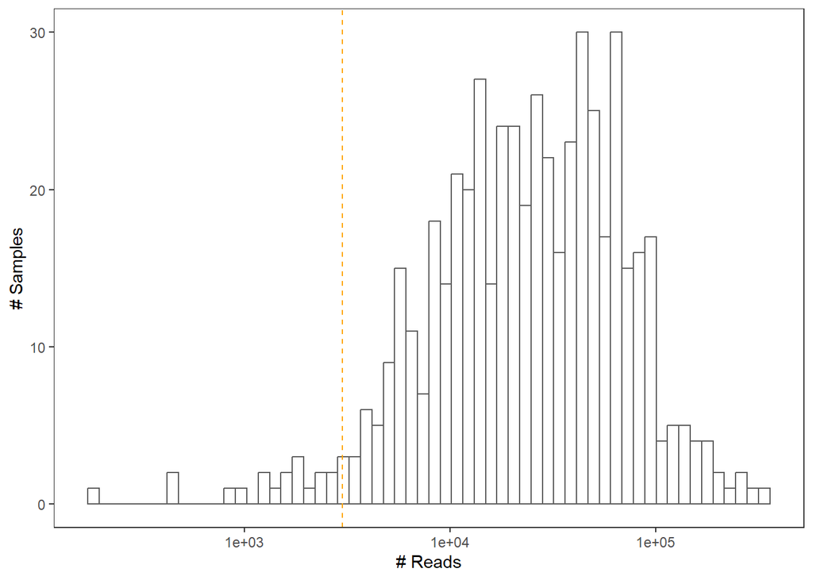

```r
pcr_seq_depth_overall <- ggplot(abundance_metadf, aes(depth)) +
  geom_histogram(bins = 60, color = "grey36", fill = "white") +
  geom_vline(xintercept = 3000, lty = 2,color = "orange") + # threshold
  scale_x_log10() +
  labs(x = "# Reads", y = "# Samples") +
  theme_bw() +
  theme(panel.grid = element_blank())

pcr_seq_depth_overall
```

Now let’s flag samples with an acceptable (TRUE) or unacceptable (FALSE) sequencing depth. We should aim to keep at least 90% of samples.

```r
abundance_metadf$depth_ok <- ifelse(abundance_metadf$depth < 3000, F, T)

table(abundance_metadf$depth_ok[abundance_metadf$negCheckLogical=="FALSE"]) /
  nrow(abundance_metadf[abundance_metadf$negCheckLogical=="FALSE",])
```

```
     FALSE       TRUE
0.03625954 0.96374046
```

A minimum threshold of 3000 reads looks like it could work well. Let’s now filter our data set to remove any samples below 3000.

```r
sample_depths_object <- sample_sums(phylo_eDNA_decontam) # Calculate sample sequencing depths
min_reads <- 3000 # Define the minimum read threshold

# Prune samples with fewer than 3000 reads
phylo_eDNA_decontam_filtered <- prune_samples(sample_depths_object >= min_reads, phylo_eDNA_decontam)

#Check the number of samples before and after filtering
cat("Number of samples before filtering:", nsamples(phylo_eDNA_decontam), "\n")
```

```
Number of samples before filtering: 524
```

```r
cat("Number of samples after filtering:", nsamples(phylo_eDNA_decontam_filtered), "\n") #removed 19 samples
```

```
Number of samples after filtering: 505
```

### Filtering for target functional groups (broad)

For this project, we were only interested in marine invertebrates and algae. So, we need to remove any other type of taxa. We’ll start with a broad removal, then focus on species phyla.

Let’s first examine what groups we have.

```r
# save the taxa list before filtering for saving later
full_nontarget_phylo <- phylo_eDNA_decontam_filtered

# which groups
unique(tax_table(phylo_eDNA_decontam_filtered)[, "adult"])
```

```
Taxonomy Table:     [22 taxa by 1 taxonomic ranks]:
                            adult
Abra nitida                 "benthos"
Acanthochiasmidae           "phytoplankton"
Acartia tonsa cryophylla    "mesoplankton"
Acinetospora filamentosa    "macroalgae"
Acoela                      "macrobenthos"
Acremonium fuci             NA
Alcyonium                   "megabenthos"
Alexandrium andersonii      "mixoplankton"
Alexandrium minutum         "microplankton"
Allas                       "zooplankton"
Ameira scotti               "meiobenthos"
Ammodytes marinus           "fish"
Amphidiniopsis              "nanoplankton"
Amphidiniopsis rotundata    "microbenthos"
Archilopsis spinosa         "turbellaria"
Aureococcus anophagefferens "algae"
Bufo bufo                   "nekton"
Calanus                     "macroplankton"
Crinoidea                   "epibenthos"
Duboscquella                "plankton"
Echinocardium cordatum      "endobenthos"
Halodule uninervis          "phytobenthos"
```

Define which groups not of interest.

```r
fish_and_small_stuff <- c("fish",
                         "microplankton",
                         "phytoplankton",
                         "nanoplankton",
                         "mixoplankton",
                         "microbenthos")

other_unwanted_class <- c("Aves",
                          "Mammalia",
                          "Amphibia")

other_unwanted_order <- c("Squamata")
```

Now let’s remove them from the relevant groups.

```r
phylo_eDNA_decontam_filtered <- subset_taxa(
  phylo_eDNA_decontam_filtered,
  !(adult %in% fish_and_small_stuff) &
  !(class %in% other_unwanted_class) &
  !(order %in% other_unwanted_order)
)

# Rmove any taxa without occurances
phylo_eDNA_decontam_filtered <- subset_taxa(phylo_eDNA_decontam_filtered, taxa_sums(phylo_eDNA_decontam_filtered) > 0)

phylo_eDNA_decontam_filtered
```

```
phyloseq-class experiment-level object
otu_table()   OTU Table:         [ 1398 taxa and 505 samples ]
sample_data() Sample Data:       [ 505 samples by 42 sample variables ]
tax_table()   Taxonomy Table:    [ 1398 taxa by 13 taxonomic ranks ]
```

### Filtering for target taxa (more specific)

Let’s define which phyla we are interested in.

```r
target_phyla <-   c(
  "Acoela",
  "Amphioxus",
  "Annelida",
  "Arthropoda",
  "Brachiopoda",
  "Bryozoa",
  "Cephalochordata",
  "Chaetognatha",
  "Chlorophyta",
  "Chordata",
  "Cnidaria",
  "Crustacea",
  "Ctenophora",
  "Dinoflagellata",
  "Echiura",
  "Echinoderm",
  "Echinodermata",
  "Euglenophyta",
  "Gastrotricha",
  "Gnathostomulids",
  "Gyrista",
  "Hemichordata",
  "Kamptozoa",
  "Kinorhyncha",
  "Loricifera",
  "Mollusca",
  "Monogenea",
  "Myzostomida",
  "Nematoda",
  "Nemertinea",
  "Ochrophyta",
  "Orthonectida",
  "Phaeophyta",
  "Phoronida",
  "Placozoa",
  "Platyhelminthes",
  "Porifera",
  "Priapulida",
  "Pycnogonida",
  "Rhodophyta",
  "Sipunculida",
  "Thallophyta",
  "Tunicata",
  "Turbellaria",
  "Xenoturbella",
  "Xiphosura"
)
```

Now let’s remove everything other than target taxa from the data.

```r
phylo_eDNA_decontam_filtered <- subset_taxa(phylo_eDNA_decontam_filtered,                                              phylum %in% target_phyla)

# Rmove any taxa without occurances
phylo_eDNA_decontam_filtered <- subset_taxa(phylo_eDNA_decontam_filtered, taxa_sums(phylo_eDNA_decontam_filtered) > 0)

phylo_eDNA_decontam_filtered
```

```
phyloseq-class experiment-level object
otu_table()   OTU Table:         [ 1026 taxa and 505 samples ]
sample_data() Sample Data:       [ 505 samples by 42 sample variables ]
tax_table()   Taxonomy Table:    [ 1026 taxa by 13 taxonomic ranks ]
```

Now let’s save each of the lists (target and non-target for each primer) for supplemntary information.

```r
# explore
full_nontarget_phylo
```

```
phyloseq-class experiment-level object
otu_table()   OTU Table:         [ 1674 taxa and 505 samples ]
sample_data() Sample Data:       [ 505 samples by 42 sample variables ]
tax_table()   Taxonomy Table:    [ 1674 taxa by 13 taxonomic ranks ]
```

```r
phylo_eDNA_decontam_filtered
```

```
phyloseq-class experiment-level object
otu_table()   OTU Table:         [ 1026 taxa and 505 samples ]
sample_data() Sample Data:       [ 505 samples by 42 sample variables ]
tax_table()   Taxonomy Table:    [ 1026 taxa by 13 taxonomic ranks ]
```

```r
# get only non-target
taxa_to_remove <- taxa_names(phylo_eDNA_decontam_filtered)
nontarget_only_phylo <- prune_taxa(!(taxa_names(full_nontarget_phylo) %in% taxa_to_remove), full_nontarget_phylo)

# save only genus and species level for supp
tax_table_data <- tax_table(phylo_eDNA_decontam_filtered)
keep_taxa <- rownames(tax_table_data)[tax_table_data[, "rank"] %in% c("Species", "Genus")]
phylo_target_genus_species <- prune_taxa(keep_taxa, phylo_eDNA_decontam_filtered)

tax_table_data_nontarget <- tax_table(nontarget_only_phylo)
keep_taxa_nontarget <- rownames(tax_table_data_nontarget)[tax_table_data_nontarget[, "rank"] %in% c("Species", "Genus")]
phylo_nontarget_genus_species <- prune_taxa(keep_taxa_nontarget, nontarget_only_phylo)

# save non-target list by primer
nontarget_CO1 <- ps_filter(phylo_nontarget_genus_species, primer == "CO1")
nontarget_CO1_list <- tax_table(nontarget_CO1)
write.csv(nontarget_CO1_list, file = "Processed_data/nontarget_CO1_taxa_list.csv", row.names = FALSE)

nontarget_18S <- ps_filter(phylo_nontarget_genus_species, primer == "18S")
nontarget_18S_list <- tax_table(nontarget_18S)
write.csv(nontarget_18S_list, file = "Processed_data/nontarget_18S_taxa_list.csv", row.names = FALSE)

# save target list by primer
target_CO1 <- ps_filter(phylo_target_genus_species, primer == "CO1")
target_CO1_list <- tax_table(target_CO1)
write.csv(target_CO1_list, file = "Processed_data/target_CO1_taxa_list.csv", row.names = FALSE)

target_18S <- ps_filter(phylo_target_genus_species, primer == "18S")
target_18S_list <- tax_table(target_18S)
write.csv(target_18S_list, file = "Processed_data/target_18S_taxa_list.csv", row.names = FALSE)
```

Let’s check to see how many taxa we have for invertebrates and macroalgae.

First, let’s define our groups.

```r
invert_phyla <- c(
  "Acoela",
  "Amphioxus",
  "Annelida",
  "Arthropoda",
  "Brachiopoda",
  "Bryozoa",
  "Cephalochordata",
  "Chaetognatha",
  "Chordata",
  "Cnidaria",
  "Crustacea",
  "Echiura",
  "Echinoderm",
  "Echinodermata",
  "Gastrotricha",
  "Gnathostomulids",
  "Hemichordata",
  "Kamptozoa",
  "Kinorhyncha",
  "Loricifera",
  "Mollusca",
  "Monogenea",
  "Myzostomida",
  "Nematoda",
  "Nemertinea",
  "Orthonectida",
  "Phaeophyta",
  "Phoronida",
  "Placozoa",
  "Platyhelminthes",
  "Porifera",
  "Priapulida",
  "Pycnogonida",
  "Sipunculida",
  "Thallophyta",
  "Tunicata",
  "Xenoturbella",
  "Xiphosura"
)

algae_phyla <- c(
  "Chlorophyta",
  "Ctenophora",
  "Dinoflagellata",
  "Euglenophyta",
  "Gyrista",
  "Ochrophyta",
  "Phaeophyta",
  "Rhodophyta",
  "Thallophyta"
)
```

Let’s look at invertebrates first.

```r
phylo_eDNA_decontam_filtered_invert <- subset_taxa(phylo_eDNA_decontam_filtered, phylum %in% invert_phyla)

phylo_eDNA_decontam_filtered_invert
```

```
phyloseq-class experiment-level object
otu_table()   OTU Table:         [ 737 taxa and 505 samples ]
sample_data() Sample Data:       [ 505 samples by 42 sample variables ]
tax_table()   Taxonomy Table:    [ 737 taxa by 13 taxonomic ranks ]
```

```r
print(paste("Invertebrate species account for", (737 / 1026) * 100, "% of detections."))
```

```
[1] "Invertebrate species account for 71.8323586744639 % of detections."
```

Now let’s look at algae.

```r
phylo_eDNA_decontam_filtered_algae <- subset_taxa(phylo_eDNA_decontam_filtered, phylum %in% algae_phyla)

phylo_eDNA_decontam_filtered_algae
```

```
phyloseq-class experiment-level object
otu_table()   OTU Table:         [ 289 taxa and 505 samples ]
sample_data() Sample Data:       [ 505 samples by 42 sample variables ]
tax_table()   Taxonomy Table:    [ 289 taxa by 13 taxonomic ranks ]
```

```r
print(paste("Algae species account for", (289 / 1026) * 100, "% of detections."))
```

```
[1] "Algae species account for 28.1676413255361 % of detections."
```

### Rarefying

Sometimes, we may want to rarefy our data.

```r
#pseq_rarefy <- phyloseq::rarefy_even_depth(phylo_eDNA_decontam_filtered,
                                           #sample.size = #min(microbiome::readcount(phylo_eDNA_decontam_filtered)))

#pseq_rarefy
#microbiome::readcount(pseq_rarefy)
```

## Save final datasets

We won’t be making anymore changes to our main data, so let’s export the `phyloseq` object to use elsewhere.

```r
phylo_rocky_eDNA <- phylo_eDNA_decontam_filtered

save(phylo_rocky_eDNA, file = "Processed_Data/phylo_rocky_eDNA.RData") #save object
```

And the rarefied data.

```r
#save(pseq_rarefy, file = "Processed_Data/phylo_rocky_eDNA_rarefied.RData") #save object
```

Let’s also convert it to a long data format in case we need it for further analyses.

```r
#Extra elements and format
#OTU table
otu_table <- as.data.frame(otu_table(phylo_rocky_eDNA))
otu_table$taxa <- rownames(otu_table)
rownames(otu_table) <- NULL
otu_long <- melt(otu_table, id.vars = c("taxa"))
colnames(otu_long) = c("taxa", "fullID", "reads")

# Taxonomic info
taxa_table <- as.data.frame(tax_table(phylo_rocky_eDNA))
taxa_table$taxa <- rownames(taxa_table)

# Meta data
sample_data <- data.frame(sample_data(phylo_rocky_eDNA))

# Merge
merged_data <- right_join(otu_long, sample_data, by = "fullID")
phylo_rocky_eDNA_long <- right_join(merged_data, taxa_table, by = "taxa")
phylo_rocky_eDNA_long$localityID <- as.factor(phylo_rocky_eDNA_long$localityID)

#save combined dataset
write.csv(phylo_rocky_eDNA_long, "Processed_Data/phylo_rocky_eDNA_long.csv")
```

## Further quality control

Now we’ve got our decontaminated and filtered data, we can do a variety of quality control checks to make sure everything looks like it should.

We have three `phyloseq` objects which we can explore in different ways: pre-decontamination, pre-filtering and post-processing (aka our final data).

```r
phylo_eDNA_predecontam #pre-decontamination
```

```
phyloseq-class experiment-level object
otu_table()   OTU Table:         [ 1725 taxa and 655 samples ]
sample_data() Sample Data:       [ 655 samples by 42 sample variables ]
tax_table()   Taxonomy Table:    [ 1725 taxa by 13 taxonomic ranks ]
```

```r
phylo_eDNA_decontam #pre-filtering
```

```
phyloseq-class experiment-level object
otu_table()   OTU Table:         [ 1674 taxa and 524 samples ]
sample_data() Sample Data:       [ 524 samples by 42 sample variables ]
tax_table()   Taxonomy Table:    [ 1674 taxa by 13 taxonomic ranks ]
```

```r
phylo_eDNA_decontam_filtered #final data
```

```
phyloseq-class experiment-level object
otu_table()   OTU Table:         [ 1026 taxa and 505 samples ]
sample_data() Sample Data:       [ 505 samples by 42 sample variables ]
tax_table()   Taxonomy Table:    [ 1026 taxa by 13 taxonomic ranks ]
```

### Set-up (functions and variables)

First, let’s stop scientific notation being presented in plots.

```r
options(scipen=5)
```

Let’s set-up some functions we’ll use later on to extract pieces of information from our data. Note: these functions only work currently for the format of IDs in this data set. They made need altering for other data sets.

```r
# Extract fieldID when adding TRUE or FALSE for replicate status
extract_middle <- function(x) {
  middle <- gsub("^[^-]+-([A-Za-z]{2}\\d{2}-\\d{2}).*_(18S|CO1)$", "\\1", x)
  return(middle)
}

# Extract site when adding TRUE or FALSE for replicate status
extract_site <- function(x) {
  # Extract the part after the first '-' and before the second '-' or '_' and remove anything after
  middle <- gsub("^[^-]+-([^-]+)-.*_(18S|CO1)$", "\\1", x)
  return(middle)
}


# Extract the middle part (including fieldID and primer)
extract_middle_all <- function(x) {
  # Extract the middle part of the string
  middle <- gsub("^[^-]+-(.+)$", "\\1", x)

  # Remove the term 'rep' and any following number
  middle <- gsub("rep\\d*", "", middle, ignore.case = TRUE)

  # Return the modified middle part
  return(middle)
}

# Modify the extract_middle function to extract the fieldID part for CO1 only groups (run 3)
extract_middle_CO1 <- function(x) {
  middle <- gsub("^[^-]+-([A-Za-z]{2}\\d{2}-\\d{2}).*_CO1$", "\\1", x)
  return(middle)
}
```

We need to set some variables for plots later.

```r
site_order <- c("Scourie",
                "Rispond",
                "Skerray",
                "Murkle Bay",
                "Portskerra",
                "Borwick, Yesnaby",
                "Sannick",
                "Wick", #Scotland
                "Aberystwyth",
                "Neyland",
                "Broad Haven",
                "Skomer Island",
                "West Angle",
                "Monkstone Point",
                "Dale Jetty",
                "Martin's Haven", #South Wales
                "Castlehead Rocks",
                "Filey Brigg",
                "Newton Point",
                "Rumbling Kern",
                "Scalby Mills", #Northumbria
                "Great Orme East",
                "Little Orme",
                "Menai Bridge",
                "Porth Oer",
                "Porth Swtan",
                "Rhosneigr", #North Wales
                "Lizard Point",
                "Looe",
                "Sennen Cove",
                "St Ives",
                "Trevone") #Cornwall

control_order <- c("field-control",
                   "lab-extraction-control",
                   "lab-negative-control",
                   "lab-positive-control",
                   "sample",
                   "run-replicate",
                   "failed-repeat",
                   "plate-replicate")

control_order_tidy <- c("Field control",
                        "Lab extraction control",
                        "Lab negative control",
                        "Lab positive control",
                        "Sample",
                        "Run replicate",
                        "Failed repeat",
                        "Plate replicate")
```

### Explore read depths

#### Table summary

Let’s summarize the number of reads before and after decontamination and filtering.

We calculated the pre-filtered data above, so now let’s calculate the pre decontamination and post filtered data, then compare them.

Pre-decontamination first.

```r
# Number of reads per sample (after decontamination and filtering)
sample_depths_predecontam <- microbiome::readcount(phylo_eDNA_predecontam) %>%
  as.data.frame() %>%
  tibble::rownames_to_column(var = "fullID")

colnames(sample_depths_predecontam) <- c("fullID", "reads_predecontam")

# Calculate the total ASVs by counting the number of rows
num_asvs_vec_predecontam <- c(nrow(phyloseq::otu_table(phylo_eDNA_predecontam)))
names(num_asvs_vec_predecontam)[1] <- "no.taxa"
num_asvs_vec_predecontam
```

```
no.taxa
   1725
```

```r
# Total number asvs per sample
asv_sum_predecontam <- as.data.frame(colSums(phyloseq::otu_table(phylo_eDNA_predecontam)!=0))

#Extract sample meta data as a separate R object
abundance_metadf_predecontam <- phyloseq::sample_data(phylo_eDNA_predecontam)

#Check if vector of sample_depths & asv_sum has the same order as our metadata rows
identical(sample_depths_predecontam$fullID,row.names(abundance_metadf_predecontam))
```

```
[1] TRUE
```

```r
identical(row.names(asv_sum_predecontam),row.names(abundance_metadf_predecontam))
```

```
[1] TRUE
```

```r
#Add sample depths and number of ASVs to metadata data frame
abundance_metadf_predecontam[,"depth"] <- sample_depths_predecontam$reads_predecontam
abundance_metadf_predecontam[,"ASVs"] <- asv_sum_predecontam
```

Post-filtered.

```r
# Number of reads per sample (after decontamination and filtering)
sample_depths_decontam_filter <- microbiome::readcount(phylo_eDNA_decontam_filtered) %>%
  as.data.frame() %>%
  tibble::rownames_to_column(var = "fullID")

colnames(sample_depths_decontam_filter) <- c("fullID", "reads_postfilter")

# Calculate the total ASVs by counting the number of rows
num_asvs_vec_filter <- c(nrow(phyloseq::otu_table(phylo_eDNA_decontam_filtered)))
names(num_asvs_vec_filter)[1] <- "no.taxa"
num_asvs_vec_filter
```

```
no.taxa
   1026
```

```r
# Total number asvs per sample
asv_sum_filter <- as.data.frame(colSums(phyloseq::otu_table(phylo_eDNA_decontam_filtered)!=0))

#Extract sample meta data as a separate R object
abundance_metadf_filter <- phyloseq::sample_data(phylo_eDNA_decontam_filtered)

#Check if vector of sample_depths & asv_sum has the same order as our metadata rows
identical(sample_depths_decontam_filter$fullID,row.names(abundance_metadf_filter))
```

```
[1] TRUE
```

```r
identical(row.names(asv_sum_filter),row.names(abundance_metadf_filter))
```

```
[1] TRUE
```

```r
#Add sample depths and number of ASVs to metadata data frame
abundance_metadf_filter[,"depth"] <- sample_depths_decontam_filter$reads_postfilter
abundance_metadf_filter[,"ASVs"] <- asv_sum_filter
```

Join depth information into one data set.

```r
# Reads before and after decontamination together
all_depths <- left_join(sample_depths_decontam,
                        sample_depths_decontam_filter,
                        by = "fullID")

all_depths <- left_join(sample_depths_predecontam,
                        all_depths,
                        by = "fullID")

#add difference between start and end
all_depths$reads_removed <- all_depths$reads_prefilter - all_depths$reads_postfilter

tail(all_depths)
```

```
                  fullID reads_predecontam reads_prefilter reads_postfilter
650 PHD3-SCH04-09rep_CO1             67248           66980             4956
651 PHD3-SCH07-02rep_CO1             75436           75403            54742
652  PHD3-SW01-06rep_CO1             49183           49183             9203
653  PHD3-SW03-08rep_CO1             32311           32311              498
654  PHD3-SW05-01rep_CO1             20202           20020              165
655  PHD3-SW07-03rep_CO1             37441           37441             1455
    reads_removed
650         62024
651         20661
652         39980
653         31813
654         19855
655         35986
```

Let’s create some figures to visualize read depths before and after filtering. We’ll need to do some data wrangling for plotting.

#### Histograms

Pre-decontamination.

```r
sample_depths_predecontam$primer <- sapply(strsplit(sample_depths_predecontam$fullID, "_", fixed=TRUE), tail, 1) # Add primer variable

#check which samples have no reads and remove
sample_depths_predecontam_zero <- sample_depths_predecontam %>% subset(sample_depths_predecontam == 0)
sample_depths_predecontam_nozero <- anti_join(sample_depths_predecontam, sample_depths_predecontam_zero)

#get means
mu_primer <- sample_depths_predecontam_nozero %>%
  dplyr::group_by(primer) %>%
  dplyr::summarise(mean = mean(reads_predecontam),
                   SE = sd(reads_predecontam) / sqrt(n()))

print(mu_primer)
```

```
# A tibble: 2 × 3
  primer   mean    SE
  <chr>   <dbl> <dbl>
1 18S    53284. 3312.
2 CO1    26251. 1417.
```

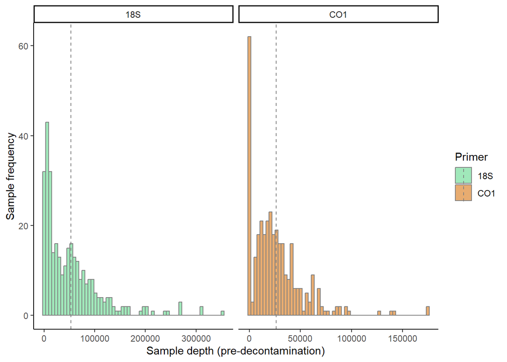

```r
reads_histo_predecontam <- ggplot(sample_depths_predecontam_nozero, aes(x=reads_predecontam, fill = primer, colour = primer)) +
  geom_histogram(bins = 60, alpha = 0.9, position = "dodge") +
  geom_vline(data=mu_primer, aes(xintercept=mean, color=primer),
             linetype="dashed")+
  facet_wrap(~primer, scale = 'free_x') +
  scale_color_manual(values=c("grey50","grey50"))+
  scale_fill_manual(values=c("#96E6B3","#E5A361"))+
  xlab("Sample depth (pre-decontamination)") + ylab("Sample frequency") +
  labs(fill = "Primer", colour = "Primer")+
  #xlim(0, 200000) + #can limited extreme values to view pattern better
  theme_classic()

reads_histo_predecontam
```

Pre-filtering.

```r
sample_depths_decontam$primer <- sapply(strsplit(sample_depths_decontam$fullID, "_", fixed=TRUE), tail, 1) # Add primer variable

#check which samples have no reads and remove
sample_depths_decontam_zero <- sample_depths_decontam %>% subset(sample_depths_decontam == 0)
sample_depths_decontam_nozero <- anti_join(sample_depths_decontam, sample_depths_decontam_zero)

#get means
mu_primer <- sample_depths_decontam_nozero %>%
  dplyr::group_by(primer) %>%
  dplyr::summarise(mean = mean(reads_prefilter),
                   SE = sd(reads_prefilter) / sqrt(n()))

print(mu_primer)
```

```
# A tibble: 2 × 3
  primer   mean    SE
  <chr>   <dbl> <dbl>
1 18S    51513. 3217.
2 CO1    26364. 1489.
```

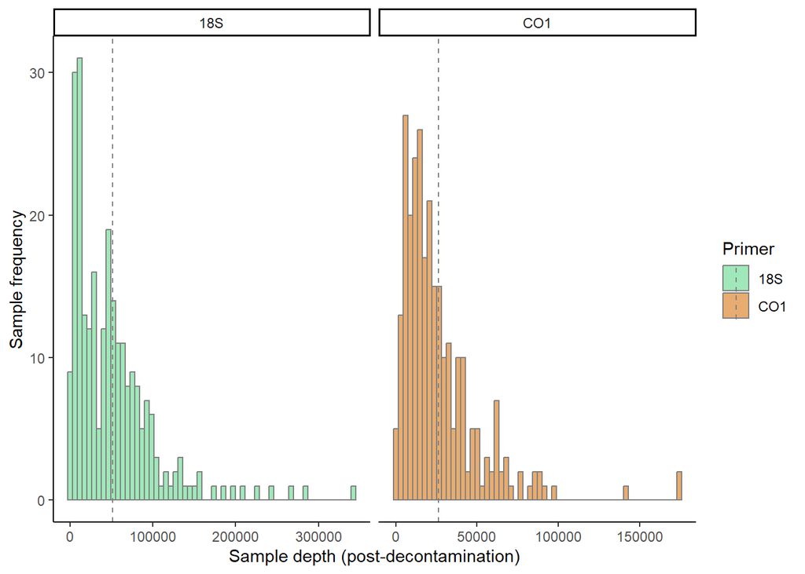

```r
reads_histo <- ggplot(sample_depths_decontam_nozero, aes(x=reads_prefilter, fill = primer, colour = primer)) +
  geom_histogram(bins = 60, alpha = 0.9, position = "dodge") +
  geom_vline(data=mu_primer, aes(xintercept=mean, color=primer),
             linetype="dashed")+
  facet_wrap(~primer, scale = 'free_x') +
  scale_color_manual(values=c("grey50","grey50"))+
  scale_fill_manual(values=c("#96E6B3","#E5A361"))+
  xlab("Sample depth (post-decontamination)") + ylab("Sample frequency") +
  labs(fill = "Primer", colour = "Primer")+
  #xlim(0, 200000) + #can limited extreme values to view pattern better
  theme_classic()

reads_histo
```

Post-filtering.

```r
sample_depths_decontam_filter$primer <- sapply(strsplit(sample_depths_decontam_filter$fullID, "_", fixed=TRUE), tail, 1) # Add primer variable

#check which samples have no reads and remove
sample_depths_decontam_filter_zero <- sample_depths_decontam_filter %>% subset(sample_depths_decontam_filter == 0)
sample_depths_decontam_filter_nozero <- anti_join(sample_depths_decontam_filter, sample_depths_decontam_filter_zero)

#get means
mu_primer_filter <- sample_depths_decontam_filter_nozero %>%
  dplyr::group_by(primer) %>%
  dplyr::summarise(mean = mean(reads_postfilter),
                   SE = sd(reads_postfilter) / sqrt(n()))

print(mu_primer_filter)
```

```
# A tibble: 2 × 3
  primer   mean    SE
  <chr>   <dbl> <dbl>
1 18S    26594. 2171.
2 CO1    10258.  938.
```

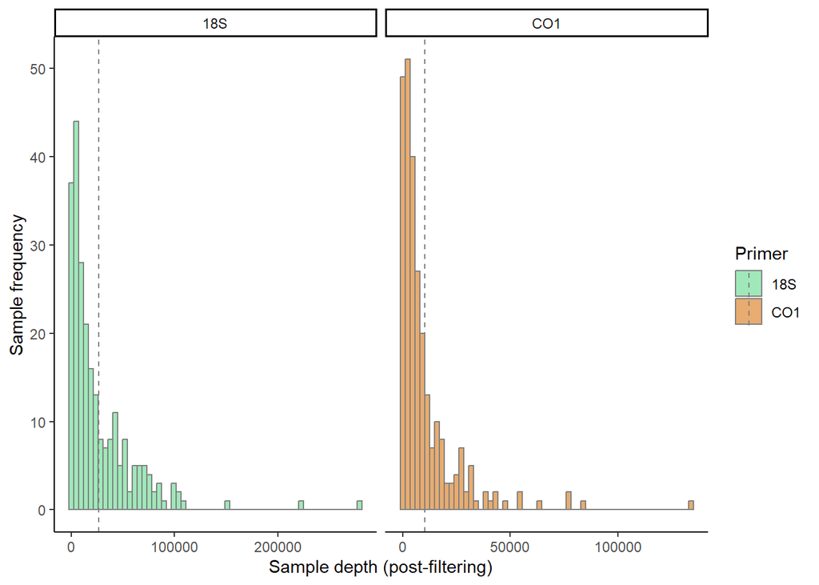

```r
reads_histo_filter <- ggplot(sample_depths_decontam_filter_nozero, aes(x=reads_postfilter, fill = primer, colour = primer)) +
  geom_histogram(bins = 60, alpha = 0.9, position = "dodge") +
  geom_vline(data=mu_primer_filter, aes(xintercept=mean, color=primer),
             linetype="dashed")+
  facet_wrap(~primer, scale = 'free_x') +
  scale_color_manual(values=c("grey50","grey50"))+
  scale_fill_manual(values=c("#96E6B3","#E5A361"))+
  xlab("Sample depth (post-filtering)") + ylab("Sample frequency") +
  labs(fill = "Primer", colour = "Primer")+
  #xlim(0, 200000) + #can limited extreme values to view pattern better
  theme_classic()

reads_histo_filter
```

Join them together to export.

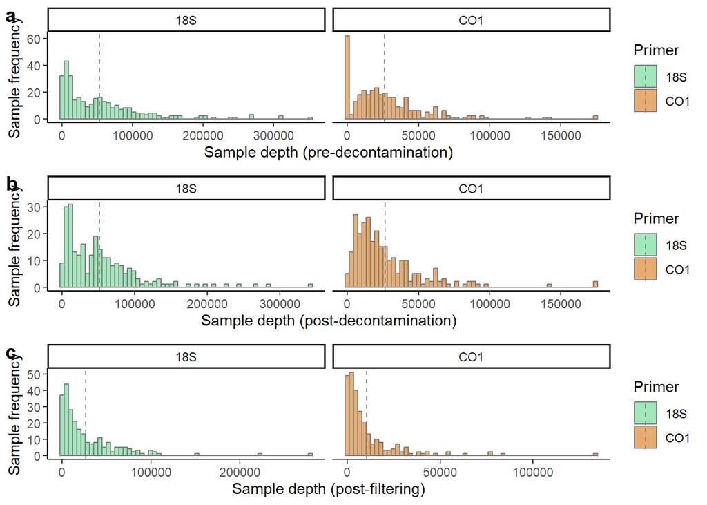

```r
reads_histo_together <- cowplot::plot_grid(reads_histo_predecontam, reads_histo, reads_histo_filter, labels = c("a", "b", "c"), ncol = 1)

reads_histo_together
```

```r
#save
ggsave(reads_histo_together, filename = "Figures/sample_depth_histogram_together.png", height = 300, width = 220, dpi = 300, units = "mm")
```

#### Reads by site

Let’s look at reads over sites in boxplots.

Pre-decontamination.

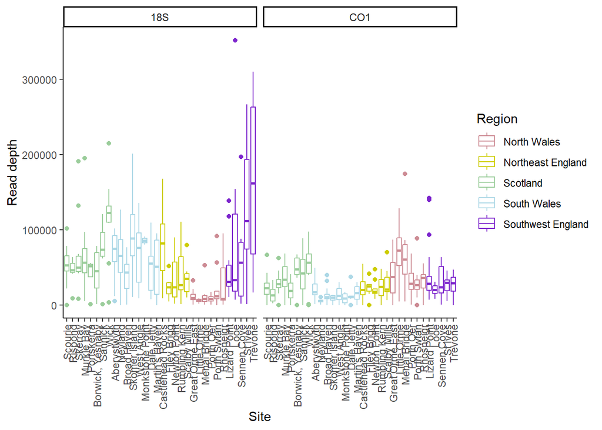

```r
reads_boxplot_sites_predecontam <- ggplot2::ggplot(abundance_metadf_predecontam, aes(y=depth, x=verbatimLocality, colour = country)) +
  ggplot2::geom_boxplot() +
  scale_x_discrete(limits = site_order)+
  scale_colour_manual(values = c("Scotland" = "darkseagreen3",
                                 "North Wales" = "lightpink3",
                                 "Northeast England" = "yellow3",
                                 "South Wales" = "lightblue",
                                 "Southwest England" = "purple3")) +
  xlab("Site")+ ylab("Read depth") +
  labs(colour = "Region") +
  facet_wrap(~primer) +
  theme_classic() +
  theme(axis.text.x = element_text(angle = 90, vjust = 0.5, hjust=1))

reads_boxplot_sites_predecontam
```

Pre-filtering.

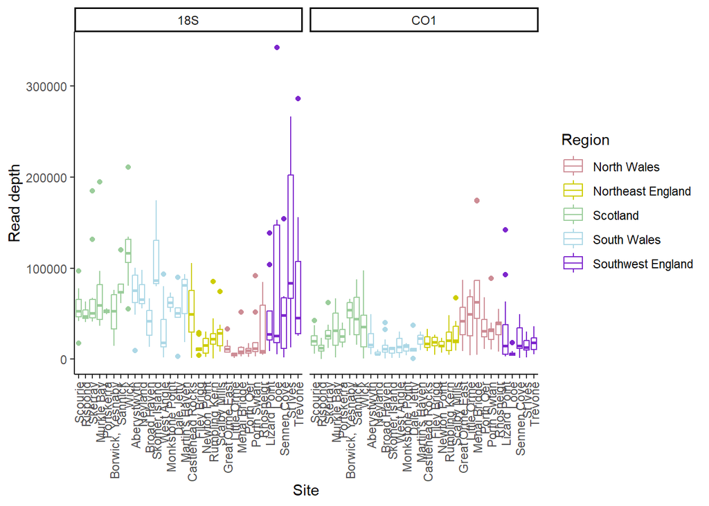

```r
reads_boxplot_sites <- ggplot2::ggplot(abundance_metadf, aes(y=depth, x=verbatimLocality, colour = country)) +
  ggplot2::geom_boxplot() +
  scale_x_discrete(limits = site_order)+
  scale_colour_manual(values = c("Scotland" = "darkseagreen3",
                                 "North Wales" = "lightpink3",
                                 "Northeast England" = "yellow3",
                                 "South Wales" = "lightblue",
                                 "Southwest England" = "purple3")) +
  xlab("Site")+ ylab("Read depth") +
  labs(colour = "Region") +
  facet_wrap(~primer) +
  theme_classic() +
  theme(axis.text.x = element_text(angle = 90, vjust = 0.5, hjust=1))

reads_boxplot_sites
```

Post-filtering.

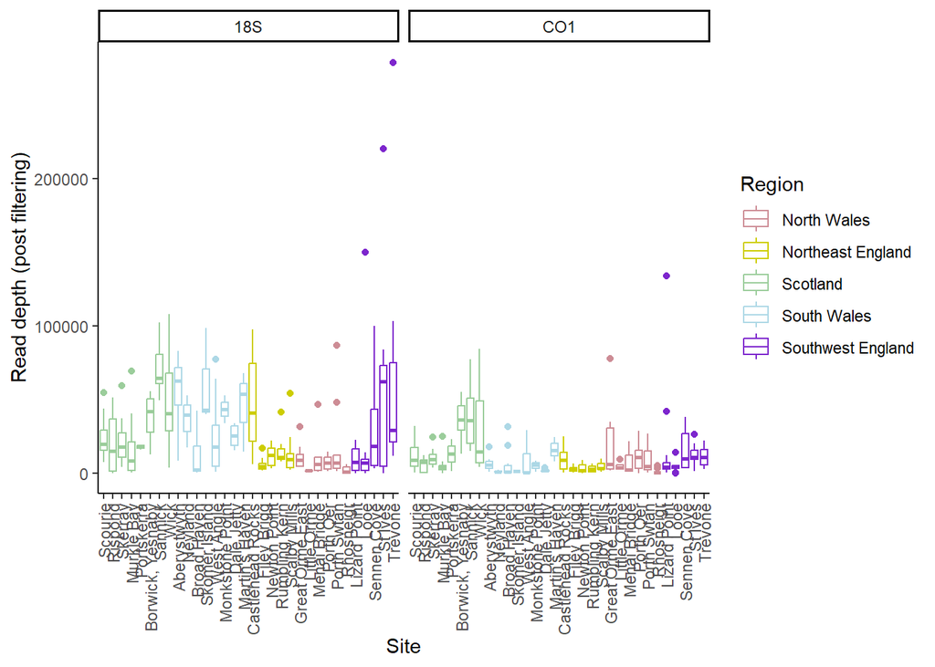

```r
reads_boxplot_sites_filter <- ggplot2::ggplot(abundance_metadf_filter, aes(y=depth, x=verbatimLocality, colour = country)) +
  ggplot2::geom_boxplot() +
  scale_x_discrete(limits = site_order)+
  scale_colour_manual(values = c("Scotland" = "darkseagreen3",
                                 "North Wales" = "lightpink3",
                                 "Northeast England" = "yellow3",
                                 "South Wales" = "lightblue",
                                 "Southwest England" = "purple3")) +
  xlab("Site")+ ylab("Read depth (post filtering)") +
  labs(colour = "Region") +
  facet_wrap(~primer) +
  theme_classic() +
  theme(axis.text.x = element_text(angle = 90, vjust = 0.5, hjust=1))

reads_boxplot_sites_filter
```

Join them together to export.

[figure not shown]

```r
reads_boxplot_sites_together <- cowplot::plot_grid(reads_boxplot_sites_predecontam, reads_boxplot_sites, reads_boxplot_sites_filter, labels = c("a", "b", "c"), ncol = 1)

reads_boxplot_sites_together
```

```r
#save
ggsave(reads_boxplot_sites_together, filename = "Figures/reads_boxplot_sites_together.png", height = 400, width = 250, dpi = 300, units = "mm")
```

#### Reads by sample type

Let’s tidy the names of our sample types.

```r
abundance_metadf_predecontam <- abundance_metadf_predecontam %>%
  data.frame() %>%
  dplyr::mutate(tidy_type_name = case_when(
    sampleType == "field-control" ~ "Field control",
    sampleType == "lab-extraction-control" ~ "Lab extraction control",
    sampleType == "lab-negative-control" ~ "Lab negative control",
    sampleType == "lab-positive-control" ~ "Lab positive control",
    sampleType == "sample" ~ "Sample",
    sampleType == "run-replicate" ~ "Run replicate",
    sampleType == "failed-repeat" ~ "Failed repeat",
    sampleType == "plate-replicate" ~ "Plate replicate",
    TRUE ~ as.character(sampleType) # This keeps any unmatched sampleType values
  ))

abundance_metadf <- abundance_metadf %>%
  data.frame() %>%
  dplyr::mutate(tidy_type_name = case_when(
    sampleType == "field-control" ~ "Field control",
    sampleType == "lab-extraction-control" ~ "Lab extraction control",
    sampleType == "lab-negative-control" ~ "Lab negative control",
    sampleType == "lab-positive-control" ~ "Lab positive control",
    sampleType == "sample" ~ "Sample",
    sampleType == "run-replicate" ~ "Run replicate",
    sampleType == "failed-repeat" ~ "Failed repeat",
    sampleType == "plate-replicate" ~ "Plate replicate",
    TRUE ~ as.character(sampleType) # This keeps any unmatched sampleType values
  ))

abundance_metadf_filter <- abundance_metadf_filter %>%
  data.frame() %>%
  dplyr::mutate(tidy_type_name = case_when(
    sampleType == "field-control" ~ "Field control",
    sampleType == "lab-extraction-control" ~ "Lab extraction control",
    sampleType == "lab-negative-control" ~ "Lab negative control",
    sampleType == "lab-positive-control" ~ "Lab positive control",
    sampleType == "sample" ~ "Sample",
    sampleType == "run-replicate" ~ "Run replicate",
    sampleType == "failed-repeat" ~ "Failed repeat",
    sampleType == "plate-replicate" ~ "Plate replicate",
    TRUE ~ as.character(sampleType) # This keeps any unmatched sampleType values
  ))
```

Before decontamination.

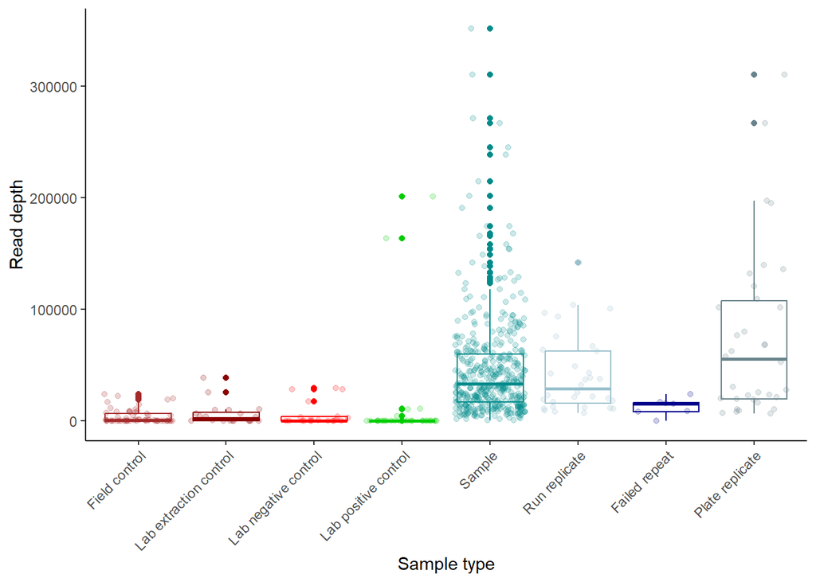

```r
reads_boxplot_sample_types_predecontam <- ggplot(abundance_metadf_predecontam, aes(x=tidy_type_name, y=depth, color=tidy_type_name)) +
  geom_boxplot() + theme_bw() +
  geom_jitter(alpha=0.2) +
  scale_color_manual(values = c("Field control" = "brown",
                                "Lab extraction control" = "red4",
                                "Lab negative control" = "red",
                                "Lab positive control" = "green3",
                                "Sample" ="cyan4",
                                "Run replicate" = "lightblue3",
                                "Failed repeat" = "blue4",
                                "Plate replicate" = "lightblue4"), na.value = "darkgrey") +
  #facet_wrap(~primer, scales = "free_y") +
  scale_x_discrete(limits = control_order_tidy)+
  xlab("Sample type") + ylab("Read depth") +
  labs(colour = "Sample type") +
  theme_classic() +
  theme(axis.text.x = element_text(angle=45, h=1),
        legend.position = "none")

reads_boxplot_sample_types_predecontam
```

Pre-filtering. We shouldn’t see negative or positive controls here anymore.

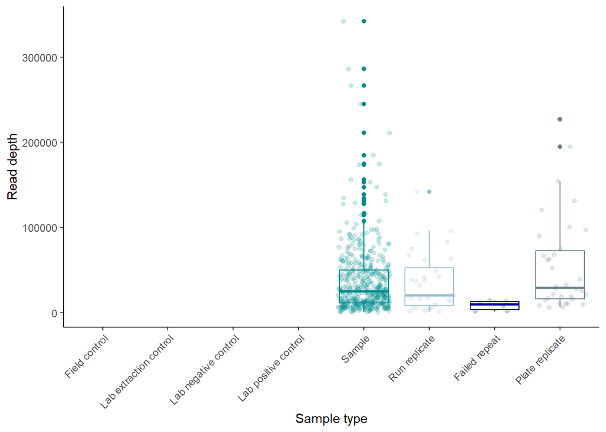

```r
reads_boxplot_sample_types <- ggplot(abundance_metadf, aes(x=tidy_type_name, y=depth, color=tidy_type_name)) +
  geom_boxplot() + theme_bw() +
  geom_jitter(alpha=0.2) +
  scale_color_manual(values = c("Field control" = "brown",
                                "Lab extraction control" = "red4",
                                "Lab negative control" = "red",
                                "Lab positive control" = "green3",
                                "Sample" ="cyan4",
                                "Run replicate" = "lightblue3",
                                "Failed repeat" = "blue4",
                                "Plate replicate" = "lightblue4"), na.value = "darkgrey") +
  #facet_wrap(~primer, scales = "free_y") +
  scale_x_discrete(limits = control_order_tidy)+
  xlab("Sample type") + ylab("Read depth") +
  labs(colour = "Sample type") +
  theme_classic() +
  theme(axis.text.x = element_text(angle=45, h=1),
        legend.position = "none")

reads_boxplot_sample_types
```

### Explore ASVs (or taxa at this point)

Pre-decontamination.

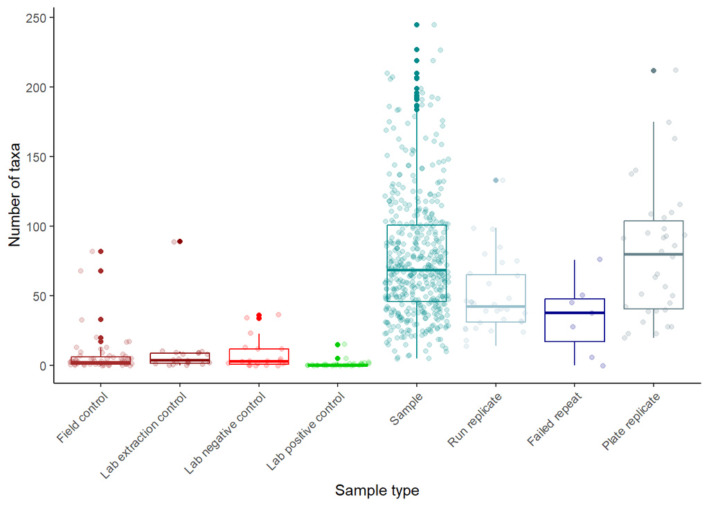

```r
ASVs_boxplot_sample_types_predecontam <- ggplot(abundance_metadf_predecontam, aes(x=tidy_type_name, y=ASVs, color=tidy_type_name)) +
  geom_boxplot() + theme_classic() +
  geom_jitter(alpha=0.2) +
  scale_color_manual(values = c("Field control" = "brown",
                                "Lab extraction control" = "red4",
                                "Lab negative control" = "red",
                                "Lab positive control" = "green3",
                                "Sample" ="cyan4",
                                "Run replicate" = "lightblue3",
                                "Failed repeat" = "blue4",
                                "Plate replicate" = "lightblue4"), na.value = "darkgrey") +
  #facet_wrap(~primer, scales = "free_y") +
  scale_x_discrete(limits = control_order_tidy) +
  labs(x = "Sample type", y = "Number of taxa") +
  theme(axis.text.x = element_text(angle=45, h=1), legend.position = "none")

ASVs_boxplot_sample_types_predecontam
```

Pre-filtering

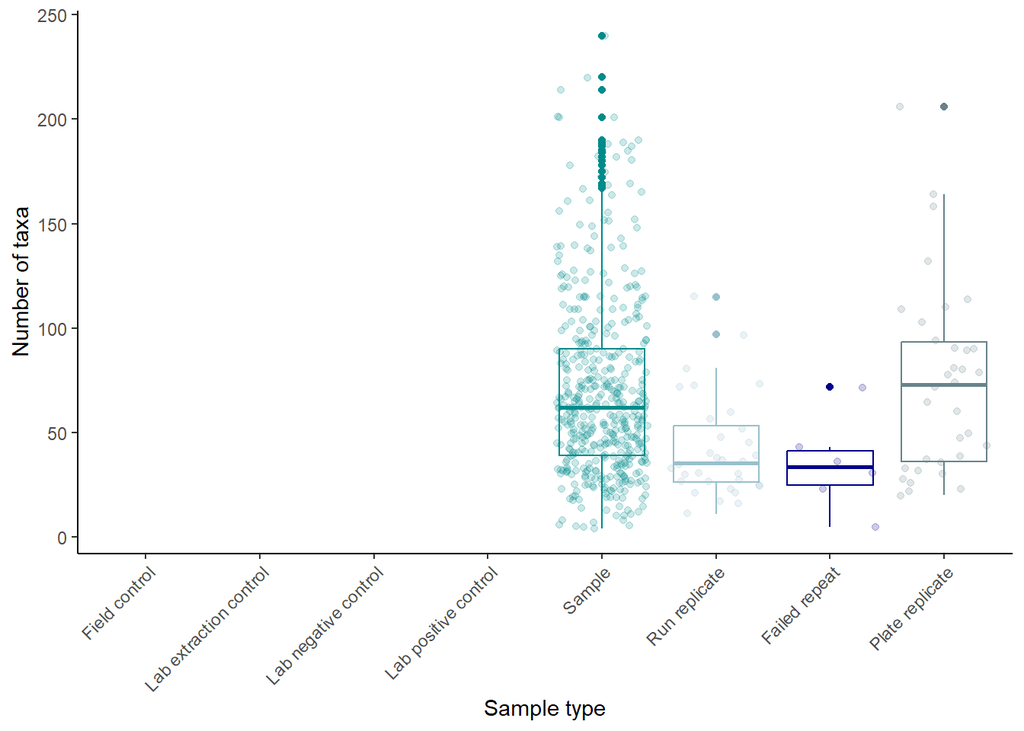

```r
ASVs_boxplot_sample_types_decontam <- ggplot(abundance_metadf, aes(x=tidy_type_name, y=ASVs, color=tidy_type_name)) +
  geom_boxplot() + theme_classic() +
  geom_jitter(alpha=0.2) +
  scale_color_manual(values = c("Field control" = "brown",
                                "Lab extraction control" = "red4",
                                "Lab negative control" = "red",
                                "Lab positive control" = "green3",
                                "Sample" ="cyan4",
                                "Run replicate" = "lightblue3",
                                "Failed repeat" = "blue4",
                                "Plate replicate" = "lightblue4"), na.value = "darkgrey") +
  #facet_wrap(~primer, scales = "free_y") +
  scale_x_discrete(limits = control_order_tidy) +
  labs(x= "Sample type", y = "Number of taxa")+
  theme(axis.text.x = element_text(angle=45, h=1), legend.position = "none")

ASVs_boxplot_sample_types_decontam
```

Let’s make a plot to show the raw reads and ASVs.

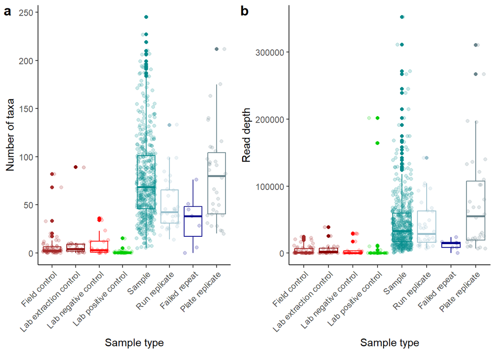

```r
ASVs_reads_sampletype <- cowplot::plot_grid(ASVs_boxplot_sample_types_predecontam, reads_boxplot_sample_types_predecontam, labels = c("a", "b", ncol = 2), rel_widths = c(1,1.1))

ASVs_reads_sampletype
```

```r
ggsave(filename = "Figures/ASVs_reads_sampletype.png", plot = ASVs_reads_sampletype,
       device = "png", dpi = 300, units = "mm", height = 140, width = 270)
```

We can also look at number of taxa in a scatter.

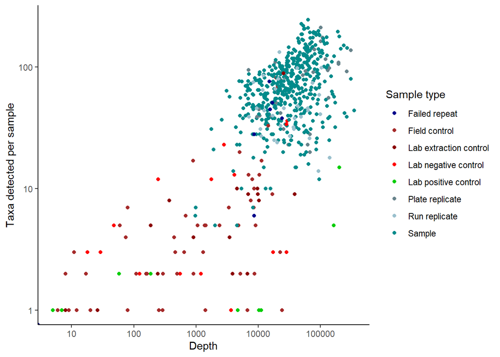

```r
ASV_reads_scatter_predecontam <- ggplot(abundance_metadf_predecontam, aes(x=depth, y=ASVs, color = tidy_type_name)) +
  geom_point() +
  scale_y_log10() + scale_x_log10() +
  scale_color_manual(values = c("Field control" = "brown",
                                "Lab extraction control" = "red4",
                                "Lab negative control" = "red",
                                "Lab positive control" = "green3",
                                "Sample" ="cyan4",
                                "Run replicate" = "lightblue3",
                                "Failed repeat" = "blue4",
                                "Plate replicate" = "lightblue4"), na.value = "darkgrey") +
  labs(color = "Sample type", x = "Depth", y = "Taxa detected per sample") +
  theme_classic()

ASV_reads_scatter_predecontam
```

### Comparing replicates

We have replication in different forms in our data. We have field replicates and technical replicates (between and within runs). We need to check how similar they are.

Let’s define replicates first.

```r
# Subset replicates and their counter parts
phylo_replicates_pairs = subset_samples(phylo_eDNA_decontam_filtered,
                                        pairedRepLogical == TRUE)

#further subs
phylo_replicates = subset_samples(phylo_eDNA_decontam_filtered,
                                  sampleType == "run-replicate" | sampleType == "plate-replicate")

phylo_run_replicates = subset_samples(phylo_eDNA_decontam_filtered,
                                      sampleType == "run-replicate")

phylo_sample_replicates = subset_samples(phylo_eDNA_decontam_filtered,
                                         sampleType == "plate-replicate")

replicate_names <- unique(sample_data(phylo_replicates)$fullID)
head(replicate_names)
```

```
[1] "PHD1-SCH01-04rep_18S" "PHD1-SCH01-04rep_CO1" "PHD1-SCH03-05rep_18S"
[4] "PHD1-SCH04-09rep_18S" "PHD1-SCH04-09rep_CO1" "PHD1-SCH07-02rep_18S"
```

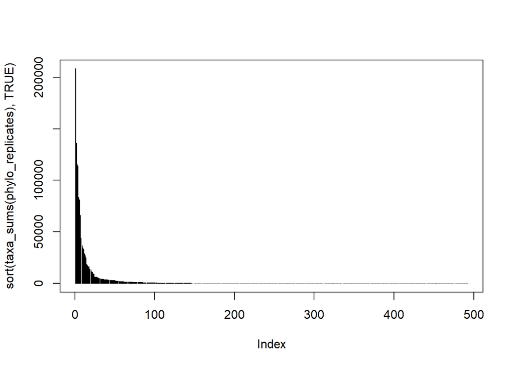

```r
##Clean out taxa/ASV columns that are no longer present
phylo_replicates <- prune_taxa(taxa_sums(phylo_replicates) > 0, phylo_replicates)

#How abundant are the ASVs in the controls?
plot(sort(taxa_sums(phylo_replicates), TRUE), type="h")
```

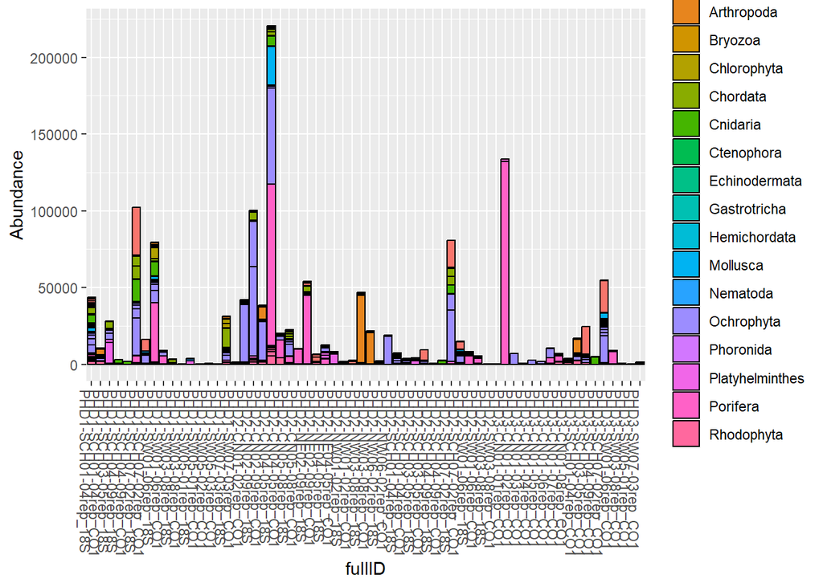

```r
#What's in them?
plot_bar(phylo_replicates, "fullID", fill = "phylum")
```

#### Between runs

Let’s order our samples for plotting later.

```r
# Sort lists of replicates
sample_order_run1v2 <- c(
  "PHD1-SCH01-04rep_18S",
  "PHD2-SCH01-04rep_18S",
  "PHD1-SCH01-04rep_CO1",
  "PHD2-SCH01-04rep_CO1",
  "PHD1-SCH03-05rep_18S",
  "PHD2-SCH03-05rep_18S",
  "PHD1-SCH04-09rep_18S",
  "PHD2-SCH04-09rep_18S",
  "PHD1-SCH04-09rep_CO1",
  "PHD2-SCH04-09rep_CO1",
  "PHD1-SCH07-02rep_18S",
  "PHD2-SCH07-02rep_18S",
  "PHD1-SCH07-02rep_CO1",
  "PHD2-SCH07-02rep_CO1",
  "PHD1-SW01-06rep_18S",
  "PHD2-SW01-06rep_18S",
  "PHD1-SW01-06rep_CO1",
  "PHD2-SW01-06rep_CO1",
  "PHD1-SW03-08rep_18S",
  "PHD2-SW03-08rep_18S",
  "PHD1-SW03-08rep_CO1",
  "PHD2-SW03-08rep_CO1",
  "PHD1-SW05-01rep_18S"
  #"PHD2-SW05-01rep_18S",
  #"PHD1-SW05-01rep_CO1",
  #"PHD2-SW05-01rep_CO1",
  #"PHD1-SW07-03rep_18S",
  #"PHD2-SW07-03rep_18S",
  #"PHD1-SW07-03rep_CO1",
  #"PHD2-SW07-03rep_CO1"
)

sample_order_run1v3 <- c(
  "PHD1-SCH01-04rep_CO1",
  "PHD3-SCH01-04rep_CO1",
  "PHD1-SCH04-09rep_CO1",
  "PHD3-SCH04-09rep_CO1",
  "PHD1-SCH07-02rep_CO1",
  "PHD3-SCH07-02rep_CO1",
  "PHD1-SW01-06rep_CO1",
  "PHD3-SW01-06rep_CO1",
  "PHD1-SW03-08rep_CO1",
  "PHD3-SW03-08rep_CO1",
  "PHD1-SW05-01rep_CO1",
  "PHD3-SW05-01rep_CO1",
  "PHD1-SW07-03rep_CO1",
  "PHD3-SW07-03rep_CO1"
)

sample_order_run2v3 <- c(
  "PHD2-CN01-01_CO1",
  "PHD3-CN01-01rep_CO1",
  "PHD2-CN01-02_CO1",
  "PHD3-CN01-02rep_CO1",
  "PHD2-CN01-03_CO1",
  "PHD3-CN01-03rep_CO1",
  "PHD2-CN01-04_CO1",
  "PHD3-CN01-04rep_CO1",
  "PHD2-CN01-05_CO1",
  "PHD3-CN01-05rep_CO1",
  "PHD2-CN01-06_CO1",
  "PHD3-CN01-06rep_CO1",
  "PHD2-CN01-07_CO1",
  "PHD3-CN01-07rep_CO1",
  "PHD2-CN01-08_CO1",
  "PHD3-CN01-08rep_CO1"
)
```

Turning data into compositional form for plotting.

```r
#Transform abundance table to a relative abundance (compositional) table
pseq_relabund <- microbiome::transform(phylo_replicates_pairs, "compositional")

#Phylum phyloseq
phylum_pseq <- microbiome::aggregate_rare(pseq_relabund, "phylum",
                                          detection = 0.01, prevalence = 10/100)
```

Average read depths over the difference runs.

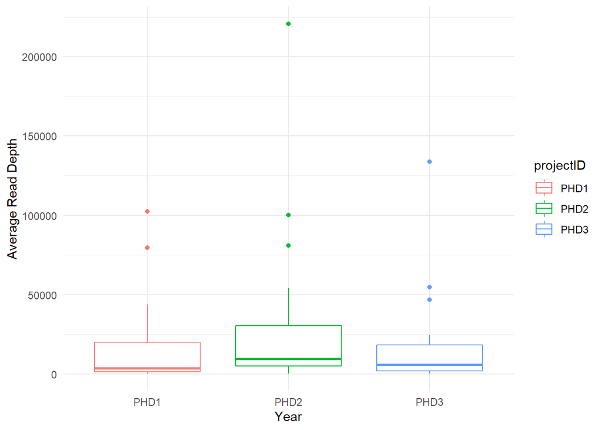

```r
# Compute read depth (total reads per sample)
read_depth_reps <- sample_sums(phylo_replicates)  # Sum of reads per sample

# Extract sample metadata
metadata_reps <- sample_data(phylo_replicates) %>% as.data.frame()

# Ensure "projectID" is numeric (assuming it represents the year)
metadata_reps$projectID <- as.factor(metadata_reps$projectID)
metadata_reps$fieldID <- as.factor(metadata_reps$fieldID)

# Merge read depth into metadata
metadata_reps$ReadDepth <- read_depth_reps

# Plot the average read depth over time
ggplot(metadata_reps, aes(x = projectID, y = ReadDepth, colour = projectID)) +
  geom_boxplot()+
  labs(x = "Year",
       y = "Average Read Depth") +
  theme_minimal()
```

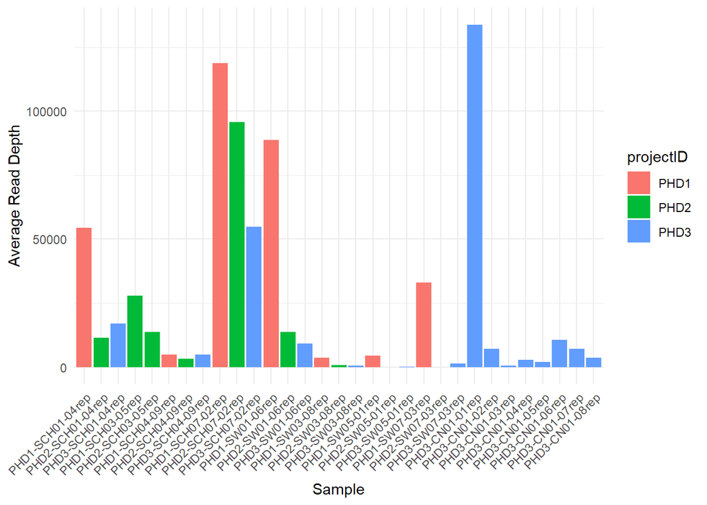

```r
#depth sample label order
depth_label_order <- c(
  "PHD1-SCH01-04rep",
  "PHD2-SCH01-04rep",
  "PHD3-SCH01-04rep",
  "PHD1-SCH03-05rep",
  "PHD2-SCH03-05rep",
  "PHD1-SCH04-09rep",
  "PHD2-SCH04-09rep",
  "PHD3-SCH04-09rep",
  "PHD1-SCH07-02rep",
  "PHD2-SCH07-02rep",
  "PHD3-SCH07-02rep",
  "PHD1-SW01-06rep",
  "PHD2-SW01-06rep",
  "PHD3-SW01-06rep",
  "PHD1-SW03-08rep",
  "PHD2-SW03-08rep",
  "PHD3-SW03-08rep",
  "PHD1-SW05-01rep",
  "PHD2-SW05-01rep",
  "PHD3-SW05-01rep",
  "PHD1-SW07-03rep",
  "PHD2-SW07-03rep",
  "PHD3-SW07-03rep",
  "PHD3-CN01-01rep",
  "PHD3-CN01-02rep",
  "PHD3-CN01-03rep",
  "PHD3-CN01-04rep",
  "PHD3-CN01-05rep",
  "PHD3-CN01-06rep",
  "PHD3-CN01-07rep",
  "PHD3-CN01-08rep"
)

# Plot the average read depth over time
ggplot(metadata_reps, aes(x = fieldID, y = ReadDepth, fill = projectID)) +
  geom_bar(stat = "identity") +
  labs(x = "Sample",
       y = "Average Read Depth") +
  theme_minimal()  +
  theme(axis.text.x = element_text(angle = 45, hjust = 1)) + # Slant x-axis labels at 45 degrees
  scale_x_discrete(limits = c(depth_label_order))
```

Comparison taxa plot for run 1 vs run 2.

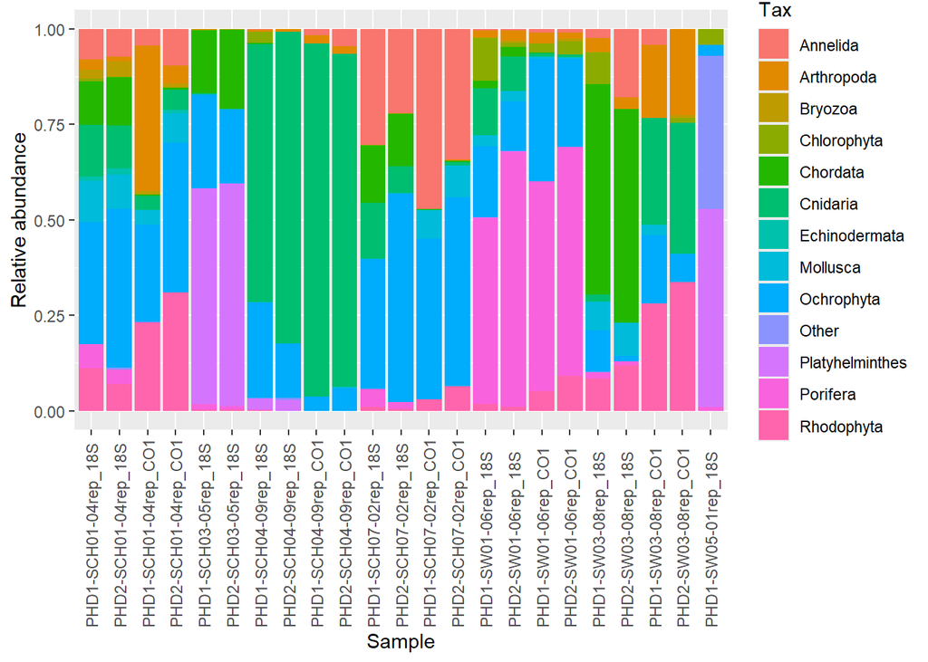

```r
run_replicates_taxa_plot_1v2 <- microbiome::plot_composition(phylum_pseq) +
  xlab("Sample") + ylab("Relative abundance")+
  scale_x_discrete(limits = c(sample_order_run1v2))

run_replicates_taxa_plot_1v2
```

```r
ggsave(filename = "Figures/run_replicates_taxa_plot_1v2_curated_98.png", plot = run_replicates_taxa_plot_1v2,
       device = "png", dpi = 300, units = "mm", height = 200, width = 350)
```

Dissimilarity for run 1 vs run 2.

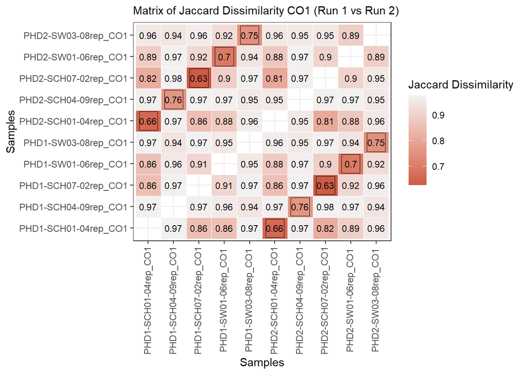

```r
#Jaccard dissimilarity (based on P/A) - high value = most different
replicates_run1v2_phylo <- phylo_eDNA_decontam_filtered %>%
  subset_samples(fullID %in% sample_order_run1v2) # subset phylo

run_replicates_dis_jaccard_1v2 <- as.matrix(distance(replicates_run1v2_phylo, "jaccard", binary = TRUE)) # run analyses

# format matrix to long
longData<-melt(run_replicates_dis_jaccard_1v2)
longData<-longData[longData$value!=0,]

# Add TRUE or FALSE variable for replicates
longData$replicate <- ifelse(sapply(longData$Var1, extract_middle_all) == sapply(longData$Var2, extract_middle_all), TRUE, FALSE)

# Extract the last section of the sample names
longData$primerVar1 <- sub(".*_(18S|CO1)$", "\\1", longData$Var1)
longData$primerVar2 <- sub(".*_(18S|CO1)$", "\\1", longData$Var2)
longData_sameprimer <- filter(longData, primerVar1 == primerVar2)

#Individual primer datasets
longData18S <- subset(longData_sameprimer, primerVar1 == "18S")
longDataCO1 <- subset(longData_sameprimer, primerVar1 == "CO1")

#plot matrix (CO1)
dis_CO1_matrix_run1v2 <- ggplot(longDataCO1, aes(x = Var2, y = Var1)) +
  geom_tile(aes(fill = value), color = "white") +
  geom_point(data = subset(longDataCO1, replicate == TRUE),
             aes(x = Var2, y = Var1),
             color = "black", size = 8, shape = 0, fill = NA) +
  geom_text(aes(label = round(value, 2)), color = "black", size = 3) + # Add text labels
  scale_fill_gradient(low = "coral3", high = "grey95", name = "Jaccard Dissimilarity") +
  labs(x = "Samples", y = "Samples", title = "Matrix of Jaccard Dissimilarity CO1 (Run 1 vs Run 2)") +
  theme_bw() +
  theme(axis.text.x = element_text(size = 9, angle = 90, vjust = 0.3),
        axis.text.y = element_text(size = 9),
        plot.title = element_text(size = 11))

dis_CO1_matrix_run1v2
```

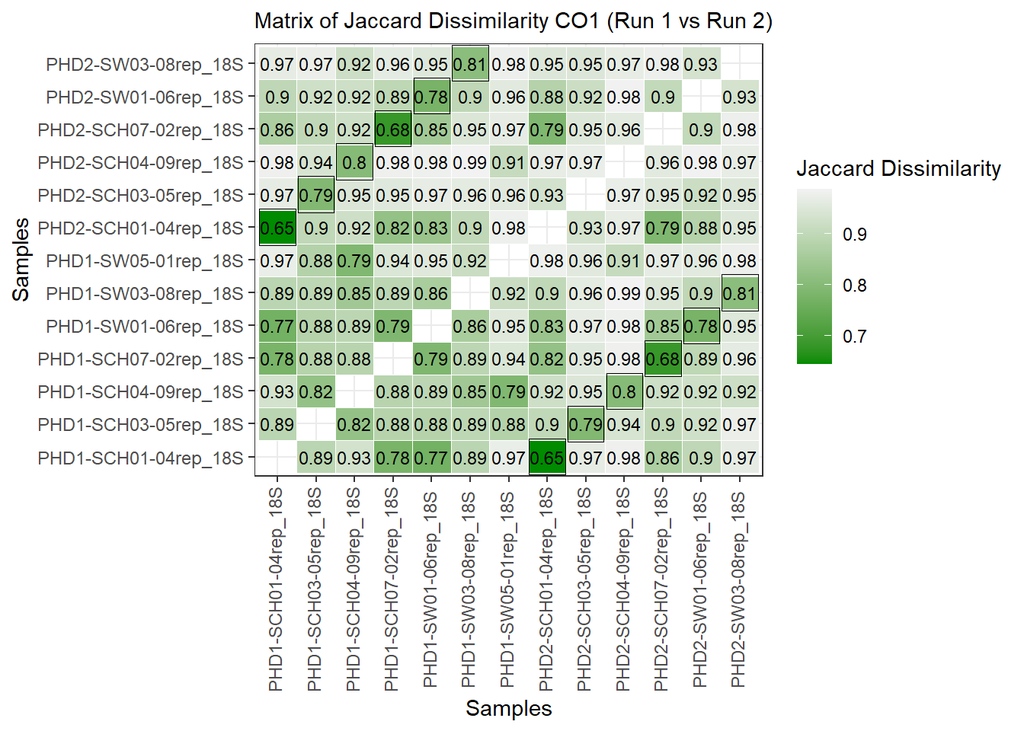

```r
ggsave(filename = "Figures/dis_CO1_matrix_run1v2_curated_98.png", plot = dis_CO1_matrix_run1v2 ,
       device = "png", dpi = 300, units = "mm", height = 200, width = 250)

#plot matrix (18S)
dis_18S_matrix_run1v2 <- ggplot(longData18S, aes(x = Var2, y = Var1)) +
  geom_tile(aes(fill = value), color = "white") +
  geom_point(data = subset(longData18S, replicate == TRUE),
             aes(x = Var2, y = Var1),
             color = "black", size = 8, shape = 0, fill = NA) +
  geom_text(aes(label = round(value, 2)), color = "black", size = 3) + # Add text labels
  scale_fill_gradient(low = "green4", high = "grey95", name = "Jaccard Dissimilarity") +
  labs(x = "Samples", y = "Samples", title = "Matrix of Jaccard Dissimilarity CO1 (Run 1 vs Run 2)") +
  theme_bw() +
  theme(axis.text.x = element_text(size = 9, angle = 90, vjust = 0.3),
        axis.text.y = element_text(size = 9),
        plot.title = element_text(size = 11))

dis_18S_matrix_run1v2
```

```r
ggsave(filename = "Figures/dis_18S_matrix_run1vs_curated_98.png", plot = dis_18S_matrix_run1v2 ,
       device = "png", dpi = 300, units = "mm", height = 200, width = 250)
```

Same again for run 1 vs run 3.

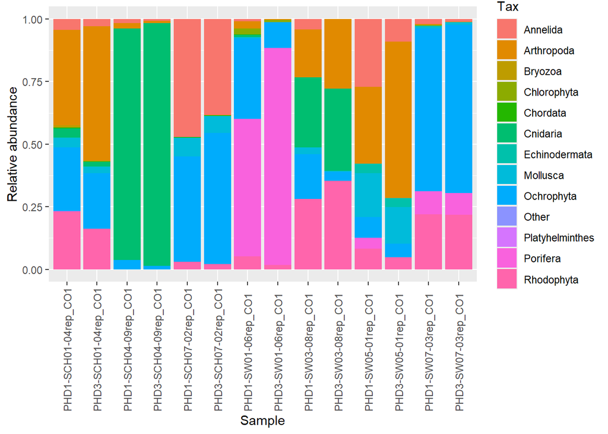

```r
# Comparison taxa plot
run_replicates_taxa_plot_1v3 <- microbiome::plot_composition(phylum_pseq) +
  xlab("Sample") + ylab("Relative abundance")+
  scale_x_discrete(limits = c(sample_order_run1v3))

run_replicates_taxa_plot_1v3
```

```r
ggsave(filename = "Figures/run_replicates_taxa_plot_1v3_curated_98.png", plot = run_replicates_taxa_plot_1v3,
       device = "png", dpi = 300, units = "mm", height = 200, width = 350)
```